Cargar variables.

ELECTRICIDAD

```r
library(rio)
elec="https://github.com/adrianoshimante1998/Trabajo-grupal/raw/master/API_EG.ELC.ACCS.ZS_DS2_en_excel_v2_422316.xls"
electricidad=import(elec)
electricidad[,]=lapply(electricidad[,], trimws,whitespace = "[\\h\\v]") # no blanks
electricidad=na.omit(electricidad)
names(electricidad)=gsub(" ","",names(electricidad))
electricidad$Electricity2017=as.numeric(electricidad$Electricity2017) #UNO SOLO
electricidad=na.omit(electricidad)
```

EMPLEO

```r
EMPLEO="https://github.com/claudia1006/PROYECTO/raw/master/%25employment.xls"
empleo=import(EMPLEO)
empleo[,]=lapply(empleo[,], trimws,whitespace = "[\\h\\v]") # no blanks
names(empleo)=gsub(" ","",names(empleo))
empleo$`%Empleo2017`=as.numeric(empleo$`%Empleo2017`) #UNO SOLO
empleo=na.omit(empleo)
```

COBERTURA DE SALUD

```r
SA="https://github.com/claudia1006/PROYECTO/raw/master/%25%20de%20cobertura%20de%20salud..xlsx"
salud=import(SA)
salud[,]=lapply(salud[,], trimws,whitespace = "[\\h\\v]") # no blanks
names(salud)=gsub(" ","",names(salud))
salud$`%decoberturadesalud2017`=as.numeric(salud$`%decoberturadesalud2017`) #UNO SOLO
salud=na.omit(salud)
names(salud)[1]="CountryName"
```

EXPORTACIONES DE BIENES Y SERVICIOS

```r
EX="https://github.com/claudia1006/PROYECTO/raw/master/Exportaciones%20de%20bienes%20y%20servicios%20(%25%20del%20GDP).xls"
expo=import(EX)
expo[,]=lapply(expo[,], trimws,whitespace = "[\\h\\v]") # no blanks
names(expo)=gsub(" ","",names(expo))
expo$`Expobienesyservicio%delGDP2017`=as.numeric(expo$`Expobienesyservicio%delGDP2017`) #UNO SOLO
expo=na.omit(expo)
```

% DE POBLACION QUE USA INTERNET

```r
linkinter="https://github.com/Alfredo-Espinoza/Estadistica-2-Parte-individual-del-trabajo-grupal/raw/master/API_IT.NET.USER.ZS_DS2_en_excel_v2_199844.xlsx"
internet=import(linkinter)
```

```
## * `` -> ...3
## * `` -> ...4
## * `` -> ...5
## * `` -> ...6
## * `` -> ...7
## * … and 56 more problems
```

```r
#Borrando las columnas de otros años
internet[2:50]=NULL
internet[2:12]=NULL
internet[3:13]=NULL

#Eliminando los NA
internet=internet[complete.cases(internet),]
#Cambiando nombres de variables.
names(internet)[1]="CountryName"
names(internet)[2]="Porcentaje de la población que usa internet (2017)"

#Eliminando posibles espacios vacios
internet$CountryName=trimws(internet$CountryName,whitespace = "[\\h\\v]")
internet$`Porcentaje de la población que usa internet (2017)`=trimws(internet$`Porcentaje de la población que usa internet (2017)`,whitespace = "[\\h\\v]")

#Eliminando primera fila.

internet=internet[-1,]

#Hay observaciones que corresponden a la suciedad de la data. Varias de ellas serán eliminadas una vez se realiza el merge de acuerdo a "Pais" con las variables del grupo de trabajo. El resto tendrán que ser eliminadas manualmente.

#Pasando la variable a numérico

internet$`Porcentaje de la población que usa internet (2017)`=as.numeric(internet$`Porcentaje de la población que usa internet (2017)`)
names(internet)=gsub(" ","",names(internet))
```

EXPECTATIVA DE VIDA AL NACER

```r
linkvida="https://github.com/Alfredo-Espinoza/Estadistica-2-Parte-individual-del-trabajo-grupal/raw/master/API_SP.DYN.LE00.IN_DS2_en_excel_v2_199538.xlsx"


basevida=import(linkvida)
```

```
## * `` -> ...3
## * `` -> ...4
## * `` -> ...5
## * `` -> ...6
## * `` -> ...7
## * … and 56 more problems
```

```r
#Borrando columnas innecesarias
basevida[2:50]=NULL
basevida[2:12]=NULL
basevida[3:13]=NULL

#Borramos los NAs

basevida=basevida[complete.cases(basevida),]

#Cambiando nombres de variable

names(basevida)[1]="CountryName"
names(basevida)[2]="Expectativa de vida en años al nacer (2017)"

#Eliminamos la primera fila, porque es producto de la suciedad de losd atos.
basevida=basevida[-c(1),]

#Eliminando posibles espacios vacios

basevida$CountryName=trimws(basevida$CountryName,whitespace = "[\\h\\v]")
basevida$`Expectativa de vida en años al nacer (2017)`=trimws(basevida$`Expectativa de vida en años al nacer (2017)`,whitespace = "[\\h\\v]")

#Pasando a numérico la variable a estudiar

basevida$"Expectativa de vida en años al nacer (2017)"=as.numeric(basevida$"Expectativa de vida en años al nacer (2017)")
names(basevida)=gsub(" ","",names(basevida))
```

GDP PER CAPITA EN DÓLARES

```r
GDPP="https://github.com/claudia1006/PROYECTO/raw/master/GDP%20PER%20CAPITA%20CURRENT%20%24.xlsx"
GDP=import(GDPP)
GDP[,]=lapply(GDP[,], trimws,whitespace = "[\\h\\v]") # no blanks
names(GDP)[2]="GDP PER CAPITA EN $"
GDP$`GDP PER CAPITA EN $`=as.numeric(GDP$`GDP PER CAPITA EN $`) #UNO SOLO
GDP=na.omit(GDP)
names(GDP)=gsub(" ","",names(GDP))
GDP=na.omit(GDP)
```

ACCESO BASICO AL AGUA

```r
AGUA="https://github.com/claudia1006/PROYECTO/raw/master/ACCESO.xls"
agua=import(AGUA)
```

```
## * `` -> ...3
```

```r
agua[,]=lapply(agua[,], trimws,whitespace = "[\\h\\v]") # no blanks
names(agua)=gsub(" ","",names(agua))
agua$`Accesoalagua(en%)2017`=as.numeric(agua$`Accesoalagua(en%)2017`) #UNO SOLO
agua$...3=NULL
agua=na.omit(agua)
```

CRECIMIENTO DEL PBI

```r
CRE="https://github.com/Alfredo-Espinoza/Estadistica-2-Parte-individual-del-trabajo-grupal/raw/master/crecimiento%20bm.xlsx"
crepbi=import(CRE)
crepbi[,]=lapply(crepbi[,], trimws,whitespace = "[\\h\\v]") # no blanks
names(crepbi)=gsub(" ","",names(crepbi))
```

```r
crepbi$`2017`=as.numeric(crepbi$`2017`)
```

```r
crepbi$CountryCode=NULL
```

```r
names(crepbi)[2]="CrecimientoPBI2017"
```

CALIDAD DE CARRETERAS

```r
CARRE="https://github.com/claudia1006/PROYECTO/raw/master/calidad%20de%20carreteras.xlsx"
ccarre=import(CARRE)
ccarre[,]=lapply(ccarre[,], trimws,whitespace = "[\\h\\v]") # no blanks
ccarre$`Road quality`=as.numeric(ccarre$`Road quality`) #UNO SOLO'
names(ccarre)=gsub(" ","",names(ccarre))
```

```r
#eliminando numero adelante
library(stringr)
splitted= str_split(ccarre$Country,
                    pattern = '\\s',
                    simplify = T)[,-1]
```

```r
#uniendo los nombres
ccarre$Country=trimws(paste(splitted[,1],splitted[,2],splitted[,3]),whitespace = "[\\h\\v]")
names(ccarre)[1]="CountryName"
```

```r
summary(agua)
```

```
##  CountryName        Accesoalagua(en%)2017
##  Length:260         Min.   : 38.70
##  Class :character   1st Qu.: 82.42
##  Mode  :character   Median : 95.48
##                     Mean   : 88.28
##                     3rd Qu.: 99.49
##                     Max.   :100.00
```

```r
summary(basevida)
```

```
##  CountryName        Expectativadevidaenañosalnacer(2017)
##  Length:245         Min.   :52.24
##  Class :character   1st Qu.:67.38
##  Mode  :character   Median :73.55
##                     Mean   :72.32
##                     3rd Qu.:77.63
##                     Max.   :84.68
```

```r
summary(ccarre)
```

```
##  CountryName         Roadquality
##  Length:141         Min.   :1.900
##  Class :character   1st Qu.:3.300
##  Mode  :character   Median :4.000
##                     Mean   :4.065
##                     3rd Qu.:4.900
##                     Max.   :6.500
```

```r
summary(crepbi)
```

```
##  CountryName        CrecimientoPBI2017
##  Length:264         Min.   :-9.530
##  Class :character   1st Qu.: 1.747
##  Mode  :character   Median : 3.177
##                     Mean   : 3.316
##                     3rd Qu.: 4.708
##                     Max.   :26.676
##                     NA's   :18
```

```r
summary(electricidad)
```

```
##  CountryName        Electricity2017
##  Length:261         Min.   :  9.30
##  Class :character   1st Qu.: 79.96
##  Mode  :character   Median : 99.99
##                     Mean   : 85.33
##                     3rd Qu.:100.00
##                     Max.   :100.00
```

```r
summary(empleo)
```

```
##  CountryName         %Empleo2017
##  Length:233         Min.   : 0.060
##  Class :character   1st Qu.: 1.783
##  Mode  :character   Median : 2.987
##                     Mean   : 3.221
##                     3rd Qu.: 4.311
##                     Max.   :13.164
```

```r
summary(expo)
```

```
##  CountryName        Expobienesyservicio%delGDP2017
##  Length:222         Min.   :  5.905
##  Class :character   1st Qu.: 23.223
##  Mode  :character   Median : 33.022
##                     Mean   : 39.987
##                     3rd Qu.: 47.883
##                     Max.   :223.079
```

```r
summary(GDP)
```

```
##  CountryName        GDPPERCAPITAEN$
##  Length:200         Min.   :   293
##  Class :character   1st Qu.:  2064
##  Mode  :character   Median :  6063
##                     Mean   : 15387
##                     3rd Qu.: 19160
##                     Max.   :166726
```

```r
summary(internet)
```

```
##  CountryName        Porcentajedelapoblaciónqueusainternet(2017)
##  Length:253         Min.   :  1.309
##  Class :character   1st Qu.: 30.099
##  Mode  :character   Median : 57.272
##                     Mean   : 54.181
##                     3rd Qu.: 77.615
##                     Max.   :100.000
```

```r
summary(salud)
```

```
##  CountryName        %decoberturadesalud2017
##  Length:183         Min.   :25.00
##  Class :character   1st Qu.:49.00
##  Mode  :character   Median :69.00
##                     Mean   :64.04
##                     3rd Qu.:76.00
##                     Max.   :89.00
```

DEMOCRACIA

```r
library(rio)
library(htmltab)
index="https://github.com/claudia1006/PROYECTO/raw/master/Democracy.xlsx"
de=import(index, which=2)
```

```
## * `` -> ...2
```

```r
#sacando nombres raros
library(stringr)
names(de)=str_replace_all(names(de), "[^[:ascii:]]", "")
```

```r
#sacando valores raros
de[,]=lapply(de[,], str_replace_all,"[^[:ascii:]]","")
```

```r
#Reemplazar espacios en blanco por nada
names(de)=gsub(" ","",names(de))
names(de)
```

```
## [1] "DemocracyIndex2017" "...2"
```

```r
#no blanks
de[,]=lapply(de[,], trimws,whitespace = "[\\h\\v]")
str(de)
```

```
## 'data.frame':    175 obs. of  2 variables:
##  $ DemocracyIndex2017: chr  NA "Norway" "Iceland" "Sweden" ...
##  $ ...2              : chr  "Rank" "Full democracies" "Full democracies" "Full democracies" ...
```

```r
de=na.omit(de)
```

```r
names(de)[2]="Regime type"
names(de)[1]="CountryName"
```

```r
row.names(de)=de$Country
```

```r
library(dplyr)
de$`Regime type`=recode(de$`Regime type`,
       'Full democracies'='1',
       'Flawed democracy'='1',
       'Hybrid regime'='0',
       'Authoritarian'='0')
de$`Regime type`=as.ordered(de$`Regime type`)
```

ALFABETIZACION

```r
library(htmltab)
literacy2=htmltab(doc="https://www.worldatlas.com/articles/the-highest-literacy-rates-in-the-world.html", which='//*[@id="artReg-table"]/table')
```

```r
literacy2$Rank=NULL
```

```r
names(literacy2)=c("Country", "Literacy Rate")
```

```r
literacy2$Country=trimws(literacy2$Country,whitespace = "[\\h\\v]")
```

```r
literacy2$`Literacy Rate`[literacy2$`Literacy Rate`=="NA"]<-NA
```

```r
literacy2=na.omit(literacy2)
```

```r
library(stringr)
literacy2$`Literacy Rate`=gsub('%',"",literacy2$`Literacy Rate`)
```

```r
literacy2[-1]=lapply(literacy2[-1], as.numeric)
```

```r
literacy2=na.omit(literacy2)
```

```r
str(literacy2)
```

```
## 'data.frame':    194 obs. of  2 variables:
##  $ Country      : chr  "Andorra" "Finland" "Holy See" "Liechtenstein" ...
##  $ Literacy Rate: num  100 100 100 100 100 100 100 100 100 100 ...
##  - attr(*, "na.action")= 'omit' Named int  195 196 197
##   ..- attr(*, "names")= chr  "196" "197" "198"
```

```r
names(literacy2)=c("CountryName","LitRate")
```

SCHOOLING

```r
lkXLSX="https://github.com/Geanze/TRABAJO-GRUPAL-ESTAD2/raw/master/education-index.xlsx"
Schooling=import(lkXLSX)
```

```r
str(Schooling)
```

```
## 'data.frame':    195 obs. of  16 variables:
##  $ HDI Rank: num  169 95 93 37 149 61 49 87 2 21 ...
##  $ Country : chr  "Afghanistan" "Albania" "Algeria" "Andorra" ...
##  $ 1980    : chr  "7.6100000000000001E-2" "0.5405888888888889" "0.32137777777777782" ".." ...
##  $ 1985    : chr  "0.10308333333333333" "0.52777667723681287" "0.34717777777777781" ".." ...
##  $ 1990    : chr  "0.12138888888888891" "0.537186687806959" "0.38238888888888889" ".." ...
##  $ 1995    : chr  "0.17528888888888888" "0.52869385821602155" "0.42436666666666667" ".." ...
##  $ 2000    : chr  "0.22552222222222224" "0.56546505080021836" "0.49348888888888887" ".." ...
##  $ 2005    : chr  "0.2974" "0.59467023003005681" "0.56256666666666666" ".." ...
##  $ 2006    : chr  "0.30898666666666663" "0.59632305428653098" "0.57023777777777773" ".." ...
##  $ 2007    : chr  "0.32057333333333332" "0.59797587854300516" "0.58068666666666668" ".." ...
##  $ 2008    : chr  "0.33216000000000001" "0.59962870279947933" "0.59807999999999995" ".." ...
##  $ 2009    : chr  "0.34374666666666664" "0.60065172312408377" "0.61547333333333332" ".." ...
##  $ 2010    : chr  "0.35699999999999998" "0.60167474344868821" "0.6314777777777778" "0.6702866666666667" ...
##  $ 2011    : chr  "0.36533333333333334" "0.60851936340332036" "0.64258888888888888" "0.6702866666666667" ...
##  $ 2012    : chr  "0.36533333333333334" "0.60851936340332036" "0.64258888888888888" "0.6702866666666667" ...
##  $ 2013    : chr  "0.36533333333333334" "0.60851936340332036" "0.64258888888888888" "0.6702866666666667" ...
```

```r
Schooling$`HDI Rank`=NULL
Schooling$`1980`=NULL
Schooling$`1985`=NULL
Schooling$`1990`=NULL
Schooling$`1995`=NULL
Schooling$`2000`=NULL
Schooling$`2005`=NULL
Schooling$`2006`=NULL
Schooling$`2007`=NULL
Schooling$`2008`=NULL
Schooling$`2009`=NULL
Schooling$`2010`=NULL
Schooling$`2011`=NULL
Schooling$`2012`=NULL
```

```r
names(Schooling)=c("CountryName", "SchoRate")
```

```r
Schooling[c(2)]= lapply(Schooling[c(2)], as.numeric)
Schooling[complete.cases(Schooling),]
```

```
##                                   CountryName  SchoRate
## 1                                 Afghanistan 0.3653333
## 2                                     Albania 0.6085194
## 3                                     Algeria 0.6425889
## 4                                     Andorra 0.6702867
## 5                                      Angola 0.4742121
## 6                         Antigua and Barbuda 0.6811413
## 7                                   Argentina 0.7833556
## 8                                     Armenia 0.7013667
## 9                                   Australia 0.9265355
## 10                                    Austria 0.7944810
## 11                                 Azerbaijan 0.6997778
## 12                                    Bahamas 0.7139547
## 13                                    Bahrain 0.7139667
## 14                                 Bangladesh 0.4468804
```

[output cut: 173 more lines]

```r
Schooling=na.omit(Schooling)
```

INVERSION EN EDUCACION

```r
library(rio)
InvestEdu2=import("https://github.com/Geanze/TRABAJO-GRUPAL-ESTAD2/raw/master/InvestPBIEducation.xls")
InvestEdu2$`Año de data`=NULL
InvestEdu2$`Country Code`=NULL
names(InvestEdu2)=c("CountryName", "ExpendEdu")
```

```r
InvestEdu2=na.omit(InvestEdu2)
```

URBANIZACION

```r
lkXLS="https://github.com/Geanze/TRABAJO-GRUPAL-ESTAD2/raw/master/WUP2018-F01-Total_Urban_Rural.xls"
urban=import(lkXLS)
```

```r
str(urban)
```

```
## 'data.frame':    233 obs. of  5 variables:
##  $ Country         : chr  "Afghanistan" "Albania" "Algeria" "American Samoa" ...
##  $ Urban           : num  9273.3 1770 30510 48.5 67.8 ...
##  $ Rural           : num  27099.87 1164.39 11498.04 7.15 9.19 ...
##  $ Total           : num  36373.2 2934.4 42008.1 55.7 77 ...
##  $ Percentage urban: num  25.5 60.3 72.6 87.2 88.1 ...
```

```r
urban$Urban=NULL
urban$Rural=NULL
urban$Total=NULL
```

```r
names(urban)=c("CountryName", "UrbRate")
```

```r
urban[complete.cases(urban),]
```

```
##                            CountryName    UrbRate
## 1                          Afghanistan  25.494892
## 2                              Albania  60.318884
## 3                              Algeria  72.628968
## 4                       American Samoa  87.153146
## 5                              Andorra  88.061544
## 6                               Angola  65.514407
## 7                             Anguilla 100.000000
## 8                  Antigua and Barbuda  24.599709
## 9                            Argentina  91.870465
## 10                             Armenia  63.148637
## 11                               Aruba  43.410618
## 12                           Australia  86.011737
## 13                             Austria  58.297268
## 14                          Azerbaijan  55.680108
```

[output cut: 219 more lines]

```r
urban[c(1)]=lapply(urban[c(1)], trimws,whitespace = "[\\h\\v]")
```

Porcentaje de número de estudiantes por profesor en cada país (invertida)

```r
library(rio)
studTeach=import("https://github.com/Geanze/TRABAJO-GRUPAL-ESTAD2/raw/master/StudTeachRatio.xls")
```

```r
studTeach$`Año de data`=NULL
studTeach$`Country Code`=NULL
```

```r
names(studTeach)=c("CountryName", "StuTeachRat")
```

```r
complete.cases(studTeach)
```

[output not shown]

```r
studTeach=na.omit(studTeach)
```

```r
studTeach$StuTeachRat=100-studTeach$StuTeachRat
```

```r
studTeach[2]==lapply(studTeach[2], as.numeric)
```

```
##     StuTeachRat
## 1          TRUE
## 2          TRUE
## 3          TRUE
## 4          TRUE
## 5          TRUE
## 6          TRUE
## 7          TRUE
## 8          TRUE
## 9          TRUE
## 11         TRUE
## 13         TRUE
## 14         TRUE
## 15         TRUE
## 16         TRUE
```

[output cut: 217 more lines]

```r
complete.cases(studTeach)
```

[output not shown]

```r
str(studTeach)
```

```
## 'data.frame':    231 obs. of  2 variables:
##  $ CountryName: chr  "Aruba" "Afghanistan" "Angola" "Albania" ...
##  $ StuTeachRat: num  85.2 56 50 82.4 89.5 ...
##  - attr(*, "na.action")= 'omit' Named int  10 12 34 37 50 53 77 79 90 92 ...
##   ..- attr(*, "names")= chr  "10" "12" "34" "37" ...
```

Merge de las variables. Se modificará el nombre de los países para maximizar las combinaciones.

```r
elecem=merge(electricidad,empleo,all.x=T, all.y=T)
```

```r
elecem[!complete.cases(elecem),]
```

```
##                   CountryName Electricity2017 %Empleo2017
## 4                     Andorra       100.00000          NA
## 6         Antigua and Barbuda       100.00000          NA
## 10                      Aruba       100.00000          NA
## 22                    Bermuda       100.00000          NA
## 28     British Virgin Islands       100.00000          NA
## 38             Cayman Islands       100.00000          NA
## 42            Channel Islands              NA       4.555
## 53                    Curacao       100.00000          NA
## 58                   Dominica       100.00000          NA
## 77              Faroe Islands       100.00000          NA
## 88                  Gibraltar       100.00000          NA
## 90                  Greenland       100.00000          NA
## 91                    Grenada        94.69567          NA
## 114               Isle of Man       100.00000          NA
```

[output cut: 16 more lines]

```r
library(knitr)
library(kableExtra)
kable(elecem[!complete.cases(elecem),],type='html')%>%
    kable_styling(bootstrap_options = c("striped", "hover", "condensed", "responsive"),
                  font_size = 10)
```

|  | CountryName | Electricity2017 | %Empleo2017 |
| --- | --- | --- | --- |
| 4 | Andorra | 100.00000 | NA |
| 6 | Antigua and Barbuda | 100.00000 | NA |
| 10 | Aruba | 100.00000 | NA |
| 22 | Bermuda | 100.00000 | NA |
| 28 | British Virgin Islands | 100.00000 | NA |
| 38 | Cayman Islands | 100.00000 | NA |
| 42 | Channel Islands | NA | 4.555 |
| 53 | Curacao | 100.00000 | NA |
| 58 | Dominica | 100.00000 | NA |
| 77 | Faroe Islands | 100.00000 | NA |
| 88 | Gibraltar | 100.00000 | NA |
| 90 | Greenland | 100.00000 | NA |
| 91 | Grenada | 94.69567 | NA |
| 114 | Isle of Man | 100.00000 | NA |
| 122 | Kiribati | 98.61457 | NA |
| 125 | Kosovo | 100.00000 | NA |
| 139 | Liechtenstein | 100.00000 | NA |
| 152 | Marshall Islands | 94.75500 | NA |
| 156 | Micronesia, Fed. Sts. | 80.75668 | NA |
| 162 | Monaco | 100.00000 | NA |
| 169 | Nauru | 99.55317 | NA |
| 179 | Northern Mariana Islands | 100.00000 | NA |
| 186 | Palau | 100.00000 | NA |
| 202 | San Marino | 100.00000 | NA |
| 207 | Seychelles | 100.00000 | NA |
| 210 | Sint Maarten (Dutch part) | 100.00000 | NA |
| 222 | St. Kitts and Nevis | 100.00000 | NA |
| 224 | St. Martin (French part) | 100.00000 | NA |
| 244 | Turks and Caicos Islands | 100.00000 | NA |
| 245 | Tuvalu | 100.00000 | NA |

```r
elecem=na.omit(elecem)
```

Se pierden países por falta de datos

```r
elexpo=merge(elecem,expo,all.x=T, all.y=T)
```

```r
kable(elexpo[!complete.cases(elexpo),],type='html')%>%
    kable_styling(bootstrap_options = c("striped", "hover", "condensed", "responsive"),
                  font_size = 10)
```

|  | CountryName | Electricity2017 | %Empleo2017 | Expobienesyservicio%delGDP2017 |
| --- | --- | --- | --- | --- |
| 4 | American Samoa | NA | NA | 57.41325 |
| 9 | Aruba | NA | NA | 70.81092 |
| 29 | Burundi | 9.30000 | 0.074000 | NA |
| 34 | Caribbean small states | 98.38373 | 4.058393 | NA |
| 52 | Dominica | NA | NA | 45.40892 |
| 62 | Eritrea | 48.42379 | 1.109000 | NA |
| 71 | Fiji | 96.00000 | 1.194000 | NA |
| 75 | French Polynesia | 100.00000 | 3.771000 | NA |
| 82 | Greenland | NA | NA | 40.18639 |
| 112 | Kiribati | NA | NA | 13.21577 |
| 113 | Korea, Dem. People’s Rep. | 43.87118 | 1.100000 | NA |
| 115 | Kosovo | NA | NA | 26.64993 |
| 126 | Lesotho | 33.73076 | 0.686000 | NA |
| 141 | Marshall Islands | NA | NA | 31.49284 |
| 158 | New Caledonia | 100.00000 | 4.179000 | NA |
| 165 | Northern Mariana Islands | NA | NA | 73.44633 |
| 170 | Pacific island small states | 82.99781 | 1.422113 | NA |
| 172 | Palau | NA | NA | 48.84504 |
| 174 | Papua New Guinea | 54.42745 | 1.715000 | NA |
| 188 | Sao Tome and Principe | 72.51070 | 1.628000 | NA |
| 192 | Seychelles | NA | NA | 89.89256 |
| 198 | Solomon Islands | 62.89564 | 1.270000 | NA |
| 203 | South Sudan | 25.38207 | 2.821000 | NA |
| 206 | St. Lucia | 98.75979 | 5.847000 | NA |
| 212 | Suriname | 96.78314 | 1.930000 | NA |
| 215 | Syrian Arab Republic | 89.63879 | 4.605000 | NA |
| 222 | Trinidad and Tobago | 100.00000 | 5.358000 | NA |
| 234 | Vanuatu | 62.78429 | 1.491000 | NA |
| 235 | Venezuela, RB | 100.00000 | 3.490000 | NA |
| 240 | Yemen, Rep. | 79.20000 | 7.164000 | NA |

```r
elexpo=na.omit(elexpo)
```

Con internet

```r
elein=merge(elexpo,internet,all.x=T, all.y=T)
```

```r
kable(elein[!complete.cases(elein),],type='html')%>%
    kable_styling(bootstrap_options = c("striped", "hover", "condensed", "responsive"),
                  font_size = 10)
```

|  | CountryName | Electricity2017 | %Empleo2017 | Expobienesyservicio%delGDP2017 | Porcentajedelapoblaciónqueusainternet(2017) |
| --- | --- | --- | --- | --- | --- |
| 4 | Andorra | NA | NA | NA | 91.567467 |
| 6 | Antigua and Barbuda | NA | NA | NA | 76.000000 |
| 10 | Aruba | NA | NA | NA | 97.170000 |
| 22 | Bermuda | NA | NA | NA | 98.370000 |
| 28 | British Virgin Islands | NA | NA | NA | 77.704268 |
| 32 | Burundi | NA | NA | NA | 2.660748 |
| 37 | Caribbean small states | NA | NA | NA | 59.176351 |
| 38 | Cayman Islands | NA | NA | NA | 81.067693 |
| 52 | Curacao | NA | NA | NA | 68.127216 |
| 57 | Dominica | NA | NA | NA | 69.619669 |
| 67 | Eritrea | NA | NA | NA | 1.308907 |
| 76 | Faroe Islands | NA | NA | NA | 97.581959 |
| 77 | Fiji | NA | NA | NA | 49.966373 |
| 81 | French Polynesia | NA | NA | NA | 72.703895 |
| 88 | Greenland | NA | NA | NA | 69.482462 |
| 89 | Grenada | NA | NA | NA | 59.071735 |
| 119 | Kiribati | NA | NA | NA | 14.581818 |
| 121 | Kosovo | NA | NA | NA | 83.893597 |
| 132 | Lesotho | NA | NA | NA | 29.000000 |
| 135 | Liechtenstein | NA | NA | NA | 98.100000 |
| 148 | Marshall Islands | NA | NA | NA | 38.701163 |
| 152 | Micronesia, Fed. Sts. | NA | NA | NA | 35.304053 |
| 158 | Monaco | NA | NA | NA | 97.052977 |
| 165 | Nauru | NA | NA | NA | 57.000000 |
| 168 | New Caledonia | NA | NA | NA | 82.005841 |
| 179 | Pacific island small states | NA | NA | NA | 32.703963 |
| 182 | Papua New Guinea | NA | NA | NA | 11.209197 |
| 196 | San Marino | NA | NA | NA | 60.182301 |
| 197 | Sao Tome and Principe | NA | NA | NA | 29.931229 |
| 201 | Seychelles | NA | NA | NA | 58.769811 |
| 207 | Solomon Islands | NA | NA | NA | 11.924229 |
| 212 | South Sudan | NA | NA | NA | 7.977429 |
| 215 | St. Kitts and Nevis | NA | NA | NA | 80.710191 |
| 216 | St. Lucia | NA | NA | NA | 50.815245 |
| 222 | Suriname | NA | NA | NA | 48.945174 |
| 225 | Syrian Arab Republic | NA | NA | NA | 34.253402 |
| 232 | Trinidad and Tobago | NA | NA | NA | 77.326053 |
| 236 | Tuvalu | NA | NA | NA | 49.318339 |
| 245 | Vanuatu | NA | NA | NA | 25.719788 |
| 246 | Venezuela, RB | NA | NA | NA | 72.000000 |
| 251 | Yemen, Rep. | NA | NA | NA | 26.718355 |

Se pierden por falta de datos

```r
elein=na.omit(elein)
```

Con basevida

```r
elvida=merge(elein,basevida,all.x=T, all.y=T)
```

```r
kable(elvida[!complete.cases(elvida),],type='html')%>%
    kable_styling(bootstrap_options = c("striped", "hover", "condensed", "responsive"),
                  font_size = 10)
```

|  | CountryName | Electricity2017 | %Empleo2017 | Expobienesyservicio%delGDP2017 | Porcentajedelapoblaciónqueusainternet(2017) | Expectativadevidaenañosalnacer(2017) |
| --- | --- | --- | --- | --- | --- | --- |
| 5 | Antigua and Barbuda | NA | NA | NA | NA | 76.75200 |
| 9 | Aruba | NA | NA | NA | NA | 76.01000 |
| 21 | Bermuda | NA | NA | NA | NA | 81.44195 |
| 30 | Burundi | NA | NA | NA | NA | 60.89800 |
| 35 | Caribbean small states | NA | NA | NA | NA | 73.51749 |
| 39 | Channel Islands | NA | NA | NA | NA | 82.76600 |
| 50 | Curacao | NA | NA | NA | NA | 78.01707 |
| 64 | Eritrea | NA | NA | NA | NA | 65.53800 |
| 73 | Faroe Islands | NA | NA | NA | NA | 82.40000 |
| 74 | Fiji | NA | NA | NA | NA | 67.25200 |
| 78 | French Polynesia | NA | NA | NA | NA | 77.25100 |
| 85 | Grenada | NA | NA | NA | NA | 72.38800 |
| 115 | Kiribati | NA | NA | NA | NA | 67.85100 |
| 116 | Korea, Dem. People’s Rep. | NA | NA | NA | NA | 71.91000 |
| 118 | Kosovo | NA | NA | NA | NA | 71.94634 |
| 129 | Lesotho | NA | NA | NA | NA | 52.94700 |
| 132 | Liechtenstein | NA | NA | NA | NA | 82.25854 |
| 148 | Micronesia, Fed. Sts. | NA | NA | NA | NA | 67.61800 |
| 162 | New Caledonia | NA | NA | NA | NA | 77.14878 |
| 173 | Pacific island small states | NA | NA | NA | NA | 69.77428 |
| 176 | Papua New Guinea | NA | NA | NA | NA | 64.01000 |
| 190 | Sao Tome and Principe | NA | NA | NA | NA | 69.93300 |
| 194 | Seychelles | NA | NA | NA | NA | 74.30000 |
| 200 | Solomon Islands | NA | NA | NA | NA | 72.64500 |
| 205 | South Sudan | NA | NA | NA | NA | 57.36500 |
| 208 | St. Lucia | NA | NA | NA | NA | 75.90700 |
| 209 | St. Martin (French part) | NA | NA | NA | NA | 79.72195 |
| 215 | Suriname | NA | NA | NA | NA | 71.46300 |
| 218 | Syrian Arab Republic | NA | NA | NA | NA | 70.96700 |
| 225 | Trinidad and Tobago | NA | NA | NA | NA | 73.24500 |
| 237 | Vanuatu | NA | NA | NA | NA | 70.17200 |
| 238 | Venezuela, RB | NA | NA | NA | NA | 72.24600 |
| 243 | Yemen, Rep. | NA | NA | NA | NA | 66.08600 |

Falta de datos

```r
elvida=na.omit(elvida)
```

Con GDP

```r
elgdp=merge(elvida,GDP,all.x=T, all.y=T)
```

```r
kable(elgdp[!complete.cases(elgdp),],type='html')%>%
    kable_styling(bootstrap_options = c("striped", "hover", "condensed", "responsive"),
                  font_size = 10)
```

|  | CountryName | Electricity2017 | %Empleo2017 | Expobienesyservicio%delGDP2017 | Porcentajedelapoblaciónqueusainternet(2017) | Expectativadevidaenañosalnacer(2017) | GDPPERCAPITAEN$ |
| --- | --- | --- | --- | --- | --- | --- | --- |
| 4 | American Samoa | NA | NA | NA | NA | NA | 11398.7774 |
| 5 | Andorra | NA | NA | NA | NA | NA | 39134.3934 |
| 7 | Antigua and Barbuda | NA | NA | NA | NA | NA | 15824.6678 |
| 8 | Arab World | 90.27369 | 5.216053 | 44.03269 | 49.26013 | 71.62253 | NA |
| 11 | Aruba | NA | NA | NA | NA | NA | 25630.2665 |
| 31 | Burundi | NA | NA | NA | NA | NA | 293.0091 |
| 36 | Cayman Islands | NA | NA | NA | NA | NA | 56334.2140 |
| 38 | Central Europe and the Baltics | 100.00000 | 3.374417 | 65.47194 | 73.40957 | 77.03397 | NA |
| 50 | Curacao | NA | NA | NA | NA | NA | 19457.5315 |
| 55 | Dominica | NA | NA | NA | NA | NA | 6951.3035 |
| 57 | Early-demographic dividend | 89.68483 | 2.724378 | 25.00761 | 38.02906 | 70.25526 | NA |
| 58 | East Asia & Pacific | 97.82556 | 2.972798 | 29.48904 | 55.07327 | 75.86575 | NA |
| 59 | East Asia & Pacific (excluding high income) | 97.59162 | 3.004389 | 25.35580 | 51.16874 | 74.99495 | NA |
| 60 | East Asia & Pacific (IDA & IBRD countries) | 98.26042 | 3.032485 | 25.35561 | 51.16874 | 75.03336 | NA |
| 68 | Euro area | 100.00000 | 4.709441 | 45.47986 | 79.66087 | 81.95073 | NA |
| 69 | Europe & Central Asia | 99.99321 | 3.348669 | 42.90749 | 75.02782 | 77.74469 | NA |
| 70 | Europe & Central Asia (excluding high income) | 99.98505 | 2.236903 | 30.57530 | 66.58740 | 73.39917 | NA |
| 71 | Europe & Central Asia (IDA & IBRD countries) | 99.98642 | 2.417740 | 34.24815 | 67.37072 | 73.80835 | NA |
| 72 | European Union | 100.00000 | 4.099160 | 44.44559 | 80.82978 | 80.99116 | NA |
| 73 | Fiji | NA | NA | NA | NA | NA | 6006.3606 |
| 75 | Fragile and conflict affected situations | 54.92626 | 2.425539 | 30.33189 | 22.26269 | 63.15110 | NA |
| 83 | Grenada | NA | NA | NA | NA | NA | 10163.6299 |
| 90 | Heavily indebted poor countries (HIPC) | 42.07520 | 2.114199 | 25.21586 | 19.35284 | 62.74868 | NA |
| 91 | High income | 100.00000 | 3.309469 | 31.45788 | 85.01577 | 80.69373 | NA |
| 95 | IBRD only | 96.90983 | 2.980179 | 25.65903 | 50.16519 | 73.19551 | NA |
| 97 | IDA & IBRD total | 87.04582 | 2.878502 | 25.25146 | 43.32329 | 70.85856 | NA |
| 98 | IDA blend | 64.99879 | 2.616990 | 14.82905 | 28.36006 | 61.99688 | NA |
| 99 | IDA only | 54.33653 | 2.477236 | 22.51738 | 20.24685 | 64.97329 | NA |
| 100 | IDA total | 57.94969 | 2.520004 | 18.85937 | 22.99643 | 63.96471 | NA |
| 113 | Kiribati | NA | NA | NA | NA | NA | 1625.5760 |
| 115 | Kosovo | NA | NA | NA | NA | NA | 3948.0882 |
| 119 | Late-demographic dividend | 99.31445 | 3.075027 | 30.21739 | 59.24282 | 75.99540 | NA |
| 120 | Latin America & Caribbean | 98.12576 | 4.302031 | 21.56478 | 63.21823 | 75.28022 | NA |
| 121 | Latin America & Caribbean (excluding high income) | 98.02597 | 4.310685 | 20.27937 | 62.53343 | 75.08345 | NA |
| 122 | Latin America & the Caribbean (IDA & IBRD countries) | 98.07761 | 4.358303 | 20.87705 | 63.25989 | 75.19247 | NA |
| 124 | Least developed countries: UN classification | 51.01025 | 2.322210 | 21.39839 | 18.24970 | 64.70773 | NA |
| 126 | Lesotho | NA | NA | NA | NA | NA | 1232.7869 |
| 130 | Low & middle income | 86.76087 | 2.851365 | 24.31905 | 43.00695 | 70.79659 | NA |
| 131 | Low income | 40.97708 | 1.663645 | 20.71175 | 16.43867 | 63.39261 | NA |
| 132 | Lower middle income | 86.16368 | 2.635953 | 23.72430 | 34.71607 | 68.32302 | NA |
| 141 | Marshall Islands | NA | NA | NA | NA | NA | 3516.7143 |
| 145 | Micronesia, Fed. Sts. | NA | NA | NA | NA | NA | 3018.3969 |
| 146 | Middle East & North Africa | 97.75678 | 4.983924 | 40.53861 | 56.21576 | 73.90103 | NA |
| 147 | Middle East & North Africa (excluding high income) | 97.37129 | 5.871124 | 27.22843 | 51.16230 | 73.39427 | NA |
| 148 | Middle East & North Africa (IDA & IBRD countries) | 97.33982 | 5.865530 | 27.29103 | 50.98323 | 73.39013 | NA |
| 149 | Middle income | 92.36218 | 2.987075 | 24.36452 | 46.11803 | 71.70243 | NA |
| 151 | Monaco | NA | NA | NA | NA | NA | 166726.0519 |
| 158 | Nauru | NA | NA | NA | NA | NA | 8844.4171 |
| 165 | North America | 100.00000 | 2.714015 | 13.78905 | 87.64705 | 78.91428 | NA |
| 167 | Northern Mariana Islands | NA | NA | NA | NA | NA | 28163.7849 |
| 169 | OECD members | 100.00000 | 3.524591 | 28.83189 | 81.71491 | 80.13847 | NA |
| 171 | Other small states | 75.24686 | 2.292287 | 57.23974 | 52.85005 | 68.20549 | NA |
| 173 | Palau | NA | NA | NA | NA | NA | 16274.9045 |
| 175 | Papua New Guinea | NA | NA | NA | NA | NA | 2640.1536 |
| 181 | Post-demographic dividend | 100.00000 | 3.192929 | 29.63213 | 83.82076 | 80.61364 | NA |
| 182 | Pre-demographic dividend | 45.39663 | 2.734521 | 24.02677 | 24.06106 | 60.42747 | NA |
| 189 | San Marino | NA | NA | NA | NA | NA | 48494.5514 |
| 190 | Sao Tome and Principe | NA | NA | NA | NA | NA | 1811.0096 |
| 194 | Seychelles | NA | NA | NA | NA | NA | 15683.6565 |
| 199 | Small states | 79.96080 | 2.585141 | 55.20570 | 52.79654 | 69.26139 | NA |
| 200 | Solomon Islands | NA | NA | NA | NA | NA | 2077.1260 |
| 203 | South Asia | 89.88649 | 1.836852 | 17.51239 | 30.09918 | 69.17131 | NA |
| 204 | South Asia (IDA & IBRD) | 89.88649 | 1.836852 | 17.51239 | 30.09918 | 69.17131 | NA |
| 207 | St. Kitts and Nevis | NA | NA | NA | NA | NA | 19060.5707 |
| 208 | St. Lucia | NA | NA | NA | NA | NA | 10003.2599 |
| 210 | Sub-Saharan Africa | 44.58610 | 2.637492 | 24.67165 | 25.41533 | 60.88000 | NA |
| 211 | Sub-Saharan Africa (excluding high income) | 44.58104 | 2.637492 | 24.61762 | 25.41227 | 60.87878 | NA |
| 212 | Sub-Saharan Africa (IDA & IBRD countries) | 44.58610 | 2.637492 | 24.67165 | 25.41533 | 60.88000 | NA |
| 214 | Suriname | NA | NA | NA | NA | NA | 5379.1194 |
| 223 | Trinidad and Tobago | NA | NA | NA | NA | NA | 16076.0820 |
| 227 | Turks and Caicos Islands | NA | NA | NA | NA | NA | 25933.6074 |
| 228 | Tuvalu | NA | NA | NA | NA | NA | 3572.6084 |
| 234 | Upper middle income | 99.36857 | 3.298299 | 24.54520 | 58.81410 | 75.52253 | NA |
| 237 | Vanuatu | NA | NA | NA | NA | NA | 2976.1071 |
| 241 | World | 88.84864 | 2.932375 | 29.38450 | 49.72308 | 72.38301 | NA |
| 242 | Yemen, Rep. | NA | NA | NA | NA | NA | 963.4947 |

Se pierden casos por falta de datos.

```r
elgdp=na.omit(elgdp)
```

Con crepbi

```r
elcrep=merge(elgdp,crepbi,all.x=T, all.y=T)
```

```r
kable(elcrep[!complete.cases(elcrep),],type='html')%>%
    kable_styling(bootstrap_options = c("striped", "hover", "condensed", "responsive"),
                  font_size = 10)
```

|  | CountryName | Electricity2017 | %Empleo2017 | Expobienesyservicio%delGDP2017 | Porcentajedelapoblaciónqueusainternet(2017) | Expectativadevidaenañosalnacer(2017) | GDPPERCAPITAEN$ | CrecimientoPBI2017 |
| --- | --- | --- | --- | --- | --- | --- | --- | --- |
| 4 | American Samoa | NA | NA | NA | NA | NA | NA | -5.3797468 |
| 5 | Andorra | NA | NA | NA | NA | NA | NA | 1.7240222 |
| 7 | Antigua and Barbuda | NA | NA | NA | NA | NA | NA | 3.0326061 |
| 8 | Arab World | NA | NA | NA | NA | NA | NA | 0.9998818 |
| 11 | Aruba | NA | NA | NA | NA | NA | NA | 1.3305110 |
| 23 | Bermuda | NA | NA | NA | NA | NA | NA | NA |
| 29 | British Virgin Islands | NA | NA | NA | NA | NA | NA | NA |
| 33 | Burundi | NA | NA | NA | NA | NA | NA | 0.5000100 |
| 38 | Caribbean small states | NA | NA | NA | NA | NA | NA | 0.2945761 |
| 39 | Cayman Islands | NA | NA | NA | NA | NA | NA | 3.0393475 |
| 41 | Central Europe and the Baltics | NA | NA | NA | NA | NA | NA | 4.7206902 |
| 43 | Channel Islands | NA | NA | NA | NA | NA | NA | NA |
| 54 | Curacao | NA | NA | NA | NA | NA | NA | -1.7397648 |
| 59 | Dominica | NA | NA | NA | NA | NA | NA | -9.5304095 |
| 61 | Early-demographic dividend | NA | NA | NA | NA | NA | NA | 4.6992574 |
| 62 | East Asia & Pacific | NA | NA | NA | NA | NA | NA | 4.5852087 |
| 63 | East Asia & Pacific (excluding high income) | NA | NA | NA | NA | NA | NA | 6.4724280 |
| 64 | East Asia & Pacific (IDA & IBRD countries) | NA | NA | NA | NA | NA | NA | 6.4727693 |
| 69 | Eritrea | NA | NA | NA | NA | NA | NA | NA |
| 73 | Euro area | NA | NA | NA | NA | NA | NA | 2.4409862 |
| 74 | Europe & Central Asia | NA | NA | NA | NA | NA | NA | 2.6678095 |
| 75 | Europe & Central Asia (excluding high income) | NA | NA | NA | NA | NA | NA | 4.0278534 |
| 76 | Europe & Central Asia (IDA & IBRD countries) | NA | NA | NA | NA | NA | NA | 4.1157955 |
| 77 | European Union | NA | NA | NA | NA | NA | NA | 2.5018106 |
| 78 | Faroe Islands | NA | NA | NA | NA | NA | NA | NA |
| 79 | Fiji | NA | NA | NA | NA | NA | NA | 5.1797435 |
| 81 | Fragile and conflict affected situations | NA | NA | NA | NA | NA | NA | 2.9800959 |
| 83 | French Polynesia | NA | NA | NA | NA | NA | NA | NA |
| 89 | Gibraltar | NA | NA | NA | NA | NA | NA | NA |
| 91 | Greenland | NA | NA | NA | NA | NA | NA | 0.9874931 |

[output cut: 67 more lines]

Se pierden casos por falta de datos

```r
elcrep=na.omit(elcrep)
```

Con agua

```r
elagua=merge(elcrep,agua,all.x=T, all.y=T)
```

```r
kable(elagua[!complete.cases(elagua),],type='html')%>%
    kable_styling(bootstrap_options = c("striped", "hover", "condensed", "responsive"),
                  font_size = 10)
```

|  | CountryName | Electricity2017 | %Empleo2017 | Expobienesyservicio%delGDP2017 | Porcentajedelapoblaciónqueusainternet(2017) | Expectativadevidaenañosalnacer(2017) | GDPPERCAPITAEN$ | CrecimientoPBI2017 | Accesoalagua(en%)2017 |
| --- | --- | --- | --- | --- | --- | --- | --- | --- | --- |
| 4 | American Samoa | NA | NA | NA | NA | NA | NA | NA | 99.77377 |
| 5 | Andorra | NA | NA | NA | NA | NA | NA | NA | 100.00000 |
| 7 | Antigua and Barbuda | NA | NA | NA | NA | NA | NA | NA | 96.73919 |
| 8 | Arab World | NA | NA | NA | NA | NA | NA | NA | 88.63129 |
| 22 | Bermuda | NA | NA | NA | NA | NA | NA | NA | 99.90314 |
| 28 | British Virgin Islands | NA | NA | NA | NA | NA | NA | NA | 99.86438 |
| 32 | Burundi | NA | NA | NA | NA | NA | NA | NA | 60.83055 |
| 37 | Caribbean small states | NA | NA | NA | NA | NA | NA | NA | 94.55379 |
| 38 | Cayman Islands | NA | NA | NA | NA | NA | NA | NA | 96.12500 |
| 40 | Central Europe and the Baltics | NA | NA | NA | NA | NA | NA | NA | 99.68997 |
| 42 | Channel Islands | NA | NA | NA | NA | NA | NA | NA | 94.15000 |
| 53 | Curacao | NA | NA | NA | NA | NA | NA | NA | 99.49775 |
| 58 | Dominica | NA | NA | NA | NA | NA | NA | NA | 96.50000 |
| 60 | Early-demographic dividend | NA | NA | NA | NA | NA | NA | NA | 90.56039 |
| 61 | East Asia & Pacific | NA | NA | NA | NA | NA | NA | NA | 92.86243 |
| 62 | East Asia & Pacific (excluding high income) | NA | NA | NA | NA | NA | NA | NA | 92.16102 |
| 63 | East Asia & Pacific (IDA & IBRD countries) | NA | NA | NA | NA | NA | NA | NA | 92.13160 |
| 68 | Eritrea | NA | NA | NA | NA | NA | NA | NA | 51.84972 |
| 72 | Euro area | NA | NA | NA | NA | NA | NA | NA | 99.81451 |
| 73 | Europe & Central Asia | NA | NA | NA | NA | NA | NA | NA | 98.25464 |
| 74 | Europe & Central Asia (excluding high income) | NA | NA | NA | NA | NA | NA | NA | 96.33526 |
| 75 | Europe & Central Asia (IDA & IBRD countries) | NA | NA | NA | NA | NA | NA | NA | 96.64694 |
| 76 | European Union | NA | NA | NA | NA | NA | NA | NA | 99.83791 |
| 77 | Faroe Islands | NA | NA | NA | NA | NA | NA | NA | 100.00000 |
| 78 | Fiji | NA | NA | NA | NA | NA | NA | NA | 93.79092 |
| 80 | Fragile and conflict affected situations | NA | NA | NA | NA | NA | NA | NA | 65.96987 |
| 82 | French Polynesia | NA | NA | NA | NA | NA | NA | NA | 100.00000 |
| 88 | Gibraltar | NA | NA | NA | NA | NA | NA | NA | 100.00000 |
| 90 | Greenland | NA | NA | NA | NA | NA | NA | NA | 100.00000 |
| 91 | Grenada | NA | NA | NA | NA | NA | NA | NA | 95.62865 |

[output cut: 63 more lines]

Se pierden casos por falta de datos

```r
elagua=na.omit(elagua)
```

Con salud

```r
agsalud=merge(elagua,salud,all.x=T, all.y=T)
```

```r
kable(agsalud[!complete.cases(agsalud),],type='html')%>%
    kable_styling(bootstrap_options = c("striped", "hover", "condensed", "responsive"),
                  font_size = 10)
```

|  | CountryName | Electricity2017 | %Empleo2017 | Expobienesyservicio%delGDP2017 | Porcentajedelapoblaciónqueusainternet(2017) | Expectativadevidaenañosalnacer(2017) | GDPPERCAPITAEN$ | CrecimientoPBI2017 | Accesoalagua(en%)2017 | %decoberturadesalud2017 |
| --- | --- | --- | --- | --- | --- | --- | --- | --- | --- | --- |
| 5 | Antigua and Barbuda | NA | NA | NA | NA | NA | NA | NA | NA | 73 |
| 11 | Bahamas | NA | NA | NA | NA | NA | NA | NA | NA | 75 |
| 12 | Bahamas, The | 100.00000 | 4.496 | 33.65455 | 85.000000 | 73.55400 | 31857.8901 | 1.4371913 | 98.88696 | NA |
| 21 | Bolivia | 91.80000 | 4.321 | 24.90414 | 43.832276 | 70.94500 | 3351.1241 | 4.1952094 | 92.84874 | NA |
| 22 | Bolivia (Plurinational State of) | NA | NA | NA | NA | NA | NA | NA | NA | 68 |
| 29 | Burundi | NA | NA | NA | NA | NA | NA | NA | NA | 42 |
| 40 | Congo | NA | NA | NA | NA | NA | NA | NA | NA | 39 |
| 41 | Congo, Dem. Rep. | 19.09363 | 1.989 | 35.25052 | 8.619905 | 60.02600 | 467.0742 | 3.7269477 | 43.24332 | NA |
| 42 | Congo, Rep. | 66.21485 | 1.100 | 94.03353 | 8.650000 | 63.95400 | 1702.5713 | -3.1000000 | 73.21776 | NA |
| 44 | Cote d’Ivoire | 65.63576 | 1.976 | 33.70015 | 43.839921 | 57.01700 | 1557.1829 | 7.7020894 | 72.86895 | NA |
| 45 | Côte d’Ivoire | NA | NA | NA | NA | NA | NA | NA | NA | 47 |
| 49 | Czech Republic | 100.00000 | 3.137 | 79.72608 | 78.719161 | 79.47561 | 20379.8960 | 4.3526035 | 99.88026 | NA |
| 50 | Czechia | NA | NA | NA | NA | NA | NA | NA | NA | 76 |
| 51 | Democratic People’s Republic of Korea | NA | NA | NA | NA | NA | NA | NA | NA | 71 |
| 52 | Democratic Republic of the Congo | NA | NA | NA | NA | NA | NA | NA | NA | 41 |
| 57 | Egypt | NA | NA | NA | NA | NA | NA | NA | NA | 68 |
| 58 | Egypt, Arab Rep. | 100.00000 | 10.378 | 15.81844 | 44.950204 | 71.65600 | 2440.5102 | 4.1812210 | 99.10573 | NA |
| 61 | Eritrea | NA | NA | NA | NA | NA | NA | NA | NA | 38 |
| 65 | Fiji | NA | NA | NA | NA | NA | NA | NA | NA | 64 |
| 69 | Gambia | NA | NA | NA | NA | NA | NA | NA | NA | 44 |
| 70 | Gambia, The | 56.20000 | 1.484 | 22.72588 | 19.836454 | 61.44000 | 672.7805 | 4.5577319 | 77.99157 | NA |
| 75 | Grenada | NA | NA | NA | NA | NA | NA | NA | NA | 72 |
| 76 | Guam | 100.00000 | 3.384 | 19.25243 | 80.505466 | 79.63100 | 35664.5017 | 0.1920492 | 99.69520 | NA |
| 83 | Hong Kong SAR, China | 100.00000 | 2.784 | 188.75683 | 89.415945 | 84.68049 | 46220.5045 | 3.8384063 | 100.00000 | NA |
| 88 | Iran (Islamic Republic of) | NA | NA | NA | NA | NA | NA | NA | NA | 72 |
| 89 | Iran, Islamic Rep. | 100.00000 | 3.829 | 24.94218 | 64.043974 | 76.27100 | 5627.7493 | 3.7551874 | 95.24454 | NA |
| 99 | Kiribati | NA | NA | NA | NA | NA | NA | NA | NA | 41 |
| 100 | Korea, Rep. | 100.00000 | 1.755 | 43.09098 | 95.069422 | 82.62683 | 29742.8389 | 3.0627685 | 99.78766 | NA |
| 102 | Kyrgyz Republic | 100.00000 | 1.595 | 34.25284 | 38.000000 | 71.20000 | 1242.7696 | 4.7000000 | 87.45590 | NA |
| 103 | Kyrgyzstan | NA | NA | NA | NA | NA | NA | NA | NA | 70 |
| 104 | Lao PDR | 93.60000 | 0.543 | 34.34050 | 25.510435 | 67.27700 | 2423.8462 | 6.8514313 | 82.06190 | NA |
| 105 | Lao People’s Democratic Republic | NA | NA | NA | NA | NA | NA | NA | NA | 51 |
| 108 | Lesotho | NA | NA | NA | NA | NA | NA | NA | NA | 48 |
| 113 | Macao SAR, China | 100.00000 | 3.080 | 80.26664 | 83.174089 | 83.98900 | 81208.8821 | 9.7039928 | 100.00000 | NA |
| 123 | Micronesia (Federated States of) | NA | NA | NA | NA | NA | NA | NA | NA | 47 |
| 124 | Moldova | 100.00000 | 0.341 | 31.09876 | 76.124520 | 71.71700 | 2724.4931 | 4.6907934 | 89.05565 | NA |
| 137 | North Macedonia | 100.00000 | 4.488 | 55.40010 | 74.516824 | 75.58900 | 5417.6420 | 0.2405210 | 93.14146 | NA |
| 142 | Papua New Guinea | NA | NA | NA | NA | NA | NA | NA | NA | 40 |
| 148 | Puerto Rico | 100.00000 | 3.979 | 68.19258 | 70.597874 | 79.63454 | 31353.4342 | -2.6573934 | 97.12479 | NA |
| 150 | Republic of Korea | NA | NA | NA | NA | NA | NA | NA | NA | 86 |
| 151 | Republic of Moldova | NA | NA | NA | NA | NA | NA | NA | NA | 69 |
| 152 | Republic of North Macedonia | NA | NA | NA | NA | NA | NA | NA | NA | 72 |
| 156 | Saint Lucia | NA | NA | NA | NA | NA | NA | NA | NA | 68 |
| 157 | Saint Vincent and the Grenadines | NA | NA | NA | NA | NA | NA | NA | NA | 71 |
| 159 | Sao Tome and Principe | NA | NA | NA | NA | NA | NA | NA | NA | 55 |
| 163 | Seychelles | NA | NA | NA | NA | NA | NA | NA | NA | 71 |
| 166 | Slovak Republic | 100.00000 | 3.203 | 96.88988 | 81.625668 | 77.16585 | 17579.2594 | 3.1883411 | 99.78773 | NA |
| 167 | Slovakia | NA | NA | NA | NA | NA | NA | NA | NA | 77 |
| 169 | Solomon Islands | NA | NA | NA | NA | NA | NA | NA | NA | 47 |
| 170 | Somalia | NA | NA | NA | NA | NA | NA | NA | NA | 25 |
| 172 | South Sudan | NA | NA | NA | NA | NA | NA | NA | NA | 31 |
| 175 | St. Vincent and the Grenadines | 100.00000 | 5.917 | 35.23106 | 22.004278 | 72.30000 | 7149.6309 | 0.8599462 | 95.14522 | NA |
| 177 | Suriname | NA | NA | NA | NA | NA | NA | NA | NA | 71 |
| 180 | Syrian Arab Republic | NA | NA | NA | NA | NA | NA | NA | NA | 60 |
| 182 | Tanzania | 32.81333 | 2.715 | 15.14028 | 25.000000 | 64.47900 | 1004.8411 | 6.7856801 | 56.72645 | NA |
| 187 | Trinidad and Tobago | NA | NA | NA | NA | NA | NA | NA | NA | 74 |
| 194 | United Kingdom | 100.00000 | 2.384 | 30.12931 | 94.620000 | 81.15610 | 39932.0603 | 1.8229278 | 100.00000 | NA |
| 195 | United Kingdom of Great Britain and Northern Ireland | NA | NA | NA | NA | NA | NA | NA | NA | 87 |
| 196 | United Republic of Tanzania | NA | NA | NA | NA | NA | NA | NA | NA | 43 |
| 197 | United States | 100.00000 | 2.500 | 12.06121 | 87.266113 | 78.53902 | 59927.9298 | 2.2170103 | 99.26919 | NA |
| 198 | United States of America | NA | NA | NA | NA | NA | NA | NA | NA | 84 |
| 201 | Vanuatu | NA | NA | NA | NA | NA | NA | NA | NA | 48 |
| 202 | Venezuela (Bolivarian Republic of) | NA | NA | NA | NA | NA | NA | NA | NA | 74 |
| 203 | Viet Nam | NA | NA | NA | NA | NA | NA | NA | NA | 75 |
| 204 | Vietnam | 100.00000 | 2.034 | 101.59344 | 58.140000 | 75.24100 | 2365.6217 | 6.8122457 | 94.71881 | NA |
| 205 | Virgin Islands (U.S.) | 100.00000 | 5.501 | 72.50324 | 64.377494 | 79.41951 | 35938.0244 | -1.6965429 | 98.71827 | NA |
| 206 | West Bank and Gaza | 100.00000 | 6.511 | 18.57278 | 65.200000 | 73.74000 | 3254.4859 | 3.1402368 | 96.82690 | NA |
| 207 | Yemen | NA | NA | NA | NA | NA | NA | NA | NA | 42 |

Codigo de cambio

```r
salud[salud$CountryName=="Bahamas","CountryName"]="Bahamas, The"
salud[salud$CountryName=="Bolivia (Plurinational State of)","CountryName"]="Bolivia"
salud[salud$CountryName=="Congo","CountryName"]="Congo, Rep."
salud[salud$CountryName=="Côte d'Ivoire","CountryName"]="Cote d'Ivoire"
salud[salud$CountryName=="Czechia","CountryName"]="Czech Republic"
salud[salud$CountryName=="Democratic Republic of the Congo","CountryName"]="Congo, Dem. Rep."
salud[salud$CountryName=="Egypt","CountryName"]="Egypt, Arab Rep."
salud[salud$CountryName=="Gambia","CountryName"]="Gambia, The"
salud[salud$CountryName=="Iran (Islamic Republic of)","CountryName"]="Iran, Islamic Rep."
salud[salud$CountryName=="Republic of Korea","CountryName"]="Korea, Rep."
salud[salud$CountryName=="Kyrgyzstan","CountryName"]="Kyrgyz Republic"
salud[salud$CountryName=="Lao People's Democratic Republic","CountryName"]="Lao PDR"
salud[salud$CountryName=="Republic of North Macedonia","CountryName"]="North Macedonia"
salud[salud$CountryName=="Republic of Moldova","CountryName"]="Moldova"
salud[salud$CountryName=="Slovakia","CountryName"]="Slovak Republic"
salud[salud$CountryName=="Saint Vincent and the Grenadines","CountryName"]="St. Vincent and the Grenadines"
salud[salud$CountryName=="United Kingdom of Great Britain and Northern Ireland","CountryName"]="United Kingdom"
salud[salud$CountryName=="United Republic of Tanzania","CountryName"]="Tanzania"
salud[salud$CountryName=="United States of America","CountryName"]="United States"
salud[salud$CountryName=="Viet Nam","CountryName"]="Vietnam"
```

```r
agsalud=merge(elagua,salud,all.x=T, all.y=T)
```

```r
kable(agsalud[!complete.cases(agsalud),],type='html')%>%
    kable_styling(bootstrap_options = c("striped", "hover", "condensed", "responsive"),
                  font_size = 10)
```

|  | CountryName | Electricity2017 | %Empleo2017 | Expobienesyservicio%delGDP2017 | Porcentajedelapoblaciónqueusainternet(2017) | Expectativadevidaenañosalnacer(2017) | GDPPERCAPITAEN$ | CrecimientoPBI2017 | Accesoalagua(en%)2017 | %decoberturadesalud2017 |
| --- | --- | --- | --- | --- | --- | --- | --- | --- | --- | --- |
| 5 | Antigua and Barbuda | NA | NA | NA | NA | NA | NA | NA | NA | 73 |
| 27 | Burundi | NA | NA | NA | NA | NA | NA | NA | NA | 42 |
| 46 | Democratic People’s Republic of Korea | NA | NA | NA | NA | NA | NA | NA | NA | 71 |
| 54 | Eritrea | NA | NA | NA | NA | NA | NA | NA | NA | 38 |
| 58 | Fiji | NA | NA | NA | NA | NA | NA | NA | NA | 64 |
| 67 | Grenada | NA | NA | NA | NA | NA | NA | NA | NA | 72 |
| 68 | Guam | 100 | 3.384 | 19.25243 | 80.50547 | 79.63100 | 35664.502 | 0.1920492 | 99.69520 | NA |
| 75 | Hong Kong SAR, China | 100 | 2.784 | 188.75683 | 89.41594 | 84.68049 | 46220.505 | 3.8384063 | 100.00000 | NA |
| 90 | Kiribati | NA | NA | NA | NA | NA | NA | NA | NA | 41 |
| 97 | Lesotho | NA | NA | NA | NA | NA | NA | NA | NA | 48 |
| 102 | Macao SAR, China | 100 | 3.080 | 80.26664 | 83.17409 | 83.98900 | 81208.882 | 9.7039928 | 100.00000 | NA |
| 112 | Micronesia (Federated States of) | NA | NA | NA | NA | NA | NA | NA | NA | 47 |
| 131 | Papua New Guinea | NA | NA | NA | NA | NA | NA | NA | NA | 40 |
| 137 | Puerto Rico | 100 | 3.979 | 68.19258 | 70.59787 | 79.63454 | 31353.434 | -2.6573934 | 97.12479 | NA |
| 142 | Saint Lucia | NA | NA | NA | NA | NA | NA | NA | NA | 68 |
| 144 | Sao Tome and Principe | NA | NA | NA | NA | NA | NA | NA | NA | 55 |
| 148 | Seychelles | NA | NA | NA | NA | NA | NA | NA | NA | 71 |
| 153 | Solomon Islands | NA | NA | NA | NA | NA | NA | NA | NA | 47 |
| 154 | Somalia | NA | NA | NA | NA | NA | NA | NA | NA | 25 |
| 156 | South Sudan | NA | NA | NA | NA | NA | NA | NA | NA | 31 |
| 161 | Suriname | NA | NA | NA | NA | NA | NA | NA | NA | 71 |
| 164 | Syrian Arab Republic | NA | NA | NA | NA | NA | NA | NA | NA | 60 |
| 171 | Trinidad and Tobago | NA | NA | NA | NA | NA | NA | NA | NA | 74 |
| 182 | Vanuatu | NA | NA | NA | NA | NA | NA | NA | NA | 48 |
| 183 | Venezuela (Bolivarian Republic of) | NA | NA | NA | NA | NA | NA | NA | NA | 74 |
| 185 | Virgin Islands (U.S.) | 100 | 5.501 | 72.50324 | 64.37749 | 79.41951 | 35938.024 | -1.6965429 | 98.71827 | NA |
| 186 | West Bank and Gaza | 100 | 6.511 | 18.57278 | 65.20000 | 73.74000 | 3254.486 | 3.1402368 | 96.82690 | NA |
| 187 | Yemen | NA | NA | NA | NA | NA | NA | NA | NA | 42 |

Falta de datos

```r
agsalud=na.omit(agsalud)
```

Con ccarre

```r
accarre=merge(agsalud,ccarre,all.x=T, all.y=T)
```

```r
kable(accarre[!complete.cases(accarre),],type='html')%>%
    kable_styling(bootstrap_options = c("striped", "hover", "condensed", "responsive"),
                  font_size = 10)
```

|  | CountryName | Electricity2017 | %Empleo2017 | Expobienesyservicio%delGDP2017 | Porcentajedelapoblaciónqueusainternet(2017) | Expectativadevidaenañosalnacer(2017) | GDPPERCAPITAEN$ | CrecimientoPBI2017 | Accesoalagua(en%)2017 | %decoberturadesalud2017 | Roadquality |
| --- | --- | --- | --- | --- | --- | --- | --- | --- | --- | --- | --- |
| 1 | Afghanistan | 97.70000 | 0.510 | 5.904815 | 13.500000 | 64.13000 | 556.3021 | 2.6652920 | 67.06462 | 37 | NA |
| 10 | Bahamas, The | 100.00000 | 4.496 | 33.654550 | 85.000000 | 73.55400 | 31857.8901 | 1.4371913 | 98.88696 | 75 | NA |
| 14 | Belarus | 100.00000 | 0.892 | 66.789600 | 74.436445 | 74.12927 | 5761.7471 | 2.5321835 | 96.48397 | 76 | NA |
| 16 | Belize | 98.26512 | 6.718 | 54.208441 | 47.082626 | 74.36500 | 4956.8080 | 1.4372889 | 97.99258 | 64 | NA |
| 18 | Bhutan | 97.70000 | 0.098 | 29.091950 | 48.106416 | 71.12900 | 3390.7141 | 4.6291014 | 97.23338 | 62 | NA |
| 20 | Bosnia & Herz. | NA | NA | NA | NA | NA | NA | NA | NA | NA | 2.8 |
| 21 | Bosnia and Herzegovina | 100.00000 | 5.169 | 40.076508 | 64.891977 | 77.12800 | 5394.5912 | 3.1635595 | 96.14236 | 61 | NA |
| 24 | Brunei | NA | NA | NA | NA | NA | NA | NA | NA | NA | 5.0 |
| 25 | Brunei Darussalam | 100.00000 | 2.818 | 49.573307 | 94.866692 | 75.58500 | 28572.1094 | 1.3287514 | 99.90001 | 81 | NA |
| 28 | Burundi | NA | NA | NA | NA | NA | NA | NA | NA | NA | 3.9 |
| 29 | Cabo Verde | 92.91364 | 4.844 | 46.143288 | 57.162146 | 72.57000 | 3295.3411 | 4.0132572 | 87.08321 | 69 | NA |
| 33 | Cape Verde | NA | NA | NA | NA | NA | NA | NA | NA | NA | 4.0 |
| 34 | Central African Republic | 29.98204 | 0.946 | 15.193895 | 4.339255 | 52.24000 | 471.6032 | 4.4572832 | 46.33376 | 33 | NA |
| 39 | Comoros | 79.93129 | 5.065 | 11.618187 | 8.478170 | 63.91200 | 1312.3662 | 2.7076588 | 80.16752 | 52 | NA |
| 40 | Congo, Dem. Rep. | 19.09363 | 1.989 | 35.250522 | 8.619905 | 60.02600 | 467.0742 | 3.7269477 | 43.24332 | 41 | NA |
| 41 | Congo, Rep. | 66.21485 | 1.100 | 94.033533 | 8.650000 | 63.95400 | 1702.5713 | -3.1000000 | 73.21776 | 39 | NA |
| 43 | Cote d’Ivoire | 65.63576 | 1.976 | 33.700147 | 43.839921 | 57.01700 | 1557.1829 | 7.7020894 | 72.86895 | 47 | NA |
| 45 | Cuba | 100.00000 | 1.341 | 14.540893 | 57.148404 | 78.66200 | 8541.2107 | 1.7834976 | 95.32758 | 83 | NA |
| 47 | Czech Rep. | NA | NA | NA | NA | NA | NA | NA | NA | NA | 3.9 |
| 48 | Czech Republic | 100.00000 | 3.137 | 79.726078 | 78.719161 | 79.47561 | 20379.8960 | 4.3526035 | 99.88026 | 76 | NA |
| 50 | Djibouti | 60.20000 | 2.254 | 34.226594 | 55.681409 | 65.89300 | 1953.9035 | 4.0902636 | 75.63231 | 47 | NA |
| 51 | Domin. Rep. | NA | NA | NA | NA | NA | NA | NA | NA | NA | 4.7 |
| 52 | Dominican Republic | 100.00000 | 3.424 | 24.831216 | 67.571235 | 73.68900 | 7222.5540 | 4.5518151 | 96.69022 | 74 | NA |
| 53 | DR Congo | NA | NA | NA | NA | NA | NA | NA | NA | NA | 2.1 |
| 55 | Egypt | NA | NA | NA | NA | NA | NA | NA | NA | NA | 5.1 |
| 56 | Egypt, Arab Rep. | 100.00000 | 10.378 | 15.818444 | 44.950204 | 71.65600 | 2440.5102 | 4.1812210 | 99.10573 | 68 | NA |
| 58 | Equatorial Guinea | 67.18410 | 1.820 | 57.496783 | 26.240000 | 58.06100 | 9738.4342 | -4.6856839 | 64.66582 | 45 | NA |
| 60 | Eswatini | 73.52628 | 2.195 | 50.370227 | 47.000000 | 58.31900 | 3941.9005 | 1.8730543 | 69.00866 | 63 | NA |
| 65 | Gambia | NA | NA | NA | NA | NA | NA | NA | NA | NA | 3.7 |
| 66 | Gambia, The | 56.20000 | 1.484 | 22.725883 | 19.836454 | 61.44000 | 672.7805 | 4.5577319 | 77.99157 | 44 | NA |
| 73 | Guinea-Bissau | 26.04735 | 1.076 | 27.773973 | 3.930509 | 57.67300 | 736.7256 | 5.9191766 | 66.63441 | 40 | NA |
| 74 | Guyana | 90.86488 | 3.751 | 45.181639 | 37.325837 | 69.62400 | 4586.0546 | 2.0801774 | 95.53975 | 72 | NA |
| 77 | Hong Kong | NA | NA | NA | NA | NA | NA | NA | NA | NA | 6.1 |
| 82 | Iran | NA | NA | NA | NA | NA | NA | NA | NA | NA | 3.9 |
| 83 | Iran, Islamic Rep. | 100.00000 | 3.829 | 24.942177 | 64.043974 | 76.27100 | 5627.7493 | 3.7551874 | 95.24454 | 72 | NA |
| 84 | Iraq | 100.00000 | 3.312 | 38.402647 | 49.359999 | 70.29400 | 5143.6612 | -1.6712872 | 96.53348 | 61 | NA |
| 88 | Ivory Coast | NA | NA | NA | NA | NA | NA | NA | NA | NA | 3.6 |
| 94 | Korea, Rep. | 100.00000 | 1.755 | 43.090976 | 95.069422 | 82.62683 | 29742.8389 | 3.0627685 | 99.78766 | 86 | NA |
| 96 | Kyrgyz Republic | 100.00000 | 1.595 | 34.252841 | 38.000000 | 71.20000 | 1242.7696 | 4.7000000 | 87.45590 | 70 | NA |
| 97 | Kyrgyzstan | NA | NA | NA | NA | NA | NA | NA | NA | NA | 3.1 |
| 98 | Lao PDR | 93.60000 | 0.543 | 34.340495 | 25.510435 | 67.27700 | 2423.8462 | 6.8514313 | 82.06190 | 51 | NA |
| 99 | Laos | NA | NA | NA | NA | NA | NA | NA | NA | NA | 3.7 |
| 102 | Lesotho | NA | NA | NA | NA | NA | NA | NA | NA | NA | 2.7 |
| 103 | Liberia | 21.48887 | 2.057 | 24.284192 | 7.984480 | 63.29500 | 698.7018 | 2.4686261 | 72.94803 | 39 | NA |
| 104 | Libya | 70.14820 | 0.906 | 37.937702 | 21.758921 | 72.52000 | 5792.0651 | 26.6758701 | 98.52895 | 64 | NA |
| 107 | Macedonia | NA | NA | NA | NA | NA | NA | NA | NA | NA | 3.4 |
| 111 | Maldives | 99.80000 | 4.147 | 67.619703 | 63.185666 | 78.32500 | 9801.6245 | 6.9116945 | 99.25620 | 62 | NA |
| 122 | Myanmar | 69.81484 | 2.930 | 19.964495 | 30.678183 | 66.55800 | 1249.8288 | 6.7586288 | 81.77405 | 61 | NA |
| 128 | Niger | 20.04190 | 0.902 | 16.623792 | 10.224312 | 61.59900 | 375.8695 | 4.8934367 | 50.27307 | 37 | NA |
| 130 | North Macedonia | 100.00000 | 4.488 | 55.400097 | 74.516824 | 75.58900 | 5417.6420 | 0.2405210 | 93.14146 | 72 | NA |
| 142 | Russia | NA | NA | NA | NA | NA | NA | NA | NA | NA | 3.5 |
| 143 | Russian Federation | 100.00000 | 1.345 | 26.052062 | 76.008139 | 72.11902 | 10750.5871 | 1.6301959 | 97.08991 | 74 | NA |
| 145 | Samoa | 96.80000 | 4.926 | 31.146134 | 33.610939 | 73.04600 | 4307.8055 | 2.7047962 | 97.38260 | 58 | NA |
| 149 | Seychelles | NA | NA | NA | NA | NA | NA | NA | NA | NA | 4.0 |
| 150 | Sierra Leone | 23.40000 | 2.679 | 26.051347 | 9.000000 | 53.89500 | 499.3807 | 4.2111826 | 60.80699 | 39 | NA |
| 152 | Slovak Republic | 100.00000 | 3.203 | 96.889880 | 81.625668 | 77.16585 | 17579.2594 | 3.1883411 | 99.78773 | 77 | NA |
| 153 | Slovakia | NA | NA | NA | NA | NA | NA | NA | NA | NA | 4.0 |
| 156 | South Korea | NA | NA | NA | NA | NA | NA | NA | NA | NA | 5.9 |
| 159 | St. Vincent and the Grenadines | 100.00000 | 5.917 | 35.231058 | 22.004278 | 72.30000 | 7149.6309 | 0.8599462 | 95.14522 | 71 | NA |
| 160 | Sudan | 56.45155 | 5.950 | 9.691822 | 30.870296 | 64.88100 | 3015.0244 | 4.2830710 | 60.26709 | 44 | NA |
| 161 | Swaziland | NA | NA | NA | NA | NA | NA | NA | NA | NA | 4.0 |
| 164 | Taiwan | NA | NA | NA | NA | NA | NA | NA | NA | NA | 5.6 |
| 168 | Timor-Leste | 80.38075 | 1.637 | 61.088400 | 27.492732 | 69.00700 | 2000.6012 | -9.1539865 | 78.34387 | 52 | NA |
| 169 | Togo | 48.00000 | 1.534 | 33.250434 | 12.360225 | 60.48900 | 619.0664 | 4.4494074 | 65.12884 | 43 | NA |
| 170 | Tonga | 97.96759 | 1.124 | 21.453360 | 41.248728 | 70.70100 | 4217.4765 | 2.7000000 | 99.90683 | 58 | NA |
| 171 | Tr.&Tobago | NA | NA | NA | NA | NA | NA | NA | NA | NA | 3.7 |
| 174 | Turkmenistan | 100.00000 | 1.888 | 22.468397 | 21.250997 | 67.95600 | 6587.0903 | 6.5000000 | 98.81433 | 70 | NA |
| 175 | UA Emirates | NA | NA | NA | NA | NA | NA | NA | NA | NA | 6.0 |
| 177 | UK | NA | NA | NA | NA | NA | NA | NA | NA | NA | 4.9 |
| 179 | United Arab Emirates | 100.00000 | 2.756 | 100.383842 | 94.819923 | 77.64700 | 40325.3820 | 0.7904004 | 98.04551 | 76 | NA |
| 180 | United Kingdom | 100.00000 | 2.384 | 30.129306 | 94.620000 | 81.15610 | 39932.0603 | 1.8229278 | 100.00000 | 87 | NA |
| 181 | United States | 100.00000 | 2.500 | 12.061214 | 87.266113 | 78.53902 | 59927.9298 | 2.2170103 | 99.26919 | 84 | NA |
| 183 | USA | NA | NA | NA | NA | NA | NA | NA | NA | NA | 5.5 |
| 184 | Uzbekistan | 100.00000 | 1.631 | 21.801095 | 52.305101 | 71.38800 | 1826.5670 | 4.4616277 | 97.83345 | 73 | NA |
| 185 | Venezuela | NA | NA | NA | NA | NA | NA | NA | NA | NA | 2.6 |
| 187 | Yemen | NA | NA | NA | NA | NA | NA | NA | NA | NA | 2.1 |

```r
ccarre[ccarre$CountryName=="Bosnia & Herz.","CountryName"]="Bosnia and Herzegovina"
ccarre[ccarre$CountryName=="Brunei","CountryName"]="Brunei Darussalam"
ccarre[ccarre$CountryName=="Cape Verde","CountryName"]="Cabo Verde"
ccarre[ccarre$CountryName=="Czech Rep.","CountryName"]="Czech Republic"
ccarre[ccarre$CountryName=="Czech Rep.","CountryName"]="Czech Republic"
ccarre[ccarre$CountryName=="Domin. Rep.","CountryName"]="Dominican Republic"
ccarre[ccarre$CountryName=="DR Congo","CountryName"]="Congo, Dem. Rep."
ccarre[ccarre$CountryName=="Egypt","CountryName"]="Egypt, Arab Rep."
ccarre[ccarre$CountryName=="Gambia","CountryName"]="Gambia, The"
ccarre[ccarre$CountryName=="Iran","CountryName"]="Iran, Islamic Rep."
ccarre[ccarre$CountryName=="Ivory Coast","CountryName"]="Cote d'Ivoire"
ccarre[ccarre$CountryName=="Kyrgyzstan","CountryName"]="Kyrgyz Republic"
ccarre[ccarre$CountryName=="Laos","CountryName"]="Lao PDR"
ccarre[ccarre$CountryName=="Macedonia","CountryName"]="North Macedonia"
ccarre[ccarre$CountryName=="Russia","CountryName"]="Russian Federation"
ccarre[ccarre$CountryName=="Slovakia","CountryName"]="Slovak Republic"
ccarre[ccarre$CountryName=="South Korea","CountryName"]="Korea, Rep."
ccarre[ccarre$CountryName=="UA Emirates","CountryName"]="United Arab Emirates"
ccarre[ccarre$CountryName=="UK","CountryName"]="United Kingdom"
ccarre[ccarre$CountryName=="USA","CountryName"]="United States"
```

```r
accarre=merge(agsalud,ccarre,all.x=T, all.y=T)
```

```r
kable(accarre[!complete.cases(accarre),],type='html')%>%
    kable_styling(bootstrap_options = c("striped", "hover", "condensed", "responsive"),
                  font_size = 10)
```

|  | CountryName | Electricity2017 | %Empleo2017 | Expobienesyservicio%delGDP2017 | Porcentajedelapoblaciónqueusainternet(2017) | Expectativadevidaenañosalnacer(2017) | GDPPERCAPITAEN$ | CrecimientoPBI2017 | Accesoalagua(en%)2017 | %decoberturadesalud2017 | Roadquality |
| --- | --- | --- | --- | --- | --- | --- | --- | --- | --- | --- | --- |
| 1 | Afghanistan | 97.70000 | 0.510 | 5.904815 | 13.500000 | 64.13000 | 556.3021 | 2.6652920 | 67.06462 | 37 | NA |
| 10 | Bahamas, The | 100.00000 | 4.496 | 33.654550 | 85.000000 | 73.55400 | 31857.8901 | 1.4371913 | 98.88696 | 75 | NA |
| 14 | Belarus | 100.00000 | 0.892 | 66.789600 | 74.436445 | 74.12927 | 5761.7471 | 2.5321835 | 96.48397 | 76 | NA |
| 16 | Belize | 98.26512 | 6.718 | 54.208441 | 47.082626 | 74.36500 | 4956.8080 | 1.4372889 | 97.99258 | 64 | NA |
| 18 | Bhutan | 97.70000 | 0.098 | 29.091950 | 48.106416 | 71.12900 | 3390.7141 | 4.6291014 | 97.23338 | 62 | NA |
| 26 | Burundi | NA | NA | NA | NA | NA | NA | NA | NA | NA | 3.9 |
| 31 | Central African Republic | 29.98204 | 0.946 | 15.193895 | 4.339255 | 52.24000 | 471.6032 | 4.4572832 | 46.33376 | 33 | NA |
| 36 | Comoros | 79.93129 | 5.065 | 11.618187 | 8.478170 | 63.91200 | 1312.3662 | 2.7076588 | 80.16752 | 52 | NA |
| 38 | Congo, Rep. | 66.21485 | 1.100 | 94.033533 | 8.650000 | 63.95400 | 1702.5713 | -3.1000000 | 73.21776 | 39 | NA |
| 42 | Cuba | 100.00000 | 1.341 | 14.540893 | 57.148404 | 78.66200 | 8541.2107 | 1.7834976 | 95.32758 | 83 | NA |
| 46 | Djibouti | 60.20000 | 2.254 | 34.226594 | 55.681409 | 65.89300 | 1953.9035 | 4.0902636 | 75.63231 | 47 | NA |
| 51 | Equatorial Guinea | 67.18410 | 1.820 | 57.496783 | 26.240000 | 58.06100 | 9738.4342 | -4.6856839 | 64.66582 | 45 | NA |
| 53 | Eswatini | 73.52628 | 2.195 | 50.370227 | 47.000000 | 58.31900 | 3941.9005 | 1.8730543 | 69.00866 | 63 | NA |
| 65 | Guinea-Bissau | 26.04735 | 1.076 | 27.773973 | 3.930509 | 57.67300 | 736.7256 | 5.9191766 | 66.63441 | 40 | NA |
| 66 | Guyana | 90.86488 | 3.751 | 45.181639 | 37.325837 | 69.62400 | 4586.0546 | 2.0801774 | 95.53975 | 72 | NA |
| 69 | Hong Kong | NA | NA | NA | NA | NA | NA | NA | NA | NA | 6.1 |
| 75 | Iraq | 100.00000 | 3.312 | 38.402647 | 49.359999 | 70.29400 | 5143.6612 | -1.6712872 | 96.53348 | 61 | NA |
| 90 | Lesotho | NA | NA | NA | NA | NA | NA | NA | NA | NA | 2.7 |
| 91 | Liberia | 21.48887 | 2.057 | 24.284192 | 7.984480 | 63.29500 | 698.7018 | 2.4686261 | 72.94803 | 39 | NA |
| 92 | Libya | 70.14820 | 0.906 | 37.937702 | 21.758921 | 72.52000 | 5792.0651 | 26.6758701 | 98.52895 | 64 | NA |
| 98 | Maldives | 99.80000 | 4.147 | 67.619703 | 63.185666 | 78.32500 | 9801.6245 | 6.9116945 | 99.25620 | 62 | NA |
| 109 | Myanmar | 69.81484 | 2.930 | 19.964495 | 30.678183 | 66.55800 | 1249.8288 | 6.7586288 | 81.77405 | 61 | NA |
| 115 | Niger | 20.04190 | 0.902 | 16.623792 | 10.224312 | 61.59900 | 375.8695 | 4.8934367 | 50.27307 | 37 | NA |
| 131 | Samoa | 96.80000 | 4.926 | 31.146134 | 33.610939 | 73.04600 | 4307.8055 | 2.7047962 | 97.38260 | 58 | NA |
| 135 | Seychelles | NA | NA | NA | NA | NA | NA | NA | NA | NA | 4.0 |
| 136 | Sierra Leone | 23.40000 | 2.679 | 26.051347 | 9.000000 | 53.89500 | 499.3807 | 4.2111826 | 60.80699 | 39 | NA |
| 143 | St. Vincent and the Grenadines | 100.00000 | 5.917 | 35.231058 | 22.004278 | 72.30000 | 7149.6309 | 0.8599462 | 95.14522 | 71 | NA |
| 144 | Sudan | 56.45155 | 5.950 | 9.691822 | 30.870296 | 64.88100 | 3015.0244 | 4.2830710 | 60.26709 | 44 | NA |
| 145 | Swaziland | NA | NA | NA | NA | NA | NA | NA | NA | NA | 4.0 |
| 148 | Taiwan | NA | NA | NA | NA | NA | NA | NA | NA | NA | 5.6 |
| 152 | Timor-Leste | 80.38075 | 1.637 | 61.088400 | 27.492732 | 69.00700 | 2000.6012 | -9.1539865 | 78.34387 | 52 | NA |
| 153 | Togo | 48.00000 | 1.534 | 33.250434 | 12.360225 | 60.48900 | 619.0664 | 4.4494074 | 65.12884 | 43 | NA |
| 154 | Tonga | 97.96759 | 1.124 | 21.453360 | 41.248728 | 70.70100 | 4217.4765 | 2.7000000 | 99.90683 | 58 | NA |
| 155 | Tr.&Tobago | NA | NA | NA | NA | NA | NA | NA | NA | NA | 3.7 |
| 158 | Turkmenistan | 100.00000 | 1.888 | 22.468397 | 21.250997 | 67.95600 | 6587.0903 | 6.5000000 | 98.81433 | 70 | NA |
| 165 | Uzbekistan | 100.00000 | 1.631 | 21.801095 | 52.305101 | 71.38800 | 1826.5670 | 4.4616277 | 97.83345 | 73 | NA |
| 166 | Venezuela | NA | NA | NA | NA | NA | NA | NA | NA | NA | 2.6 |
| 168 | Yemen | NA | NA | NA | NA | NA | NA | NA | NA | NA | 2.1 |

```r
accarre=na.omit(accarre)
```

Con literacy2

```r
aclit=merge(accarre,literacy2,all.x=T, all.y=T)
```

```r
kable(aclit[!complete.cases(aclit),],type='html')%>%
    kable_styling(bootstrap_options = c("striped", "hover", "condensed", "responsive"),
                  font_size = 10)
```

|  | CountryName | Electricity2017 | %Empleo2017 | Expobienesyservicio%delGDP2017 | Porcentajedelapoblaciónqueusainternet(2017) | Expectativadevidaenañosalnacer(2017) | GDPPERCAPITAEN$ | CrecimientoPBI2017 | Accesoalagua(en%)2017 | %decoberturadesalud2017 | Roadquality | LitRate |
| --- | --- | --- | --- | --- | --- | --- | --- | --- | --- | --- | --- | --- |
| 1 | Afghanistan | NA | NA | NA | NA | NA | NA | NA | NA | NA | NA | 32 |
| 4 | Andorra | NA | NA | NA | NA | NA | NA | NA | NA | NA | NA | 100 |
| 6 | Antigua and Barbuda | NA | NA | NA | NA | NA | NA | NA | NA | NA | NA | 99 |
| 12 | Bahamas | NA | NA | NA | NA | NA | NA | NA | NA | NA | NA | 96 |
| 16 | Belarus | NA | NA | NA | NA | NA | NA | NA | NA | NA | NA | 100 |
| 18 | Belize | NA | NA | NA | NA | NA | NA | NA | NA | NA | NA | 83 |
| 20 | Bhutan | NA | NA | NA | NA | NA | NA | NA | NA | NA | NA | 53 |
| 21 | Bolivia | 91.80000 | 4.321 | 24.90414 | 43.832276 | 70.94500 | 3351.1241 | 4.195209 | 92.84874 | 68 | 3.5 | NA |
| 22 | Bolivia (Plurinational State of) | NA | NA | NA | NA | NA | NA | NA | NA | NA | NA | 92 |
| 29 | Burundi | NA | NA | NA | NA | NA | NA | NA | NA | NA | NA | 87 |
| 34 | Central African Republic | NA | NA | NA | NA | NA | NA | NA | NA | NA | NA | 37 |
| 39 | Comoros | NA | NA | NA | NA | NA | NA | NA | NA | NA | NA | 77 |
| 40 | Congo | NA | NA | NA | NA | NA | NA | NA | NA | NA | NA | 79 |
| 41 | Congo, Dem. Rep. | 19.09363 | 1.989 | 35.25052 | 8.619905 | 60.02600 | 467.0742 | 3.726948 | 43.24332 | 41 | 2.1 | NA |
| 42 | Cook Islands | NA | NA | NA | NA | NA | NA | NA | NA | NA | NA | 95 |
| 44 | Cote d’Ivoire | 65.63576 | 1.976 | 33.70015 | 43.839921 | 57.01700 | 1557.1829 | 7.702089 | 72.86895 | 47 | 3.6 | NA |
| 45 | Côte d’Ivoire | NA | NA | NA | NA | NA | NA | NA | NA | NA | NA | 41 |
| 47 | Cuba | NA | NA | NA | NA | NA | NA | NA | NA | NA | NA | 100 |
| 50 | Democratic People’s Republic of Korea | NA | NA | NA | NA | NA | NA | NA | NA | NA | NA | 100 |
| 51 | Democratic Republic of the Congo | NA | NA | NA | NA | NA | NA | NA | NA | NA | NA | 75 |
| 53 | Dominica | NA | NA | NA | NA | NA | NA | NA | NA | NA | NA | 92 |
| 56 | Egypt | NA | NA | NA | NA | NA | NA | NA | NA | NA | NA | 72 |
| 57 | Egypt, Arab Rep. | 100.00000 | 10.378 | 15.81844 | 44.950204 | 71.65600 | 2440.5102 | 4.181221 | 99.10573 | 68 | 5.1 | NA |
| 59 | Equatorial Guinea | NA | NA | NA | NA | NA | NA | NA | NA | NA | NA | 95 |
| 60 | Eritrea | NA | NA | NA | NA | NA | NA | NA | NA | NA | NA | 72 |
| 63 | Fiji | NA | NA | NA | NA | NA | NA | NA | NA | NA | NA | 94 |
| 67 | Gambia | NA | NA | NA | NA | NA | NA | NA | NA | NA | NA | 53 |
| 68 | Gambia, The | 56.20000 | 1.484 | 22.72588 | 19.836454 | 61.44000 | 672.7805 | 4.557732 | 77.99157 | 44 | 3.7 | NA |
| 73 | Grenada | NA | NA | NA | NA | NA | NA | NA | NA | NA | NA | 98 |
| 76 | Guinea-Bissau | NA | NA | NA | NA | NA | NA | NA | NA | NA | NA | 58 |

[output cut: 60 more lines]

```r
literacy2[literacy2$CountryName=="Bolivia (Plurinational State of)","CountryName"]="Bolivia"
literacy2[literacy2$CountryName=="Côte d'Ivoire","CountryName"]="Cote d'Ivoire"
literacy2[literacy2$CountryName=="Democratic Republic of the Congo","CountryName"]="Congo, Dem. Rep."
literacy2[literacy2$CountryName=="Egypt","CountryName"]="Egypt, Arab Rep."
literacy2[literacy2$CountryName=="Gambia","CountryName"]="Gambia, The"
literacy2[literacy2$CountryName=="Iran (Islamic Republic of)","CountryName"]="Iran, Islamic Rep."
literacy2[literacy2$CountryName=="Kyrgyzstan","CountryName"]="Kyrgyz Republic"
literacy2[literacy2$CountryName=="Lao People's Democratic Republic","CountryName"]="Lao PDR"
literacy2[literacy2$CountryName=="Republic of Korea","CountryName"]="Korea, Rep."
literacy2[literacy2$CountryName=="Slovakia","CountryName"]="Slovak Republic"
literacy2[literacy2$CountryName=="The former Yugoslav Republic of Macedonia","CountryName"]="North Macedonia"
literacy2[literacy2$CountryName=="Viet Nam","CountryName"]="Vietnam"
literacy2[literacy2$CountryName=="Republic of Moldova","CountryName"]="Moldova"
literacy2[literacy2$CountryName=="United Republic of Tanzania","CountryName"]="Tanzania"
```

```r
aclit=merge(accarre,literacy2,all.x=T, all.y=T)
```

```r
kable(aclit[!complete.cases(aclit),],type='html')%>%
    kable_styling(bootstrap_options = c("striped", "hover", "condensed", "responsive"),
                  font_size = 10)
```

|  | CountryName | Electricity2017 | %Empleo2017 | Expobienesyservicio%delGDP2017 | Porcentajedelapoblaciónqueusainternet(2017) | Expectativadevidaenañosalnacer(2017) | GDPPERCAPITAEN$ | CrecimientoPBI2017 | Accesoalagua(en%)2017 | %decoberturadesalud2017 | Roadquality | LitRate |
| --- | --- | --- | --- | --- | --- | --- | --- | --- | --- | --- | --- | --- |
| 1 | Afghanistan | NA | NA | NA | NA | NA | NA | NA | NA | NA | NA | 32 |
| 4 | Andorra | NA | NA | NA | NA | NA | NA | NA | NA | NA | NA | 100 |
| 6 | Antigua and Barbuda | NA | NA | NA | NA | NA | NA | NA | NA | NA | NA | 99 |
| 12 | Bahamas | NA | NA | NA | NA | NA | NA | NA | NA | NA | NA | 96 |
| 16 | Belarus | NA | NA | NA | NA | NA | NA | NA | NA | NA | NA | 100 |
| 18 | Belize | NA | NA | NA | NA | NA | NA | NA | NA | NA | NA | 83 |
| 20 | Bhutan | NA | NA | NA | NA | NA | NA | NA | NA | NA | NA | 53 |
| 28 | Burundi | NA | NA | NA | NA | NA | NA | NA | NA | NA | NA | 87 |
| 33 | Central African Republic | NA | NA | NA | NA | NA | NA | NA | NA | NA | NA | 37 |
| 38 | Comoros | NA | NA | NA | NA | NA | NA | NA | NA | NA | NA | 77 |
| 39 | Congo | NA | NA | NA | NA | NA | NA | NA | NA | NA | NA | 79 |
| 41 | Cook Islands | NA | NA | NA | NA | NA | NA | NA | NA | NA | NA | 95 |
| 45 | Cuba | NA | NA | NA | NA | NA | NA | NA | NA | NA | NA | 100 |
| 48 | Democratic People’s Republic of Korea | NA | NA | NA | NA | NA | NA | NA | NA | NA | NA | 100 |
| 50 | Dominica | NA | NA | NA | NA | NA | NA | NA | NA | NA | NA | 92 |
| 55 | Equatorial Guinea | NA | NA | NA | NA | NA | NA | NA | NA | NA | NA | 95 |
| 56 | Eritrea | NA | NA | NA | NA | NA | NA | NA | NA | NA | NA | 72 |
| 59 | Fiji | NA | NA | NA | NA | NA | NA | NA | NA | NA | NA | 94 |
| 68 | Grenada | NA | NA | NA | NA | NA | NA | NA | NA | NA | NA | 98 |
| 71 | Guinea-Bissau | NA | NA | NA | NA | NA | NA | NA | NA | NA | NA | 58 |
| 72 | Guyana | NA | NA | NA | NA | NA | NA | NA | NA | NA | NA | 85 |
| 74 | Holy See | NA | NA | NA | NA | NA | NA | NA | NA | NA | NA | 100 |
| 81 | Iraq | NA | NA | NA | NA | NA | NA | NA | NA | NA | NA | 79 |
| 96 | Lesotho | NA | NA | NA | NA | NA | NA | NA | NA | NA | NA | 76 |
| 97 | Liberia | NA | NA | NA | NA | NA | NA | NA | NA | NA | NA | 43 |
| 98 | Libya | NA | NA | NA | NA | NA | NA | NA | NA | NA | NA | 90 |
| 99 | Liechtenstein | NA | NA | NA | NA | NA | NA | NA | NA | NA | NA | 100 |
| 105 | Maldives | NA | NA | NA | NA | NA | NA | NA | NA | NA | NA | 98 |
| 108 | Marshall Islands | NA | NA | NA | NA | NA | NA | NA | NA | NA | NA | 98 |
| 112 | Micronesia (Federated States of) | NA | NA | NA | NA | NA | NA | NA | NA | NA | NA | 99 |
| 114 | Monaco | NA | NA | NA | NA | NA | NA | NA | NA | NA | NA | 99 |
| 119 | Myanmar | NA | NA | NA | NA | NA | NA | NA | NA | NA | NA | 93 |
| 121 | Nauru | NA | NA | NA | NA | NA | NA | NA | NA | NA | NA | 95 |
| 126 | Niger | NA | NA | NA | NA | NA | NA | NA | NA | NA | NA | 15 |
| 132 | Palau | NA | NA | NA | NA | NA | NA | NA | NA | NA | NA | 100 |
| 134 | Papua New Guinea | NA | NA | NA | NA | NA | NA | NA | NA | NA | NA | 63 |
| 144 | Saint Kitts and Nevis | NA | NA | NA | NA | NA | NA | NA | NA | NA | NA | 97 |
| 145 | Saint Lucia | NA | NA | NA | NA | NA | NA | NA | NA | NA | NA | 90 |
| 146 | Saint Vincent and the Grenadines | NA | NA | NA | NA | NA | NA | NA | NA | NA | NA | 96 |
| 147 | Samoa | NA | NA | NA | NA | NA | NA | NA | NA | NA | NA | 99 |
| 148 | San Marino | NA | NA | NA | NA | NA | NA | NA | NA | NA | NA | 96 |
| 149 | Sao Tome and Principe | NA | NA | NA | NA | NA | NA | NA | NA | NA | NA | 70 |
| 153 | Seychelles | NA | NA | NA | NA | NA | NA | NA | NA | NA | NA | 94 |
| 154 | Sierra Leone | NA | NA | NA | NA | NA | NA | NA | NA | NA | NA | 46 |
| 158 | Solomon Islands | NA | NA | NA | NA | NA | NA | NA | NA | NA | NA | 77 |
| 159 | Somalia | NA | NA | NA | NA | NA | NA | NA | NA | NA | NA | 39 |
| 161 | South Sudan | NA | NA | NA | NA | NA | NA | NA | NA | NA | NA | 27 |
| 164 | State of Palestine | NA | NA | NA | NA | NA | NA | NA | NA | NA | NA | 95 |
| 165 | Sudan | NA | NA | NA | NA | NA | NA | NA | NA | NA | NA | 74 |
| 166 | Suriname | NA | NA | NA | NA | NA | NA | NA | NA | NA | NA | 95 |
| 167 | Swaziland | NA | NA | NA | NA | NA | NA | NA | NA | NA | NA | 83 |
| 170 | Syrian Arab Republic | NA | NA | NA | NA | NA | NA | NA | NA | NA | NA | 86 |
| 174 | Timor-Leste | NA | NA | NA | NA | NA | NA | NA | NA | NA | NA | 58 |
| 175 | Togo | NA | NA | NA | NA | NA | NA | NA | NA | NA | NA | 60 |
| 176 | Tonga | NA | NA | NA | NA | NA | NA | NA | NA | NA | NA | 99 |
| 177 | Trinidad and Tobago | NA | NA | NA | NA | NA | NA | NA | NA | NA | NA | 99 |
| 180 | Turkmenistan | NA | NA | NA | NA | NA | NA | NA | NA | NA | NA | 100 |
| 181 | Tuvalu | NA | NA | NA | NA | NA | NA | NA | NA | NA | NA | 99 |
| 188 | Uzbekistan | NA | NA | NA | NA | NA | NA | NA | NA | NA | NA | 100 |
| 189 | Vanuatu | NA | NA | NA | NA | NA | NA | NA | NA | NA | NA | 84 |
| 190 | Venezuela (Bolivarian Republic of) | NA | NA | NA | NA | NA | NA | NA | NA | NA | NA | 95 |
| 192 | Yemen | NA | NA | NA | NA | NA | NA | NA | NA | NA | NA | 68 |

```r
aclit=na.omit(aclit)
```

Con Schooling

```r
clischol=merge(aclit,Schooling,all.x=T, all.y=T)
```

```r
kable(clischol[!complete.cases(clischol),],type='html')%>%
    kable_styling(bootstrap_options = c("striped", "hover", "condensed", "responsive"),
                  font_size = 10)
```

|  | CountryName | Electricity2017 | %Empleo2017 | Expobienesyservicio%delGDP2017 | Porcentajedelapoblaciónqueusainternet(2017) | Expectativadevidaenañosalnacer(2017) | GDPPERCAPITAEN$ | CrecimientoPBI2017 | Accesoalagua(en%)2017 | %decoberturadesalud2017 | Roadquality | LitRate | SchoRate |
| --- | --- | --- | --- | --- | --- | --- | --- | --- | --- | --- | --- | --- | --- |
| 1 | Afghanistan | NA | NA | NA | NA | NA | NA | NA | NA | NA | NA | NA | 0.3653333 |
| 4 | Andorra | NA | NA | NA | NA | NA | NA | NA | NA | NA | NA | NA | 0.6702867 |
| 6 | Antigua and Barbuda | NA | NA | NA | NA | NA | NA | NA | NA | NA | NA | NA | 0.6811413 |
| 12 | Bahamas | NA | NA | NA | NA | NA | NA | NA | NA | NA | NA | NA | 0.7139547 |
| 16 | Belarus | NA | NA | NA | NA | NA | NA | NA | NA | NA | NA | NA | 0.8199842 |
| 18 | Belize | NA | NA | NA | NA | NA | NA | NA | NA | NA | NA | NA | 0.6888889 |
| 20 | Bhutan | NA | NA | NA | NA | NA | NA | NA | NA | NA | NA | NA | 0.4212444 |
| 21 | Bolivia | 91.80000 | 4.321 | 24.90414 | 43.832276 | 70.94500 | 3351.1241 | 4.195209 | 92.84874 | 68 | 3.5 | 92 | NA |
| 22 | Bolivia (Plurinational State of) | NA | NA | NA | NA | NA | NA | NA | NA | NA | NA | NA | 0.6735000 |
| 29 | Burundi | NA | NA | NA | NA | NA | NA | NA | NA | NA | NA | NA | 0.3700889 |
| 30 | Cabo Verde | 92.91364 | 4.844 | 46.14329 | 57.162146 | 72.57000 | 3295.3411 | 4.013257 | 87.08321 | 69 | 4.0 | 85 | NA |
| 34 | Cape Verde | NA | NA | NA | NA | NA | NA | NA | NA | NA | NA | NA | 0.4834667 |
| 35 | Central African Republic | NA | NA | NA | NA | NA | NA | NA | NA | NA | NA | NA | 0.3178667 |
| 40 | Comoros | NA | NA | NA | NA | NA | NA | NA | NA | NA | NA | NA | 0.4504198 |
| 41 | Congo | NA | NA | NA | NA | NA | NA | NA | NA | NA | NA | NA | 0.5113333 |
| 42 | Congo (Democratic Republic of the) | NA | NA | NA | NA | NA | NA | NA | NA | NA | NA | NA | 0.3717778 |
| 43 | Congo, Dem. Rep. | 19.09363 | 1.989 | 35.25052 | 8.619905 | 60.02600 | 467.0742 | 3.726948 | 43.24332 | 41 | 2.1 | 75 | NA |
| 47 | Cuba | NA | NA | NA | NA | NA | NA | NA | NA | NA | NA | NA | 0.7428778 |
| 51 | Djibouti | NA | NA | NA | NA | NA | NA | NA | NA | NA | NA | NA | 0.3058778 |
| 52 | Dominica | NA | NA | NA | NA | NA | NA | NA | NA | NA | NA | NA | 0.6074980 |
| 55 | Egypt | NA | NA | NA | NA | NA | NA | NA | NA | NA | NA | NA | 0.5734444 |
| 56 | Egypt, Arab Rep. | 100.00000 | 10.378 | 15.81844 | 44.950204 | 71.65600 | 2440.5102 | 4.181221 | 99.10573 | 68 | 5.1 | 72 | NA |
| 58 | Equatorial Guinea | NA | NA | NA | NA | NA | NA | NA | NA | NA | NA | NA | 0.4149111 |
| 59 | Eritrea | NA | NA | NA | NA | NA | NA | NA | NA | NA | NA | NA | 0.2275137 |
| 62 | Fiji | NA | NA | NA | NA | NA | NA | NA | NA | NA | NA | NA | 0.7665174 |
| 66 | Gambia | NA | NA | NA | NA | NA | NA | NA | NA | NA | NA | NA | 0.3456111 |
| 67 | Gambia, The | 56.20000 | 1.484 | 22.72588 | 19.836454 | 61.44000 | 672.7805 | 4.557732 | 77.99157 | 44 | 3.7 | 53 | NA |
| 72 | Grenada | NA | NA | NA | NA | NA | NA | NA | NA | NA | NA | NA | 0.7239757 |
| 75 | Guinea-Bissau | NA | NA | NA | NA | NA | NA | NA | NA | NA | NA | NA | 0.3253333 |
| 76 | Guyana | NA | NA | NA | NA | NA | NA | NA | NA | NA | NA | NA | 0.5816556 |

[output cut: 51 more lines]

```r
Schooling[Schooling$CountryName=="Bolivia (Plurinational State of)","CountryName"]="Bolivia"
Schooling[Schooling$CountryName=="Cape Verde","CountryName"]="Cabo Verde"
Schooling[Schooling$CountryName=="Congo (Democratic Republic of the)","CountryName"]="Congo, Dem. Rep."
Schooling[Schooling$CountryName=="Egypt","CountryName"]="Egypt, Arab Rep."
Schooling[Schooling$CountryName=="Gambia","CountryName"]="Gambia, The"
Schooling[Schooling$CountryName=="Iran (Islamic Republic of)","CountryName"]="Iran, Islamic Rep."
Schooling[Schooling$CountryName=="Korea (Republic of)","CountryName"]="Korea, Rep."
Schooling[Schooling$CountryName=="Kyrgyzstan","CountryName"]="Kyrgyz Republic"
Schooling[Schooling$CountryName=="Lao People's Democratic Republic","CountryName"]="Lao PDR"
Schooling[Schooling$CountryName=="Moldova (Republic of)","CountryName"]="Moldova"
Schooling[Schooling$CountryName=="Slovakia","CountryName"]="Slovak Republic"
Schooling[Schooling$CountryName=="Tanzania (United Republic of)","CountryName"]="Tanzania"
Schooling[Schooling$CountryName=="The former Yugoslav Republic of Macedonia","CountryName"]="North Macedonia"
```

```r
clischol=merge(aclit,Schooling,all.x=T, all.y=T)
```

```r
kable(clischol[!complete.cases(clischol),],type='html')%>%
    kable_styling(bootstrap_options = c("striped", "hover", "condensed", "responsive"),
                  font_size = 10)
```

|  | CountryName | Electricity2017 | %Empleo2017 | Expobienesyservicio%delGDP2017 | Porcentajedelapoblaciónqueusainternet(2017) | Expectativadevidaenañosalnacer(2017) | GDPPERCAPITAEN$ | CrecimientoPBI2017 | Accesoalagua(en%)2017 | %decoberturadesalud2017 | Roadquality | LitRate | SchoRate |
| --- | --- | --- | --- | --- | --- | --- | --- | --- | --- | --- | --- | --- | --- |
| 1 | Afghanistan | NA | NA | NA | NA | NA | NA | NA | NA | NA | NA | NA | 0.3653333 |
| 4 | Andorra | NA | NA | NA | NA | NA | NA | NA | NA | NA | NA | NA | 0.6702867 |
| 6 | Antigua and Barbuda | NA | NA | NA | NA | NA | NA | NA | NA | NA | NA | NA | 0.6811413 |
| 12 | Bahamas | NA | NA | NA | NA | NA | NA | NA | NA | NA | NA | NA | 0.7139547 |
| 16 | Belarus | NA | NA | NA | NA | NA | NA | NA | NA | NA | NA | NA | 0.8199842 |
| 18 | Belize | NA | NA | NA | NA | NA | NA | NA | NA | NA | NA | NA | 0.6888889 |
| 20 | Bhutan | NA | NA | NA | NA | NA | NA | NA | NA | NA | NA | NA | 0.4212444 |
| 28 | Burundi | NA | NA | NA | NA | NA | NA | NA | NA | NA | NA | NA | 0.3700889 |
| 33 | Central African Republic | NA | NA | NA | NA | NA | NA | NA | NA | NA | NA | NA | 0.3178667 |
| 38 | Comoros | NA | NA | NA | NA | NA | NA | NA | NA | NA | NA | NA | 0.4504198 |
| 39 | Congo | NA | NA | NA | NA | NA | NA | NA | NA | NA | NA | NA | 0.5113333 |
| 44 | Cuba | NA | NA | NA | NA | NA | NA | NA | NA | NA | NA | NA | 0.7428778 |
| 48 | Djibouti | NA | NA | NA | NA | NA | NA | NA | NA | NA | NA | NA | 0.3058778 |
| 49 | Dominica | NA | NA | NA | NA | NA | NA | NA | NA | NA | NA | NA | 0.6074980 |
| 54 | Equatorial Guinea | NA | NA | NA | NA | NA | NA | NA | NA | NA | NA | NA | 0.4149111 |
| 55 | Eritrea | NA | NA | NA | NA | NA | NA | NA | NA | NA | NA | NA | 0.2275137 |
| 58 | Fiji | NA | NA | NA | NA | NA | NA | NA | NA | NA | NA | NA | 0.7665174 |
| 67 | Grenada | NA | NA | NA | NA | NA | NA | NA | NA | NA | NA | NA | 0.7239757 |
| 70 | Guinea-Bissau | NA | NA | NA | NA | NA | NA | NA | NA | NA | NA | NA | 0.3253333 |
| 71 | Guyana | NA | NA | NA | NA | NA | NA | NA | NA | NA | NA | NA | 0.5816556 |
| 74 | Hong Kong, China (SAR) | NA | NA | NA | NA | NA | NA | NA | NA | NA | NA | NA | 0.7673667 |
| 80 | Iraq | NA | NA | NA | NA | NA | NA | NA | NA | NA | NA | NA | 0.4665556 |
| 89 | Kiribati | NA | NA | NA | NA | NA | NA | NA | NA | NA | NA | NA | 0.6020705 |
| 96 | Lesotho | NA | NA | NA | NA | NA | NA | NA | NA | NA | NA | NA | 0.5041584 |
| 97 | Liberia | NA | NA | NA | NA | NA | NA | NA | NA | NA | NA | NA | 0.3672444 |
| 98 | Libya | NA | NA | NA | NA | NA | NA | NA | NA | NA | NA | NA | 0.6978889 |
| 99 | Liechtenstein | NA | NA | NA | NA | NA | NA | NA | NA | NA | NA | NA | 0.7615444 |
| 105 | Maldives | NA | NA | NA | NA | NA | NA | NA | NA | NA | NA | NA | 0.5475434 |
| 111 | Micronesia (Federated States of) | NA | NA | NA | NA | NA | NA | NA | NA | NA | NA | NA | 0.6110845 |
| 117 | Myanmar | NA | NA | NA | NA | NA | NA | NA | NA | NA | NA | NA | 0.3705556 |
| 123 | Niger | NA | NA | NA | NA | NA | NA | NA | NA | NA | NA | NA | 0.1979333 |
| 129 | Palau | NA | NA | NA | NA | NA | NA | NA | NA | NA | NA | NA | 0.7867600 |
| 130 | Palestine (State of) | NA | NA | NA | NA | NA | NA | NA | NA | NA | NA | NA | 0.6624766 |
| 132 | Papua New Guinea | NA | NA | NA | NA | NA | NA | NA | NA | NA | NA | NA | 0.3763111 |
| 142 | Saint Kitts and Nevis | NA | NA | NA | NA | NA | NA | NA | NA | NA | NA | NA | 0.6379126 |
| 143 | Saint Lucia | NA | NA | NA | NA | NA | NA | NA | NA | NA | NA | NA | 0.6314314 |
| 144 | Saint Vincent and the Grenadines | NA | NA | NA | NA | NA | NA | NA | NA | NA | NA | NA | 0.6568340 |
| 145 | Samoa | NA | NA | NA | NA | NA | NA | NA | NA | NA | NA | NA | 0.7015082 |
| 146 | Sao Tome and Principe | NA | NA | NA | NA | NA | NA | NA | NA | NA | NA | NA | 0.4691658 |
| 150 | Seychelles | NA | NA | NA | NA | NA | NA | NA | NA | NA | NA | NA | 0.6359289 |
| 151 | Sierra Leone | NA | NA | NA | NA | NA | NA | NA | NA | NA | NA | NA | 0.3045000 |
| 155 | Solomon Islands | NA | NA | NA | NA | NA | NA | NA | NA | NA | NA | NA | 0.4054988 |
| 159 | Sudan | NA | NA | NA | NA | NA | NA | NA | NA | NA | NA | NA | 0.3059556 |
| 160 | Suriname | NA | NA | NA | NA | NA | NA | NA | NA | NA | NA | NA | 0.5883803 |
| 161 | Swaziland | NA | NA | NA | NA | NA | NA | NA | NA | NA | NA | NA | 0.5512889 |
| 164 | Syrian Arab Republic | NA | NA | NA | NA | NA | NA | NA | NA | NA | NA | NA | 0.5531916 |
| 168 | Timor-Leste | NA | NA | NA | NA | NA | NA | NA | NA | NA | NA | NA | 0.4724067 |
| 169 | Togo | NA | NA | NA | NA | NA | NA | NA | NA | NA | NA | NA | 0.5144222 |
| 170 | Tonga | NA | NA | NA | NA | NA | NA | NA | NA | NA | NA | NA | 0.7203333 |
| 171 | Trinidad and Tobago | NA | NA | NA | NA | NA | NA | NA | NA | NA | NA | NA | 0.7003207 |
| 174 | Turkmenistan | NA | NA | NA | NA | NA | NA | NA | NA | NA | NA | NA | 0.6787129 |
| 181 | Uzbekistan | NA | NA | NA | NA | NA | NA | NA | NA | NA | NA | NA | 0.6511111 |
| 182 | Vanuatu | NA | NA | NA | NA | NA | NA | NA | NA | NA | NA | NA | 0.5955111 |
| 183 | Venezuela (Bolivarian Republic of) | NA | NA | NA | NA | NA | NA | NA | NA | NA | NA | NA | 0.6824826 |
| 185 | Yemen | NA | NA | NA | NA | NA | NA | NA | NA | NA | NA | NA | 0.3392222 |

```r
clischol=na.omit(clischol)
```

Con InvestEdu2

```r
invcli=merge(clischol,InvestEdu2,all.x=T, all.y=T)
```

```r
kable(invcli[!complete.cases(invcli),],type='html')%>%
    kable_styling(bootstrap_options = c("striped", "hover", "condensed", "responsive"),
                  font_size = 10)
```

|  | CountryName | Electricity2017 | %Empleo2017 | Expobienesyservicio%delGDP2017 | Porcentajedelapoblaciónqueusainternet(2017) | Expectativadevidaenañosalnacer(2017) | GDPPERCAPITAEN$ | CrecimientoPBI2017 | Accesoalagua(en%)2017 | %decoberturadesalud2017 | Roadquality | LitRate | SchoRate | ExpendEdu |
| --- | --- | --- | --- | --- | --- | --- | --- | --- | --- | --- | --- | --- | --- | --- |
| 1 | Afghanistan | NA | NA | NA | NA | NA | NA | NA | NA | NA | NA | NA | NA | 4.22836 |
| 3 | Algeria | 100.00000 | 4.170 | 22.63889 | 47.69106 | 76.49900 | 4048.285 | 1.6000000 | 93.55589 | 78 | 4.0 | 73 | 0.6425889 | NA |
| 4 | Andorra | NA | NA | NA | NA | NA | NA | NA | NA | NA | NA | NA | NA | 3.25670 |
| 8 | Aruba | NA | NA | NA | NA | NA | NA | NA | NA | NA | NA | NA | NA | 6.18990 |
| 15 | Belarus | NA | NA | NA | NA | NA | NA | NA | NA | NA | NA | NA | NA | 4.94655 |
| 17 | Belize | NA | NA | NA | NA | NA | NA | NA | NA | NA | NA | NA | NA | 7.12481 |
| 19 | Bermuda | NA | NA | NA | NA | NA | NA | NA | NA | NA | NA | NA | NA | 1.69860 |
| 20 | Bhutan | NA | NA | NA | NA | NA | NA | NA | NA | NA | NA | NA | NA | 6.80249 |
| 22 | Bosnia and Herzegovina | 100.00000 | 5.169 | 40.07651 | 64.89198 | 77.12800 | 5394.591 | 3.1635595 | 96.14236 | 61 | 2.8 | 98 | 0.6553182 | NA |
| 25 | British Virgin Islands | NA | NA | NA | NA | NA | NA | NA | NA | NA | NA | NA | NA | 3.23202 |
| 29 | Burundi | NA | NA | NA | NA | NA | NA | NA | NA | NA | NA | NA | NA | 4.69272 |
| 34 | Central African Republic | NA | NA | NA | NA | NA | NA | NA | NA | NA | NA | NA | NA | 1.22862 |
| 37 | China | 100.00000 | 3.062 | 19.96296 | 54.30000 | 76.47000 | 8759.042 | 6.7570076 | 92.84614 | 79 | 4.6 | 95 | 0.6096667 | NA |
| 39 | Comoros | NA | NA | NA | NA | NA | NA | NA | NA | NA | NA | NA | NA | 2.48708 |
| 41 | Congo, Rep. | NA | NA | NA | NA | NA | NA | NA | NA | NA | NA | NA | NA | 4.56147 |
| 45 | Cuba | NA | NA | NA | NA | NA | NA | NA | NA | NA | NA | NA | NA | 12.83731 |
| 46 | Curacao | NA | NA | NA | NA | NA | NA | NA | NA | NA | NA | NA | NA | 4.93095 |
| 50 | Djibouti | NA | NA | NA | NA | NA | NA | NA | NA | NA | NA | NA | NA | 4.49022 |
| 51 | Dominica | NA | NA | NA | NA | NA | NA | NA | NA | NA | NA | NA | NA | 3.38688 |
| 52 | Dominican Republic | 100.00000 | 3.424 | 24.83122 | 67.57123 | 73.68900 | 7222.554 | 4.5518151 | 96.69022 | 74 | 4.7 | 90 | 0.5901705 | NA |
| 54 | Egypt, Arab Rep. | 100.00000 | 10.378 | 15.81844 | 44.95020 | 71.65600 | 2440.510 | 4.1812210 | 99.10573 | 68 | 5.1 | 72 | 0.5734444 | NA |
| 57 | Eswatini | NA | NA | NA | NA | NA | NA | NA | NA | NA | NA | NA | NA | 7.12767 |
| 59 | Fiji | NA | NA | NA | NA | NA | NA | NA | NA | NA | NA | NA | NA | 3.88289 |
| 67 | Greece | 100.00000 | 7.311 | 32.99040 | 70.54943 | 81.38780 | 18883.460 | 1.5050993 | 100.00000 | 75 | 4.6 | 97 | 0.7969886 | NA |
| 68 | Grenada | NA | NA | NA | NA | NA | NA | NA | NA | NA | NA | NA | NA | 10.24036 |
| 71 | Guinea-Bissau | NA | NA | NA | NA | NA | NA | NA | NA | NA | NA | NA | NA | 2.13249 |
| 72 | Guyana | NA | NA | NA | NA | NA | NA | NA | NA | NA | NA | NA | NA | 6.06100 |
| 75 | Hong Kong SAR, China | NA | NA | NA | NA | NA | NA | NA | NA | NA | NA | NA | NA | 3.29265 |
| 89 | Korea, Rep. | 100.00000 | 1.755 | 43.09098 | 95.06942 | 82.62683 | 29742.839 | 3.0627685 | 99.78766 | 86 | 5.9 | 98 | 0.8645096 | NA |
| 90 | Kuwait | 100.00000 | 0.682 | 50.38610 | 100.00000 | 75.31100 | 29474.541 | -3.4815492 | 100.00000 | 76 | 3.7 | 96 | 0.6457875 | NA |
| 95 | Liberia | NA | NA | NA | NA | NA | NA | NA | NA | NA | NA | NA | NA | 2.27910 |
| 96 | Liechtenstein | NA | NA | NA | NA | NA | NA | NA | NA | NA | NA | NA | NA | 2.55604 |
| 99 | Macao SAR, China | NA | NA | NA | NA | NA | NA | NA | NA | NA | NA | NA | NA | 3.08310 |
| 103 | Maldives | NA | NA | NA | NA | NA | NA | NA | NA | NA | NA | NA | NA | 4.06728 |
| 109 | Micronesia, Fed. Sts. | NA | NA | NA | NA | NA | NA | NA | NA | NA | NA | NA | NA | 12.45950 |
| 111 | Monaco | NA | NA | NA | NA | NA | NA | NA | NA | NA | NA | NA | NA | 1.37103 |
| 113 | Montenegro | 100.00000 | 8.585 | 41.05521 | 71.27233 | 76.66700 | 7784.065 | 4.7164650 | 97.04205 | 68 | 3.9 | 98 | 0.7735556 | NA |
| 114 | Morocco | 100.00000 | 2.593 | 37.11155 | 61.76221 | 76.21800 | 3036.171 | 4.0875068 | 86.77851 | 70 | 4.7 | 67 | 0.4678556 | NA |
| 116 | Myanmar | NA | NA | NA | NA | NA | NA | NA | NA | NA | NA | NA | NA | 0.78744 |
| 117 | Namibia | 52.50118 | 4.523 | 37.51151 | 51.00000 | 63.02100 | 5646.456 | -0.8678771 | 82.54110 | 62 | 5.3 | 76 | 0.5201889 | NA |
| 122 | Niger | NA | NA | NA | NA | NA | NA | NA | NA | NA | NA | NA | NA | 4.08372 |
| 123 | Nigeria | 54.40000 | 3.064 | 13.17156 | 42.00000 | 53.95000 | 1968.560 | 0.8058866 | 71.37663 | 42 | 2.5 | 51 | 0.4248600 | NA |
| 124 | North Macedonia | 100.00000 | 4.488 | 55.40010 | 74.51682 | 75.58900 | 5417.642 | 0.2405210 | 93.14146 | 72 | 3.4 | 98 | 0.6418978 | NA |
| 128 | Panama | 100.00000 | 2.630 | 42.25940 | 57.86509 | 78.14900 | 15166.124 | 5.3212302 | 96.38242 | 79 | 4.5 | 94 | 0.6574111 | NA |
| 131 | Philippines | 93.00000 | 3.696 | 31.02330 | 60.05476 | 70.95200 | 2981.934 | 6.6775536 | 93.56838 | 61 | 3.7 | 95 | 0.6099841 | NA |
| 134 | Puerto Rico | NA | NA | NA | NA | NA | NA | NA | NA | NA | NA | NA | NA | 6.07266 |
| 139 | Samoa | NA | NA | NA | NA | NA | NA | NA | NA | NA | NA | NA | NA | 4.08047 |
| 140 | San Marino | NA | NA | NA | NA | NA | NA | NA | NA | NA | NA | NA | NA | 3.04131 |
| 141 | Sao Tome and Principe | NA | NA | NA | NA | NA | NA | NA | NA | NA | NA | NA | NA | 5.07533 |
| 142 | Saudi Arabia | 100.00000 | 1.864 | 34.85306 | 82.12000 | 74.87400 | 20803.743 | -0.7415299 | 100.00000 | 74 | 5.2 | 94 | 0.7231741 | NA |
| 145 | Seychelles | NA | NA | NA | NA | NA | NA | NA | NA | NA | NA | NA | NA | 4.41832 |
| 146 | Sierra Leone | NA | NA | NA | NA | NA | NA | NA | NA | NA | NA | NA | NA | 3.06023 |
| 151 | South Sudan | NA | NA | NA | NA | NA | NA | NA | NA | NA | NA | NA | NA | 1.49687 |
| 154 | St. Kitts and Nevis | NA | NA | NA | NA | NA | NA | NA | NA | NA | NA | NA | NA | 2.60631 |
| 155 | St. Lucia | NA | NA | NA | NA | NA | NA | NA | NA | NA | NA | NA | NA | 5.80423 |
| 156 | St. Vincent and the Grenadines | NA | NA | NA | NA | NA | NA | NA | NA | NA | NA | NA | NA | 5.76068 |
| 162 | Timor-Leste | NA | NA | NA | NA | NA | NA | NA | NA | NA | NA | NA | NA | 5.28930 |
| 163 | Togo | NA | NA | NA | NA | NA | NA | NA | NA | NA | NA | NA | NA | 4.98470 |
| 165 | Turkey | 100.00000 | 4.540 | 24.80423 | 64.68462 | 77.16100 | 10499.746 | 7.4411933 | 98.87572 | 74 | 5.0 | 93 | 0.6520237 | NA |
| 166 | Turkmenistan | NA | NA | NA | NA | NA | NA | NA | NA | NA | NA | NA | NA | 3.04925 |
| 167 | Turks and Caicos Islands | NA | NA | NA | NA | NA | NA | NA | NA | NA | NA | NA | NA | 3.15745 |
| 170 | United Arab Emirates | 100.00000 | 2.756 | 100.38384 | 94.81992 | 77.64700 | 40325.382 | 0.7904004 | 98.04551 | 76 | 6.0 | 90 | 0.6732150 | NA |
| 174 | Uzbekistan | NA | NA | NA | NA | NA | NA | NA | NA | NA | NA | NA | NA | 6.87223 |
| 175 | Vanuatu | NA | NA | NA | NA | NA | NA | NA | NA | NA | NA | NA | NA | 4.69537 |
| 177 | West Bank and Gaza | NA | NA | NA | NA | NA | NA | NA | NA | NA | NA | NA | NA | 5.71773 |
| 178 | Zambia | 40.30000 | 0.297 | 35.15198 | 27.85258 | 63.04300 | 1534.865 | 3.4031689 | 59.96376 | 53 | 3.4 | 61 | 0.5913333 | NA |

Se pierden casos por falta de datos

```r
invcli=na.omit(invcli)
```

Con urban

```r
invurb=merge(invcli,urban,all.x=T, all.y=T)
```

```r
kable(invurb[!complete.cases(invurb),],type='html')%>%
    kable_styling(bootstrap_options = c("striped", "hover", "condensed", "responsive"),
                  font_size = 10)
```

|  | CountryName | Electricity2017 | %Empleo2017 | Expobienesyservicio%delGDP2017 | Porcentajedelapoblaciónqueusainternet(2017) | Expectativadevidaenañosalnacer(2017) | GDPPERCAPITAEN$ | CrecimientoPBI2017 | Accesoalagua(en%)2017 | %decoberturadesalud2017 | Roadquality | LitRate | SchoRate | ExpendEdu | UrbRate |
| --- | --- | --- | --- | --- | --- | --- | --- | --- | --- | --- | --- | --- | --- | --- | --- |
| 1 | Afghanistan | NA | NA | NA | NA | NA | NA | NA | NA | NA | NA | NA | NA | NA | 25.494892 |
| 3 | Algeria | NA | NA | NA | NA | NA | NA | NA | NA | NA | NA | NA | NA | NA | 72.628968 |
| 4 | American Samoa | NA | NA | NA | NA | NA | NA | NA | NA | NA | NA | NA | NA | NA | 87.153146 |
| 5 | Andorra | NA | NA | NA | NA | NA | NA | NA | NA | NA | NA | NA | NA | NA | 88.061544 |
| 7 | Anguilla | NA | NA | NA | NA | NA | NA | NA | NA | NA | NA | NA | NA | NA | 100.000000 |
| 8 | Antigua and Barbuda | NA | NA | NA | NA | NA | NA | NA | NA | NA | NA | NA | NA | NA | 24.599709 |
| 11 | Aruba | NA | NA | NA | NA | NA | NA | NA | NA | NA | NA | NA | NA | NA | 43.410618 |
| 15 | Bahamas | NA | NA | NA | NA | NA | NA | NA | NA | NA | NA | NA | NA | NA | 83.024907 |
| 19 | Belarus | NA | NA | NA | NA | NA | NA | NA | NA | NA | NA | NA | NA | NA | 78.594818 |
| 21 | Belize | NA | NA | NA | NA | NA | NA | NA | NA | NA | NA | NA | NA | NA | 45.724603 |
| 23 | Bermuda | NA | NA | NA | NA | NA | NA | NA | NA | NA | NA | NA | NA | NA | 100.000000 |
| 24 | Bhutan | NA | NA | NA | NA | NA | NA | NA | NA | NA | NA | NA | NA | NA | 40.895461 |
| 25 | Bolivia | 91.80000 | 4.321 | 24.90414 | 43.832276 | 70.94500 | 3351.1241 | 4.195209 | 92.84874 | 68 | 3.5 | 92 | 0.6735000 | 7.28535 | NA |
| 26 | Bolivia (Plurinational State of) | NA | NA | NA | NA | NA | NA | NA | NA | NA | NA | NA | NA | NA | 69.425056 |
| 27 | Bosnia and Herzegovina | NA | NA | NA | NA | NA | NA | NA | NA | NA | NA | NA | NA | NA | 48.245153 |
| 30 | British Virgin Islands | NA | NA | NA | NA | NA | NA | NA | NA | NA | NA | NA | NA | NA | 47.722185 |
| 34 | Burundi | NA | NA | NA | NA | NA | NA | NA | NA | NA | NA | NA | NA | NA | 13.031788 |
| 39 | Caribbean Netherlands | NA | NA | NA | NA | NA | NA | NA | NA | NA | NA | NA | NA | NA | 74.896895 |
| 40 | Cayman Islands | NA | NA | NA | NA | NA | NA | NA | NA | NA | NA | NA | NA | NA | 100.000000 |
| 41 | Central African Republic | NA | NA | NA | NA | NA | NA | NA | NA | NA | NA | NA | NA | NA | 41.363986 |
| 43 | Channel Islands | NA | NA | NA | NA | NA | NA | NA | NA | NA | NA | NA | NA | NA | 30.914061 |
| 45 | China | NA | NA | NA | NA | NA | NA | NA | NA | NA | NA | NA | NA | NA | 59.151585 |
| 46 | China, Hong Kong SAR | NA | NA | NA | NA | NA | NA | NA | NA | NA | NA | NA | NA | NA | 100.000000 |
| 47 | China, Macao SAR | NA | NA | NA | NA | NA | NA | NA | NA | NA | NA | NA | NA | NA | 100.000000 |
| 48 | China, Taiwan Province of China | NA | NA | NA | NA | NA | NA | NA | NA | NA | NA | NA | NA | NA | 78.155742 |
| 50 | Comoros | NA | NA | NA | NA | NA | NA | NA | NA | NA | NA | NA | NA | NA | 28.965323 |
| 51 | Congo | NA | NA | NA | NA | NA | NA | NA | NA | NA | NA | NA | NA | NA | 66.916116 |
| 52 | Congo, Dem. Rep. | 19.09363 | 1.989 | 35.25052 | 8.619905 | 60.02600 | 467.0742 | 3.726948 | 43.24332 | 41 | 2.1 | 75 | 0.3717778 | 2.11869 | NA |
| 53 | Cook Islands | NA | NA | NA | NA | NA | NA | NA | NA | NA | NA | NA | NA | NA | 75.050256 |
| 55 | Cote d’Ivoire | 65.63576 | 1.976 | 33.70015 | 43.839921 | 57.01700 | 1557.1829 | 7.702089 | 72.86895 | 47 | 3.6 | 41 | 0.3892222 | 5.39423 | NA |

[output cut: 116 more lines]

```r
urban[urban$CountryName=="Bolivia (Plurinational State of)","CountryName"]="Bolivia"
urban[urban$CountryName=="Côte d'Ivoire","CountryName"]="Cote d'Ivoire"
urban[urban$CountryName=="Czechia","CountryName"]="Czech Republic"
urban[urban$CountryName=="Democratic Republic of the Congo","CountryName"]="Congo, Dem. Rep."
urban[urban$CountryName=="Gambia","CountryName"]="Gambia, The"
urban[urban$CountryName=="Iran (Islamic Republic of)","CountryName"]="Iran, Islamic Rep."
urban[urban$CountryName=="Kyrgyzstan","CountryName"]="Kyrgyz Republic"
urban[urban$CountryName=="Lao People's Democratic Republic","CountryName"]="Lao PDR"
urban[urban$CountryName=="Slovakia","CountryName"]="Slovak Republic"
urban[urban$CountryName=="United Republic of Tanzania","CountryName"]="Tanzania"
urban[urban$CountryName=="United States of America","CountryName"]="United States"
urban[urban$CountryName=="Republic of Moldova","CountryName"]="Moldova"
urban[urban$CountryName=="Viet Nam","CountryName"]="Vietnam"
```

```r
invurb=merge(invcli,urban,all.x=T, all.y=T)
```

```r
kable(invurb[!complete.cases(invurb),],type='html')%>%
    kable_styling(bootstrap_options = c("striped", "hover", "condensed", "responsive"),
                  font_size = 10)
```

|  | CountryName | Electricity2017 | %Empleo2017 | Expobienesyservicio%delGDP2017 | Porcentajedelapoblaciónqueusainternet(2017) | Expectativadevidaenañosalnacer(2017) | GDPPERCAPITAEN$ | CrecimientoPBI2017 | Accesoalagua(en%)2017 | %decoberturadesalud2017 | Roadquality | LitRate | SchoRate | ExpendEdu | UrbRate |
| --- | --- | --- | --- | --- | --- | --- | --- | --- | --- | --- | --- | --- | --- | --- | --- |
| 1 | Afghanistan | NA | NA | NA | NA | NA | NA | NA | NA | NA | NA | NA | NA | NA | 25.494892 |
| 3 | Algeria | NA | NA | NA | NA | NA | NA | NA | NA | NA | NA | NA | NA | NA | 72.628968 |
| 4 | American Samoa | NA | NA | NA | NA | NA | NA | NA | NA | NA | NA | NA | NA | NA | 87.153146 |
| 5 | Andorra | NA | NA | NA | NA | NA | NA | NA | NA | NA | NA | NA | NA | NA | 88.061544 |
| 7 | Anguilla | NA | NA | NA | NA | NA | NA | NA | NA | NA | NA | NA | NA | NA | 100.000000 |
| 8 | Antigua and Barbuda | NA | NA | NA | NA | NA | NA | NA | NA | NA | NA | NA | NA | NA | 24.599709 |
| 11 | Aruba | NA | NA | NA | NA | NA | NA | NA | NA | NA | NA | NA | NA | NA | 43.410618 |
| 15 | Bahamas | NA | NA | NA | NA | NA | NA | NA | NA | NA | NA | NA | NA | NA | 83.024907 |
| 19 | Belarus | NA | NA | NA | NA | NA | NA | NA | NA | NA | NA | NA | NA | NA | 78.594818 |
| 21 | Belize | NA | NA | NA | NA | NA | NA | NA | NA | NA | NA | NA | NA | NA | 45.724603 |
| 23 | Bermuda | NA | NA | NA | NA | NA | NA | NA | NA | NA | NA | NA | NA | NA | 100.000000 |
| 24 | Bhutan | NA | NA | NA | NA | NA | NA | NA | NA | NA | NA | NA | NA | NA | 40.895461 |
| 26 | Bosnia and Herzegovina | NA | NA | NA | NA | NA | NA | NA | NA | NA | NA | NA | NA | NA | 48.245153 |
| 29 | British Virgin Islands | NA | NA | NA | NA | NA | NA | NA | NA | NA | NA | NA | NA | NA | 47.722185 |
| 33 | Burundi | NA | NA | NA | NA | NA | NA | NA | NA | NA | NA | NA | NA | NA | 13.031788 |
| 38 | Caribbean Netherlands | NA | NA | NA | NA | NA | NA | NA | NA | NA | NA | NA | NA | NA | 74.896895 |
| 39 | Cayman Islands | NA | NA | NA | NA | NA | NA | NA | NA | NA | NA | NA | NA | NA | 100.000000 |
| 40 | Central African Republic | NA | NA | NA | NA | NA | NA | NA | NA | NA | NA | NA | NA | NA | 41.363986 |
| 42 | Channel Islands | NA | NA | NA | NA | NA | NA | NA | NA | NA | NA | NA | NA | NA | 30.914061 |
| 44 | China | NA | NA | NA | NA | NA | NA | NA | NA | NA | NA | NA | NA | NA | 59.151585 |
| 45 | China, Hong Kong SAR | NA | NA | NA | NA | NA | NA | NA | NA | NA | NA | NA | NA | NA | 100.000000 |
| 46 | China, Macao SAR | NA | NA | NA | NA | NA | NA | NA | NA | NA | NA | NA | NA | NA | 100.000000 |
| 47 | China, Taiwan Province of China | NA | NA | NA | NA | NA | NA | NA | NA | NA | NA | NA | NA | NA | 78.155742 |
| 49 | Comoros | NA | NA | NA | NA | NA | NA | NA | NA | NA | NA | NA | NA | NA | 28.965323 |
| 50 | Congo | NA | NA | NA | NA | NA | NA | NA | NA | NA | NA | NA | NA | NA | 66.916116 |
| 52 | Cook Islands | NA | NA | NA | NA | NA | NA | NA | NA | NA | NA | NA | NA | NA | 75.050256 |
| 56 | Cuba | NA | NA | NA | NA | NA | NA | NA | NA | NA | NA | NA | NA | NA | 77.036764 |
| 57 | Curaçao | NA | NA | NA | NA | NA | NA | NA | NA | NA | NA | NA | NA | NA | 89.144495 |
| 60 | Dem. People’s Republic of Korea | NA | NA | NA | NA | NA | NA | NA | NA | NA | NA | NA | NA | NA | 61.899258 |
| 62 | Djibouti | NA | NA | NA | NA | NA | NA | NA | NA | NA | NA | NA | NA | NA | 77.777103 |

[output cut: 90 more lines]

```r
invurb=na.omit(invurb)
```

Con studTeach

```r
sturb=merge(invurb,studTeach,all.x=T, all.y=T)
```

```r
kable(sturb[!complete.cases(sturb),],type='html')%>%
    kable_styling(bootstrap_options = c("striped", "hover", "condensed", "responsive"),
                  font_size = 10)
```

|  | CountryName | Electricity2017 | %Empleo2017 | Expobienesyservicio%delGDP2017 | Porcentajedelapoblaciónqueusainternet(2017) | Expectativadevidaenañosalnacer(2017) | GDPPERCAPITAEN$ | CrecimientoPBI2017 | Accesoalagua(en%)2017 | %decoberturadesalud2017 | Roadquality | LitRate | SchoRate | ExpendEdu | UrbRate | StuTeachRat |
| --- | --- | --- | --- | --- | --- | --- | --- | --- | --- | --- | --- | --- | --- | --- | --- | --- |
| 1 | Afghanistan | NA | NA | NA | NA | NA | NA | NA | NA | NA | NA | NA | NA | NA | NA | 55.99005 |
| 3 | Algeria | NA | NA | NA | NA | NA | NA | NA | NA | NA | NA | NA | NA | NA | NA | 75.67982 |
| 4 | Andorra | NA | NA | NA | NA | NA | NA | NA | NA | NA | NA | NA | NA | NA | NA | 89.50243 |
| 6 | Antigua and Barbuda | NA | NA | NA | NA | NA | NA | NA | NA | NA | NA | NA | NA | NA | NA | 87.59436 |
| 7 | Arab World | NA | NA | NA | NA | NA | NA | NA | NA | NA | NA | NA | NA | NA | NA | 79.21505 |
| 10 | Aruba | NA | NA | NA | NA | NA | NA | NA | NA | NA | NA | NA | NA | NA | NA | 85.21131 |
| 11 | Australia | 100.00000 | 6.160 | 21.18093 | 86.54505 | 82.49756 | 54093.602 | 2.3425823 | 99.96994 | 87 | 4.9 | 99 | 0.9265355 | 5.28031 | 86.01174 | NA |
| 14 | Bahamas, The | NA | NA | NA | NA | NA | NA | NA | NA | NA | NA | NA | NA | NA | NA | 80.97145 |
| 18 | Belarus | NA | NA | NA | NA | NA | NA | NA | NA | NA | NA | NA | NA | NA | NA | 80.76741 |
| 20 | Belize | NA | NA | NA | NA | NA | NA | NA | NA | NA | NA | NA | NA | NA | NA | 80.21668 |
| 22 | Bermuda | NA | NA | NA | NA | NA | NA | NA | NA | NA | NA | NA | NA | NA | NA | 89.58040 |
| 23 | Bhutan | NA | NA | NA | NA | NA | NA | NA | NA | NA | NA | NA | NA | NA | NA | 65.33132 |
| 25 | Bosnia and Herzegovina | NA | NA | NA | NA | NA | NA | NA | NA | NA | NA | NA | NA | NA | NA | 83.07349 |
| 28 | British Virgin Islands | NA | NA | NA | NA | NA | NA | NA | NA | NA | NA | NA | NA | NA | NA | 88.38328 |
| 32 | Burundi | NA | NA | NA | NA | NA | NA | NA | NA | NA | NA | NA | NA | NA | NA | 57.47617 |
| 36 | Canada | 100.00000 | 4.499 | 31.10004 | 91.00000 | 82.24898 | 45069.927 | 2.9785660 | 99.43624 | 89 | 5.0 | 99 | 0.8503000 | 5.27444 | 81.41118 | NA |
| 37 | Caribbean small states | NA | NA | NA | NA | NA | NA | NA | NA | NA | NA | NA | NA | NA | NA | 81.07195 |
| 38 | Cayman Islands | NA | NA | NA | NA | NA | NA | NA | NA | NA | NA | NA | NA | NA | NA | 84.25275 |
| 39 | Central African Republic | NA | NA | NA | NA | NA | NA | NA | NA | NA | NA | NA | NA | NA | NA | 16.58805 |
| 40 | Central Europe and the Baltics | NA | NA | NA | NA | NA | NA | NA | NA | NA | NA | NA | NA | NA | NA | 87.33832 |
| 43 | China | NA | NA | NA | NA | NA | NA | NA | NA | NA | NA | NA | NA | NA | NA | 83.57325 |
| 45 | Comoros | NA | NA | NA | NA | NA | NA | NA | NA | NA | NA | NA | NA | NA | NA | 81.09862 |
| 47 | Congo, Rep. | NA | NA | NA | NA | NA | NA | NA | NA | NA | NA | NA | NA | NA | NA | 55.55800 |
| 51 | Cuba | NA | NA | NA | NA | NA | NA | NA | NA | NA | NA | NA | NA | NA | NA | 90.83971 |
| 53 | Czech Republic | 100.00000 | 3.137 | 79.72608 | 78.71916 | 79.47561 | 20379.896 | 4.3526035 | 99.88026 | 76 | 3.9 | 99 | 0.8662222 | 5.58738 | 73.79196 | NA |
| 55 | Djibouti | NA | NA | NA | NA | NA | NA | NA | NA | NA | NA | NA | NA | NA | NA | 70.62547 |
| 56 | Dominica | NA | NA | NA | NA | NA | NA | NA | NA | NA | NA | NA | NA | NA | NA | 86.92321 |
| 57 | Dominican Republic | NA | NA | NA | NA | NA | NA | NA | NA | NA | NA | NA | NA | NA | NA | 81.08306 |
| 58 | Early-demographic dividend | NA | NA | NA | NA | NA | NA | NA | NA | NA | NA | NA | NA | NA | NA | 72.14718 |
| 59 | East Asia & Pacific | NA | NA | NA | NA | NA | NA | NA | NA | NA | NA | NA | NA | NA | NA | 82.46411 |

[output cut: 100 more lines]

Falta de datos

```r
sturb=na.omit(sturb)
```

sturb es la base final por ahora.

Añadimos la dependiente de democracia

```r
deturb=merge(sturb,de,all.x=T, all.y=T)
```

```r
kable(deturb[!complete.cases(deturb),],type='html')%>%
    kable_styling(bootstrap_options = c("striped", "hover", "condensed", "responsive"),
                  font_size = 10)
```

|  | CountryName | Electricity2017 | %Empleo2017 | Expobienesyservicio%delGDP2017 | Porcentajedelapoblaciónqueusainternet(2017) | Expectativadevidaenañosalnacer(2017) | GDPPERCAPITAEN$ | CrecimientoPBI2017 | Accesoalagua(en%)2017 | %decoberturadesalud2017 | Roadquality | LitRate | SchoRate | ExpendEdu | UrbRate | StuTeachRat | Regime type |
| --- | --- | --- | --- | --- | --- | --- | --- | --- | --- | --- | --- | --- | --- | --- | --- | --- | --- |
| 1 | Afghanistan | NA | NA | NA | NA | NA | NA | NA | NA | NA | NA | NA | NA | NA | NA | NA | 0 |
| 3 | Algeria | NA | NA | NA | NA | NA | NA | NA | NA | NA | NA | NA | NA | NA | NA | NA | 0 |
| 7 | Australia | NA | NA | NA | NA | NA | NA | NA | NA | NA | NA | NA | NA | NA | NA | NA | 1 |
| 12 | Barbados | 100.00000 | 0.861 | 37.98108 | 81.760778 | 78.98100 | 16327.6072 | 1.000000 | 98.49445 | 77 | 3.2 | 100 | 0.7397778 | 5.09272 | 31.14691 | 86.00830 | NA |
| 13 | Belarus | NA | NA | NA | NA | NA | NA | NA | NA | NA | NA | NA | NA | NA | NA | NA | 0 |
| 16 | Bhutan | NA | NA | NA | NA | NA | NA | NA | NA | NA | NA | NA | NA | NA | NA | NA | 0 |
| 18 | Bosnia and Hercegovina | NA | NA | NA | NA | NA | NA | NA | NA | NA | NA | NA | NA | NA | NA | NA | 0 |
| 21 | Brunei Darussalam | 100.00000 | 2.818 | 49.57331 | 94.866692 | 75.58500 | 28572.1094 | 1.328751 | 99.90001 | 81 | 5.0 | 96 | 0.6921111 | 4.42541 | 77.62926 | 90.10479 | NA |
| 24 | Burundi | NA | NA | NA | NA | NA | NA | NA | NA | NA | NA | NA | NA | NA | NA | NA | 0 |
| 28 | Canada | NA | NA | NA | NA | NA | NA | NA | NA | NA | NA | NA | NA | NA | NA | NA | 1 |
| 29 | Central African Republic | NA | NA | NA | NA | NA | NA | NA | NA | NA | NA | NA | NA | NA | NA | NA | 0 |
| 32 | China | NA | NA | NA | NA | NA | NA | NA | NA | NA | NA | NA | NA | NA | NA | NA | 0 |
| 34 | Comoros | NA | NA | NA | NA | NA | NA | NA | NA | NA | NA | NA | NA | NA | NA | NA | 0 |
| 35 | Congo (Brazzaville) | NA | NA | NA | NA | NA | NA | NA | NA | NA | NA | NA | NA | NA | NA | NA | 0 |
| 36 | Congo, Dem. Rep. | 19.09363 | 1.989 | 35.25052 | 8.619905 | 60.02600 | 467.0742 | 3.726948 | 43.24332 | 41 | 2.1 | 75 | 0.3717778 | 2.11869 | 44.46038 | 66.80207 | NA |
| 38 | Cote d’Ivoire | 65.63576 | 1.976 | 33.70015 | 43.839921 | 57.01700 | 1557.1829 | 7.702089 | 72.86895 | 47 | 3.6 | 41 | 0.3892222 | 5.39423 | 50.77853 | 58.17770 | NA |
| 40 | Cte dIvoire | NA | NA | NA | NA | NA | NA | NA | NA | NA | NA | NA | NA | NA | NA | NA | 0 |
| 41 | Cuba | NA | NA | NA | NA | NA | NA | NA | NA | NA | NA | NA | NA | NA | NA | NA | 0 |
| 43 | Czech Republic | NA | NA | NA | NA | NA | NA | NA | NA | NA | NA | NA | NA | NA | NA | NA | 1 |
| 44 | Democratic Republic of Congo | NA | NA | NA | NA | NA | NA | NA | NA | NA | NA | NA | NA | NA | NA | NA | 0 |
| 46 | Djibouti | NA | NA | NA | NA | NA | NA | NA | NA | NA | NA | NA | NA | NA | NA | NA | 0 |
| 47 | Dominican Republic | NA | NA | NA | NA | NA | NA | NA | NA | NA | NA | NA | NA | NA | NA | NA | 1 |
| 49 | Egypt | NA | NA | NA | NA | NA | NA | NA | NA | NA | NA | NA | NA | NA | NA | NA | 0 |
| 51 | Equatorial Guinea | NA | NA | NA | NA | NA | NA | NA | NA | NA | NA | NA | NA | NA | NA | NA | 0 |
| 52 | Eritrea | NA | NA | NA | NA | NA | NA | NA | NA | NA | NA | NA | NA | NA | NA | NA | 0 |
| 55 | Fiji | NA | NA | NA | NA | NA | NA | NA | NA | NA | NA | NA | NA | NA | NA | NA | 0 |
| 58 | Gabon | NA | NA | NA | NA | NA | NA | NA | NA | NA | NA | NA | NA | NA | NA | NA | 0 |
| 59 | Gambia | NA | NA | NA | NA | NA | NA | NA | NA | NA | NA | NA | NA | NA | NA | NA | 0 |
| 60 | Gambia, The | 56.20000 | 1.484 | 22.72588 | 19.836454 | 61.44000 | 672.7805 | 4.557732 | 77.99157 | 44 | 3.7 | 53 | 0.3456111 | 2.05946 | 61.26959 | 63.86187 | NA |
| 64 | Greece | NA | NA | NA | NA | NA | NA | NA | NA | NA | NA | NA | NA | NA | NA | NA | 1 |
| 67 | Guinea-Bissau | NA | NA | NA | NA | NA | NA | NA | NA | NA | NA | NA | NA | NA | NA | NA | 0 |
| 68 | Guyana | NA | NA | NA | NA | NA | NA | NA | NA | NA | NA | NA | NA | NA | NA | NA | 1 |
| 69 | Haiti | NA | NA | NA | NA | NA | NA | NA | NA | NA | NA | NA | NA | NA | NA | NA | 0 |
| 71 | Hong Kong | NA | NA | NA | NA | NA | NA | NA | NA | NA | NA | NA | NA | NA | NA | NA | 1 |
| 76 | Iran | NA | NA | NA | NA | NA | NA | NA | NA | NA | NA | NA | NA | NA | NA | NA | 0 |
| 77 | Iran, Islamic Rep. | 100.00000 | 3.829 | 24.94218 | 64.043974 | 76.27100 | 5627.7493 | 3.755187 | 95.24454 | 72 | 3.9 | 84 | 0.6834556 | 3.36576 | 74.89789 | 71.47521 | NA |
| 78 | Iraq | NA | NA | NA | NA | NA | NA | NA | NA | NA | NA | NA | NA | NA | NA | NA | 0 |
| 87 | Kuwait | NA | NA | NA | NA | NA | NA | NA | NA | NA | NA | NA | NA | NA | NA | NA | 0 |
| 89 | Lao PDR | 93.60000 | 0.543 | 34.34050 | 25.510435 | 67.27700 | 2423.8462 | 6.851431 | 82.06190 | 51 | 3.7 | 73 | 0.4358667 | 2.93781 | 35.00413 | 77.66283 | NA |
| 90 | Laos | NA | NA | NA | NA | NA | NA | NA | NA | NA | NA | NA | NA | NA | NA | NA | 0 |
| 93 | Lesotho | NA | NA | NA | NA | NA | NA | NA | NA | NA | NA | NA | NA | NA | NA | NA | 1 |
| 94 | Liberia | NA | NA | NA | NA | NA | NA | NA | NA | NA | NA | NA | NA | NA | NA | NA | 0 |
| 95 | Libya | NA | NA | NA | NA | NA | NA | NA | NA | NA | NA | NA | NA | NA | NA | NA | 0 |
| 98 | Macedonia | NA | NA | NA | NA | NA | NA | NA | NA | NA | NA | NA | NA | NA | NA | NA | 0 |
| 109 | Montenegro | NA | NA | NA | NA | NA | NA | NA | NA | NA | NA | NA | NA | NA | NA | NA | 0 |
| 110 | Morocco | NA | NA | NA | NA | NA | NA | NA | NA | NA | NA | NA | NA | NA | NA | NA | 0 |
| 112 | Myanmar | NA | NA | NA | NA | NA | NA | NA | NA | NA | NA | NA | NA | NA | NA | NA | 0 |
| 113 | Namibia | NA | NA | NA | NA | NA | NA | NA | NA | NA | NA | NA | NA | NA | NA | NA | 1 |
| 117 | Nicaragua | NA | NA | NA | NA | NA | NA | NA | NA | NA | NA | NA | NA | NA | NA | NA | 0 |
| 118 | Niger | NA | NA | NA | NA | NA | NA | NA | NA | NA | NA | NA | NA | NA | NA | NA | 0 |
| 119 | Nigeria | NA | NA | NA | NA | NA | NA | NA | NA | NA | NA | NA | NA | NA | NA | NA | 0 |
| 120 | North Korea | NA | NA | NA | NA | NA | NA | NA | NA | NA | NA | NA | NA | NA | NA | NA | 0 |
| 124 | Palestine | NA | NA | NA | NA | NA | NA | NA | NA | NA | NA | NA | NA | NA | NA | NA | 0 |
| 125 | Panama | NA | NA | NA | NA | NA | NA | NA | NA | NA | NA | NA | NA | NA | NA | NA | 1 |
| 126 | Papua New Guinea | NA | NA | NA | NA | NA | NA | NA | NA | NA | NA | NA | NA | NA | NA | NA | 1 |
| 129 | Philippines | NA | NA | NA | NA | NA | NA | NA | NA | NA | NA | NA | NA | NA | NA | NA | 1 |
| 134 | Russia | NA | NA | NA | NA | NA | NA | NA | NA | NA | NA | NA | NA | NA | NA | NA | 0 |
| 135 | Russian Federation | 100.00000 | 1.345 | 26.05206 | 76.008139 | 72.11902 | 10750.5871 | 1.630196 | 97.08991 | 74 | 3.5 | 100 | 0.7799556 | 3.74321 | 74.43272 | 78.74117 | NA |
| 137 | Saudi Arabia | NA | NA | NA | NA | NA | NA | NA | NA | NA | NA | NA | NA | NA | NA | NA | 0 |
| 140 | Sierra Leone | NA | NA | NA | NA | NA | NA | NA | NA | NA | NA | NA | NA | NA | NA | NA | 0 |
| 142 | Slovak Republic | 100.00000 | 3.203 | 96.88988 | 81.625668 | 77.16585 | 17579.2594 | 3.188341 | 99.78773 | 77 | 4.0 | 100 | 0.8021000 | 3.90267 | 53.72572 | 84.46081 | NA |
| 143 | Slovakia | NA | NA | NA | NA | NA | NA | NA | NA | NA | NA | NA | NA | NA | NA | NA | 1 |
| 146 | South Korea | NA | NA | NA | NA | NA | NA | NA | NA | NA | NA | NA | NA | NA | NA | NA | 1 |
| 149 | Sudan | NA | NA | NA | NA | NA | NA | NA | NA | NA | NA | NA | NA | NA | NA | NA | 0 |
| 150 | Suriname | NA | NA | NA | NA | NA | NA | NA | NA | NA | NA | NA | NA | NA | NA | NA | 1 |
| 151 | Swaziland | NA | NA | NA | NA | NA | NA | NA | NA | NA | NA | NA | NA | NA | NA | NA | 0 |
| 154 | Syria | NA | NA | NA | NA | NA | NA | NA | NA | NA | NA | NA | NA | NA | NA | NA | 0 |
| 155 | Taiwan | NA | NA | NA | NA | NA | NA | NA | NA | NA | NA | NA | NA | NA | NA | NA | 1 |
| 159 | Timor-Leste | NA | NA | NA | NA | NA | NA | NA | NA | NA | NA | NA | NA | NA | NA | NA | 1 |
| 160 | Togo | NA | NA | NA | NA | NA | NA | NA | NA | NA | NA | NA | NA | NA | NA | NA | 0 |
| 161 | Trinidad and Tobago | NA | NA | NA | NA | NA | NA | NA | NA | NA | NA | NA | NA | NA | NA | NA | 1 |
| 163 | Turkey | NA | NA | NA | NA | NA | NA | NA | NA | NA | NA | NA | NA | NA | NA | NA | 0 |
| 164 | Turkmenistan | NA | NA | NA | NA | NA | NA | NA | NA | NA | NA | NA | NA | NA | NA | NA | 0 |
| 167 | United Arab Emirates | NA | NA | NA | NA | NA | NA | NA | NA | NA | NA | NA | NA | NA | NA | NA | 0 |
| 169 | United States | 100.00000 | 2.500 | 12.06121 | 87.266113 | 78.53902 | 59927.9298 | 2.217010 | 99.26919 | 84 | 5.5 | 86 | 0.8897592 | 4.96174 | 82.25645 | 85.80143 | NA |
| 170 | United States of America | NA | NA | NA | NA | NA | NA | NA | NA | NA | NA | NA | NA | NA | NA | NA | 1 |
| 172 | Uzbekistan | NA | NA | NA | NA | NA | NA | NA | NA | NA | NA | NA | NA | NA | NA | NA | 0 |
| 173 | Venezuela | NA | NA | NA | NA | NA | NA | NA | NA | NA | NA | NA | NA | NA | NA | NA | 0 |
| 175 | Yemen | NA | NA | NA | NA | NA | NA | NA | NA | NA | NA | NA | NA | NA | NA | NA | 0 |
| 176 | Zambia | NA | NA | NA | NA | NA | NA | NA | NA | NA | NA | NA | NA | NA | NA | NA | 0 |

```r
de[de$CountryName=="Democratic Republic of Congo","CountryName"]="Congo, Dem. Rep."
de[de$CountryName=="Cte dIvoire","CountryName"]="Cote d'Ivoire"
de[de$CountryName=="Gambia","CountryName"]="Gambia, The"
de[de$CountryName=="Iran","CountryName"]="Iran, Islamic Rep."
de[de$CountryName=="Laos","CountryName"]="Lao PDR"
de[de$CountryName=="Russia","CountryName"]="Russian Federation"
de[de$CountryName=="Slovakia","CountryName"]="Slovak Republic"
de[de$CountryName=="United States of America","CountryName"]="United States"
```

```r
deturb=merge(sturb,de,all.x=T, all.y=T)
```

```r
kable(deturb[!complete.cases(deturb),],type='html')%>%
    kable_styling(bootstrap_options = c("striped", "hover", "condensed", "responsive"),
                  font_size = 10)
```

|  | CountryName | Electricity2017 | %Empleo2017 | Expobienesyservicio%delGDP2017 | Porcentajedelapoblaciónqueusainternet(2017) | Expectativadevidaenañosalnacer(2017) | GDPPERCAPITAEN$ | CrecimientoPBI2017 | Accesoalagua(en%)2017 | %decoberturadesalud2017 | Roadquality | LitRate | SchoRate | ExpendEdu | UrbRate | StuTeachRat | Regime type |
| --- | --- | --- | --- | --- | --- | --- | --- | --- | --- | --- | --- | --- | --- | --- | --- | --- | --- |
| 1 | Afghanistan | NA | NA | NA | NA | NA | NA | NA | NA | NA | NA | NA | NA | NA | NA | NA | 0 |
| 3 | Algeria | NA | NA | NA | NA | NA | NA | NA | NA | NA | NA | NA | NA | NA | NA | NA | 0 |
| 7 | Australia | NA | NA | NA | NA | NA | NA | NA | NA | NA | NA | NA | NA | NA | NA | NA | 1 |
| 12 | Barbados | 100 | 0.861 | 37.98108 | 81.76078 | 78.981 | 16327.61 | 1.000000 | 98.49445 | 77 | 3.2 | 100 | 0.7397778 | 5.09272 | 31.14691 | 86.00830 | NA |
| 13 | Belarus | NA | NA | NA | NA | NA | NA | NA | NA | NA | NA | NA | NA | NA | NA | NA | 0 |
| 16 | Bhutan | NA | NA | NA | NA | NA | NA | NA | NA | NA | NA | NA | NA | NA | NA | NA | 0 |
| 18 | Bosnia and Hercegovina | NA | NA | NA | NA | NA | NA | NA | NA | NA | NA | NA | NA | NA | NA | NA | 0 |
| 21 | Brunei Darussalam | 100 | 2.818 | 49.57331 | 94.86669 | 75.585 | 28572.11 | 1.328751 | 99.90001 | 81 | 5.0 | 96 | 0.6921111 | 4.42541 | 77.62926 | 90.10479 | NA |
| 24 | Burundi | NA | NA | NA | NA | NA | NA | NA | NA | NA | NA | NA | NA | NA | NA | NA | 0 |
| 28 | Canada | NA | NA | NA | NA | NA | NA | NA | NA | NA | NA | NA | NA | NA | NA | NA | 1 |
| 29 | Central African Republic | NA | NA | NA | NA | NA | NA | NA | NA | NA | NA | NA | NA | NA | NA | NA | 0 |
| 32 | China | NA | NA | NA | NA | NA | NA | NA | NA | NA | NA | NA | NA | NA | NA | NA | 0 |
| 34 | Comoros | NA | NA | NA | NA | NA | NA | NA | NA | NA | NA | NA | NA | NA | NA | NA | 0 |
| 35 | Congo (Brazzaville) | NA | NA | NA | NA | NA | NA | NA | NA | NA | NA | NA | NA | NA | NA | NA | 0 |
| 40 | Cuba | NA | NA | NA | NA | NA | NA | NA | NA | NA | NA | NA | NA | NA | NA | NA | 0 |
| 42 | Czech Republic | NA | NA | NA | NA | NA | NA | NA | NA | NA | NA | NA | NA | NA | NA | NA | 1 |
| 44 | Djibouti | NA | NA | NA | NA | NA | NA | NA | NA | NA | NA | NA | NA | NA | NA | NA | 0 |
| 45 | Dominican Republic | NA | NA | NA | NA | NA | NA | NA | NA | NA | NA | NA | NA | NA | NA | NA | 1 |
| 47 | Egypt | NA | NA | NA | NA | NA | NA | NA | NA | NA | NA | NA | NA | NA | NA | NA | 0 |
| 49 | Equatorial Guinea | NA | NA | NA | NA | NA | NA | NA | NA | NA | NA | NA | NA | NA | NA | NA | 0 |
| 50 | Eritrea | NA | NA | NA | NA | NA | NA | NA | NA | NA | NA | NA | NA | NA | NA | NA | 0 |
| 53 | Fiji | NA | NA | NA | NA | NA | NA | NA | NA | NA | NA | NA | NA | NA | NA | NA | 0 |
| 56 | Gabon | NA | NA | NA | NA | NA | NA | NA | NA | NA | NA | NA | NA | NA | NA | NA | 0 |
| 61 | Greece | NA | NA | NA | NA | NA | NA | NA | NA | NA | NA | NA | NA | NA | NA | NA | 1 |
| 64 | Guinea-Bissau | NA | NA | NA | NA | NA | NA | NA | NA | NA | NA | NA | NA | NA | NA | NA | 0 |
| 65 | Guyana | NA | NA | NA | NA | NA | NA | NA | NA | NA | NA | NA | NA | NA | NA | NA | 1 |
| 66 | Haiti | NA | NA | NA | NA | NA | NA | NA | NA | NA | NA | NA | NA | NA | NA | NA | 0 |
| 68 | Hong Kong | NA | NA | NA | NA | NA | NA | NA | NA | NA | NA | NA | NA | NA | NA | NA | 1 |
| 74 | Iraq | NA | NA | NA | NA | NA | NA | NA | NA | NA | NA | NA | NA | NA | NA | NA | 0 |
| 83 | Kuwait | NA | NA | NA | NA | NA | NA | NA | NA | NA | NA | NA | NA | NA | NA | NA | 0 |
| 88 | Lesotho | NA | NA | NA | NA | NA | NA | NA | NA | NA | NA | NA | NA | NA | NA | NA | 1 |
| 89 | Liberia | NA | NA | NA | NA | NA | NA | NA | NA | NA | NA | NA | NA | NA | NA | NA | 0 |
| 90 | Libya | NA | NA | NA | NA | NA | NA | NA | NA | NA | NA | NA | NA | NA | NA | NA | 0 |
| 93 | Macedonia | NA | NA | NA | NA | NA | NA | NA | NA | NA | NA | NA | NA | NA | NA | NA | 0 |
| 104 | Montenegro | NA | NA | NA | NA | NA | NA | NA | NA | NA | NA | NA | NA | NA | NA | NA | 0 |
| 105 | Morocco | NA | NA | NA | NA | NA | NA | NA | NA | NA | NA | NA | NA | NA | NA | NA | 0 |
| 107 | Myanmar | NA | NA | NA | NA | NA | NA | NA | NA | NA | NA | NA | NA | NA | NA | NA | 0 |
| 108 | Namibia | NA | NA | NA | NA | NA | NA | NA | NA | NA | NA | NA | NA | NA | NA | NA | 1 |
| 112 | Nicaragua | NA | NA | NA | NA | NA | NA | NA | NA | NA | NA | NA | NA | NA | NA | NA | 0 |
| 113 | Niger | NA | NA | NA | NA | NA | NA | NA | NA | NA | NA | NA | NA | NA | NA | NA | 0 |
| 114 | Nigeria | NA | NA | NA | NA | NA | NA | NA | NA | NA | NA | NA | NA | NA | NA | NA | 0 |
| 115 | North Korea | NA | NA | NA | NA | NA | NA | NA | NA | NA | NA | NA | NA | NA | NA | NA | 0 |
| 119 | Palestine | NA | NA | NA | NA | NA | NA | NA | NA | NA | NA | NA | NA | NA | NA | NA | 0 |
| 120 | Panama | NA | NA | NA | NA | NA | NA | NA | NA | NA | NA | NA | NA | NA | NA | NA | 1 |
| 121 | Papua New Guinea | NA | NA | NA | NA | NA | NA | NA | NA | NA | NA | NA | NA | NA | NA | NA | 1 |
| 124 | Philippines | NA | NA | NA | NA | NA | NA | NA | NA | NA | NA | NA | NA | NA | NA | NA | 1 |
| 131 | Saudi Arabia | NA | NA | NA | NA | NA | NA | NA | NA | NA | NA | NA | NA | NA | NA | NA | 0 |
| 134 | Sierra Leone | NA | NA | NA | NA | NA | NA | NA | NA | NA | NA | NA | NA | NA | NA | NA | 0 |
| 139 | South Korea | NA | NA | NA | NA | NA | NA | NA | NA | NA | NA | NA | NA | NA | NA | NA | 1 |
| 142 | Sudan | NA | NA | NA | NA | NA | NA | NA | NA | NA | NA | NA | NA | NA | NA | NA | 0 |
| 143 | Suriname | NA | NA | NA | NA | NA | NA | NA | NA | NA | NA | NA | NA | NA | NA | NA | 1 |
| 144 | Swaziland | NA | NA | NA | NA | NA | NA | NA | NA | NA | NA | NA | NA | NA | NA | NA | 0 |
| 147 | Syria | NA | NA | NA | NA | NA | NA | NA | NA | NA | NA | NA | NA | NA | NA | NA | 0 |
| 148 | Taiwan | NA | NA | NA | NA | NA | NA | NA | NA | NA | NA | NA | NA | NA | NA | NA | 1 |
| 152 | Timor-Leste | NA | NA | NA | NA | NA | NA | NA | NA | NA | NA | NA | NA | NA | NA | NA | 1 |
| 153 | Togo | NA | NA | NA | NA | NA | NA | NA | NA | NA | NA | NA | NA | NA | NA | NA | 0 |
| 154 | Trinidad and Tobago | NA | NA | NA | NA | NA | NA | NA | NA | NA | NA | NA | NA | NA | NA | NA | 1 |
| 156 | Turkey | NA | NA | NA | NA | NA | NA | NA | NA | NA | NA | NA | NA | NA | NA | NA | 0 |
| 157 | Turkmenistan | NA | NA | NA | NA | NA | NA | NA | NA | NA | NA | NA | NA | NA | NA | NA | 0 |
| 160 | United Arab Emirates | NA | NA | NA | NA | NA | NA | NA | NA | NA | NA | NA | NA | NA | NA | NA | 0 |
| 164 | Uzbekistan | NA | NA | NA | NA | NA | NA | NA | NA | NA | NA | NA | NA | NA | NA | NA | 0 |
| 165 | Venezuela | NA | NA | NA | NA | NA | NA | NA | NA | NA | NA | NA | NA | NA | NA | NA | 0 |
| 167 | Yemen | NA | NA | NA | NA | NA | NA | NA | NA | NA | NA | NA | NA | NA | NA | NA | 0 |
| 168 | Zambia | NA | NA | NA | NA | NA | NA | NA | NA | NA | NA | NA | NA | NA | NA | NA | 0 |

```r
deturb=na.omit(deturb)
```

deturb es la base que acumula toda la información

INDICES A FORMAR Bienestar <- empleo, basevida, agua, salud Urbanización <- urbanizacion, electricidad, internet, ccarre Educación <- alfabetización, schooling, inversion, studteach Desarrollo económico <- crepbi, gpd, expo, porcentaje del PBI en recaudación de impuestos.

Elaboracion de confirmativo Recodificamos los nombres de las variables para que sean más simples

```r
str(deturb)
```

```
## 'data.frame':    105 obs. of  17 variables:
##  $ CountryName                                : chr  "Albania" "Angola" "Argentina" "Armenia" ...
##  $ Electricity2017                            : num  100 41.9 100 100 100 ...
##  $ %Empleo2017                                : num  2.41 4.28 3.83 1.06 4.65 ...
##  $ Expobienesyservicio%delGDP2017             : num  31.6 29 11.2 37.3 53.7 ...
##  $ Porcentajedelapoblaciónqueusainternet(2017): num  71.8 14.3 74.3 64.7 87.9 ...
##  $ Expectativadevidaenañosalnacer(2017)       : num  78.3 60.4 76.4 74.8 81.6 ...
##  $ GDPPERCAPITAEN$                            : num  4533 4096 14592 3915 47381 ...
##  $ CrecimientoPBI2017                         : num  3.837 -0.147 2.669 7.5 2.551 ...
##  $ Accesoalagua(en%)2017                      : num  91 55.8 99.1 99.9 100 ...
##  $ %decoberturadesalud2017                    : num  59 40 76 69 79 65 77 48 84 40 ...
##  $ Roadquality                                : num  3.9 2.2 3.6 3.6 6 5.2 5.2 3.2 4.4 3.2 ...
##  $ LitRate                                    : num  97 71 98 100 98 100 95 60 99 29 ...
##  $ SchoRate                                   : num  0.609 0.474 0.783 0.701 0.794 ...
##  $ ExpendEdu                                  : num  3.95 3.42 5.57 2.76 5.5 ...
##  $ UrbRate                                    : num  60.3 65.5 91.9 63.1 58.3 ...
##  $ StuTeachRat                                : num  82.4 50 82.8 84.6 90 ...
##  $ Regime type                                : Ord.factor w/ 2 levels "0"<"1": 1 1 2 1 2 1 1 1 2 1 ...
##  - attr(*, "na.action")= 'omit' Named int  1 3 7 12 13 16 18 21 24 28 ...
##   ..- attr(*, "names")= chr  "1" "3" "7" "12" ...
```

Cambiamos los nombres

```r
names(deturb)=c("CountryName","electric","empleo","export","internet","expevida","gdpcapita","pbicreci","agua","saludcob","road","litrate","schorate","gastoedu","urbrate","stuteachrat","regimetype")
```

```r
row.names(deturb)=deturb$CountryName
```

#Confirmando modelo teórico Si la exploración apoyaba nuestro marco teórico, podemos proponer cómo construir los indices. Estos índices están inspirados en la teoría de Lipset: A mayor modernidad, más democracia. Bienestar, urbanización, educación y desarrollo económico se usan para tratar de expresar “modernidad”. Bienestar <- empleo, expevida, agua, saludcob Urbanización <- urbrate, electric, internet, road Educación <- litrate, schorate, gastoedu, stuteachrat Desarrollo económico <- pbicreci, gdpcapita, export

```r
model <- 'bienestar  =~ empleo + expevida + agua + saludcob
          urbanizacion =~ urbrate + electric + internet + road
          educacion   =~ litrate + schorate + gastoedu + stuteachrat
          desarrolloecon   =~ pbicreci + gdpcapita + export'
```

NORMALIZACION

```r
# normalizar las variables a valor z:
deturb2=scale(deturb[,-c(1,17)])
library(lavaan)
cfa_fit <- cfa(model, data=deturb2,
           std.lv=TRUE,
           missing="fiml")
```

Preparo los tests:

```r
allParamCFA=parameterEstimates(cfa_fit,standardized = T)
allFitCFA=as.list(fitMeasures(cfa_fit))
```

Veamos resultados:

Si cada indicador tiene una buena conexión con su latente (ver p valor):

```r
library(knitr)
kable(allParamCFA[allParamCFA$op=="=~",])
```

| lhs | op | rhs | est | se | z | pvalue | ci.lower | ci.upper | std.lv | std.all | std.nox |
| --- | --- | --- | --- | --- | --- | --- | --- | --- | --- | --- | --- |
| bienestar | =~ | empleo | 0.3423840 | 0.0952423 | 3.594874 | 0.0003245 | 0.1557125 | 0.5290555 | 0.3423840 | 0.3440261 | 0.3440261 |
| bienestar | =~ | expevida | 0.9319175 | 0.0731515 | 12.739548 | 0.0000000 | 0.7885431 | 1.0752919 | 0.9319175 | 0.9363871 | 0.9363871 |
| bienestar | =~ | agua | 0.8912432 | 0.0757377 | 11.767493 | 0.0000000 | 0.7428000 | 1.0396864 | 0.8912432 | 0.8955178 | 0.8955178 |
| bienestar | =~ | saludcob | 0.9466285 | 0.0722051 | 13.110271 | 0.0000000 | 0.8051091 | 1.0881479 | 0.9466285 | 0.9511684 | 0.9511684 |
| urbanizacion | =~ | urbrate | 0.7462847 | 0.0839488 | 8.889763 | 0.0000000 | 0.5817481 | 0.9108212 | 0.7462847 | 0.7498639 | 0.7498639 |
| urbanizacion | =~ | electric | 0.8598427 | 0.0780204 | 11.020748 | 0.0000000 | 0.7069256 | 1.0127598 | 0.8598427 | 0.8639663 | 0.8639663 |
| urbanizacion | =~ | internet | 0.9103587 | 0.0753874 | 12.075745 | 0.0000000 | 0.7626022 | 1.0581152 | 0.9103587 | 0.9147249 | 0.9147249 |
| urbanizacion | =~ | road | 0.6589970 | 0.0866745 | 7.603124 | 0.0000000 | 0.4891181 | 0.8288760 | 0.6589970 | 0.6621577 | 0.6621577 |
| educacion | =~ | litrate | 0.8945825 | 0.0759594 | 11.777116 | 0.0000000 | 0.7457048 | 1.0434601 | 0.8945825 | 0.8988730 | 0.8988730 |
| educacion | =~ | schorate | 0.9268716 | 0.0739233 | 12.538282 | 0.0000000 | 0.7819846 | 1.0717587 | 0.9268716 | 0.9313171 | 0.9313171 |
| educacion | =~ | gastoedu | 0.3675272 | 0.0954136 | 3.851936 | 0.0001172 | 0.1805199 | 0.5545345 | 0.3675272 | 0.3692899 | 0.3692899 |
| educacion | =~ | stuteachrat | 0.9057016 | 0.0751360 | 12.054157 | 0.0000000 | 0.7584377 | 1.0529655 | 0.9057016 | 0.9100455 | 0.9100455 |
| desarrolloecon | =~ | pbicreci | -0.3233230 | 0.1067748 | -3.028085 | 0.0024611 | -0.5325977 | -0.1140484 | -0.3233230 | -0.3248738 | -0.3248738 |
| desarrolloecon | =~ | gdpcapita | 0.8921592 | 0.1022236 | 8.727531 | 0.0000000 | 0.6918048 | 1.0925137 | 0.8921592 | 0.8964383 | 0.8964383 |
| desarrolloecon | =~ | export | 0.5478703 | 0.0964545 | 5.680089 | 0.0000000 | 0.3588229 | 0.7369176 | 0.5478703 | 0.5504980 | 0.5504980 |

Averigüemos qué tan bien salió el modelo:

El ChiSquare es NO significativo (p_value debe ser mayor a 0.05 para que sea bueno)?

```r
allFitCFA[c("chisq", "df", "pvalue")] # pvalue>0.05
```

```
## $chisq
## [1] 318.8658
##
## $df
## [1] 84
##
## $pvalue
## [1] 0
```

Sale mal

El Índice Tucker Lewi es mayor a 0.9?

```r
allFitCFA$tli # > 0.90
```

```
## [1] 0.8174722
```

Sale mal

La Raíz del error cuadrático medio de aproximación es menor a 0.05?

```r
allFitCFA[c('rmsea.ci.lower','rmsea' ,'rmsea.ci.upper')] # 0.05 en el Int de Conf?
```

```
## $rmsea.ci.lower
## [1] 0.1443859
##
## $rmsea
## [1] 0.1631832
##
## $rmsea.ci.upper
## [1] 0.1824002
```

Sale mal

Añadimos los índices a la data de indicadores:

```r
deturb=as.data.frame(cbind(deturb,lavPredict(cfa_fit)))
```

Veamos un resumen:

```r
summary(deturb)
```

```
##  CountryName           electric          empleo           export
##  Length:105         Min.   : 10.88   Min.   : 0.060   Min.   :  7.63
##  Class :character   1st Qu.: 86.50   1st Qu.: 1.689   1st Qu.: 24.57
##  Mode  :character   Median :100.00   Median : 3.421   Median : 35.12
##                     Mean   : 85.73   Mean   : 3.333   Mean   : 43.72
##                     3rd Qu.:100.00   3rd Qu.: 4.453   3rd Qu.: 51.04
##                     Max.   :100.00   Max.   :13.164   Max.   :223.08
##     internet        expevida       gdpcapita           pbicreci
##  Min.   : 6.50   Min.   :53.71   Min.   :   356.7   Min.   :-2.989
##  1st Qu.:32.45   1st Qu.:69.17   1st Qu.:  1981.5   1st Qu.: 2.260
##  Median :63.85   Median :74.90   Median :  6284.2   Median : 3.755
##  Mean   :57.87   Mean   :73.52   Mean   : 16530.5   Mean   : 3.898
##  3rd Qu.:80.50   3rd Qu.:79.91   3rd Qu.: 21291.4   3rd Qu.: 4.881
##  Max.   :98.26   Max.   :84.10   Max.   :104498.7   Max.   :13.360
##       agua           saludcob          road          litrate
##  Min.   : 38.70   Min.   :28.00   Min.   :1.900   Min.   : 25.00
##  1st Qu.: 85.52   1st Qu.:55.00   1st Qu.:3.200   1st Qu.: 75.00
##  Median : 96.70   Median :70.00   Median :4.000   Median : 94.00
##  Mean   : 88.74   Mean   :66.55   Mean   :4.045   Mean   : 85.28
##  3rd Qu.: 99.79   3rd Qu.:78.00   3rd Qu.:4.800   3rd Qu.: 99.00
##  Max.   :100.00   Max.   :87.00   Max.   :6.500   Max.   :100.00
##     schorate         gastoedu        urbrate        stuteachrat
##  Min.   :0.2500   Min.   :1.909   Min.   : 16.94   Min.   :40.49
##  1st Qu.:0.4952   1st Qu.:3.475   1st Qu.: 47.19   1st Qu.:69.95
##  Median :0.6735   Median :4.557   Median : 63.82   Median :82.08
##  Mean   :0.6455   Mean   :4.592   Mean   : 62.02   Mean   :77.07
##  3rd Qu.:0.7895   3rd Qu.:5.394   3rd Qu.: 80.32   3rd Qu.:87.02
##  Max.   :0.9168   Max.   :9.633   Max.   :100.00   Max.   :91.70
##  regimetype   bienestar        urbanizacion       educacion
##  0:46       Min.   :-2.6775   Min.   :-2.6307   Min.   :-2.6437
##  1:59       1st Qu.:-0.7454   1st Qu.:-0.7420   1st Qu.:-0.7575
##             Median : 0.3066   Median : 0.2365   Median : 0.3279
##             Mean   : 0.0000   Mean   : 0.0000   Mean   : 0.0000
##             3rd Qu.: 0.7992   3rd Qu.: 0.6937   3rd Qu.: 0.7615
##             Max.   : 1.2231   Max.   : 1.5150   Max.   : 1.2352
##  desarrolloecon
##  Min.   :-1.1376
##  1st Qu.:-0.7203
##  Median :-0.2481
##  Mean   : 0.0000
##  3rd Qu.: 0.4120
##  Max.   : 3.6671
```

Referencia

```r
# original
table(deturb$regimetype)
```

```
##
##  0  1
## 46 59
```

1 es democracia. Está bien el orden.

```r
# como numero
table(as.numeric(deturb$regimetype))
```

```
##
##  1  2
## 46 59
```

```r
str(deturb)
```

```
## 'data.frame':    105 obs. of  21 variables:
##  $ CountryName   : chr  "Albania" "Angola" "Argentina" "Armenia" ...
##  $ electric      : num  100 41.9 100 100 100 ...
##  $ empleo        : num  2.41 4.28 3.83 1.06 4.65 ...
##  $ export        : num  31.6 29 11.2 37.3 53.7 ...
##  $ internet      : num  71.8 14.3 74.3 64.7 87.9 ...
##  $ expevida      : num  78.3 60.4 76.4 74.8 81.6 ...
##  $ gdpcapita     : num  4533 4096 14592 3915 47381 ...
##  $ pbicreci      : num  3.837 -0.147 2.669 7.5 2.551 ...
##  $ agua          : num  91 55.8 99.1 99.9 100 ...
##  $ saludcob      : num  59 40 76 69 79 65 77 48 84 40 ...
##  $ road          : num  3.9 2.2 3.6 3.6 6 5.2 5.2 3.2 4.4 3.2 ...
##  $ litrate       : num  97 71 98 100 98 100 95 60 99 29 ...
##  $ schorate      : num  0.609 0.474 0.783 0.701 0.794 ...
##  $ gastoedu      : num  3.95 3.42 5.57 2.76 5.5 ...
##  $ urbrate       : num  60.3 65.5 91.9 63.1 58.3 ...
##  $ stuteachrat   : num  82.4 50 82.8 84.6 90 ...
##  $ regimetype    : Ord.factor w/ 2 levels "0"<"1": 1 1 2 1 2 1 1 1 2 1 ...
##  $ bienestar     : num  0.186 -1.685 0.631 0.317 0.947 ...
##  $ urbanizacion  : num  0.00741 -1.66532 0.54372 0.2365 1.02985 ...
##  $ educacion     : num  0.202 -1.54 0.668 0.419 0.916 ...
##  $ desarrolloecon: num  -0.3028 -0.7474 0.0206 -0.4209 1.2331 ...
```

CLUSTERS

```r
#Nuestro punto de partida clave siempre ha sido el cálculo de la matriz de distancias, añadamos la semilla aleatoria:
set.seed(2019) #el R decide que tiene que ser algo aleatorio, facilita que R elija ese punto al azar, permitiría que sea replicable, siempre ponerlo por si acaso para queno salga un país en otro sitio.
library(cluster)
library(factoextra)
inputData=deturb[,c(18:21)]
g.dist = daisy(inputData, metric="gower")
```

DETERMINANDO CANTIDAD DE CLUSTERS

```r
library(ggplot2)
```

Clusters recomendados para partición:

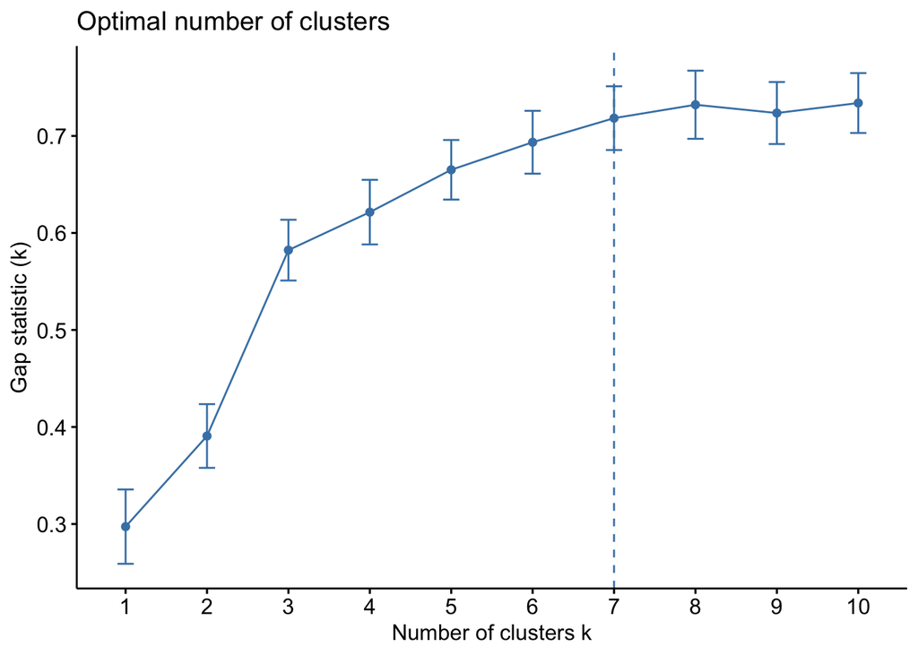

```r
fviz_nbclust(inputData, pam,diss=g.dist,method = "gap_stat",k.max = 10,verbose = F)
```

```r
#Significa 7 clusters
#Pam es la cantidad de clusters a decidir
```

Clusters recomendados para jerarquización:

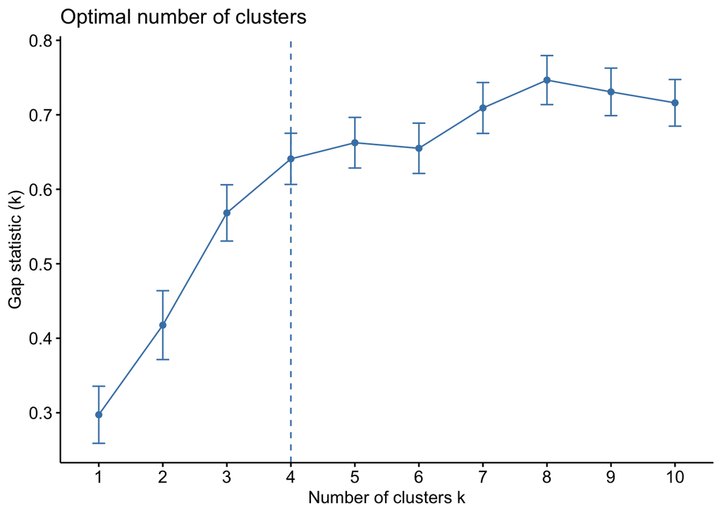

```r
fviz_nbclust(inputData, hcut,diss=g.dist,method = "gap_stat",k.max = 10,verbose = F)
```

Clusterizemos:

```r
res.pam = pam(g.dist,7,cluster.only = F)
res.agnes = hcut(g.dist, k = 4,hc_func='agnes',hc_method = "ward.D") #se emplea el método Ward
res.diana = hcut(g.dist, k = 4,hc_func='diana')
```

Evaluación gráfica

Se van a evaluar los gráficos para cada uno.

```
##   cluster size ave.sil.width
## 1       1   27          0.44
## 2       2   11          0.45
## 3       3   18          0.50
## 4       4   22          0.44
## 5       5    7          0.70
## 6       6   10          0.37
## 7       7   10          0.57
```

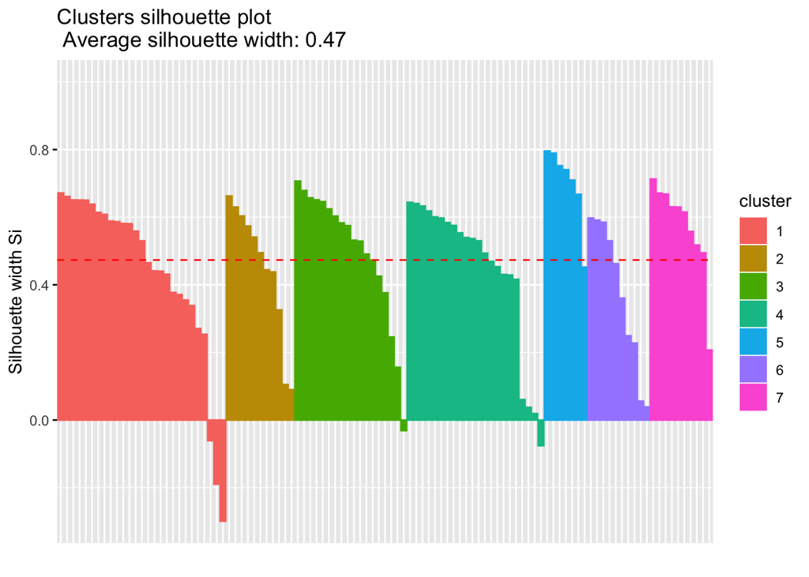

```r
#Evaluación gráfica para pam:
fviz_silhouette(res.pam)
```

```
##   cluster size ave.sil.width
## 1       1   39          0.44
## 2       2   28          0.63
## 3       3   16          0.63
## 4       4   22          0.42
```

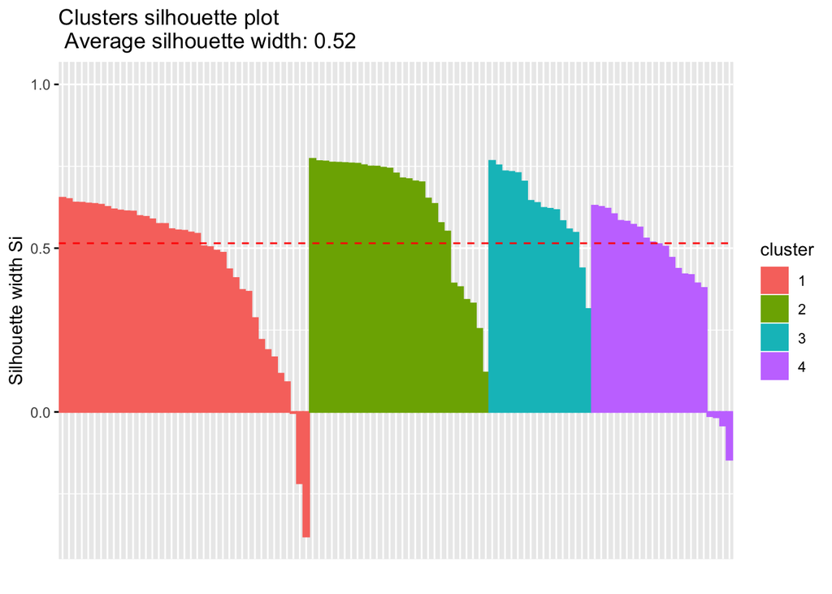

```r
#Evaluación gráfica para agnes:
fviz_silhouette(res.agnes)
```

```
##   cluster size ave.sil.width
## 1       1   48          0.53
## 2       2   17          0.53
## 3       3   29          0.61
## 4       4   11          0.57
```

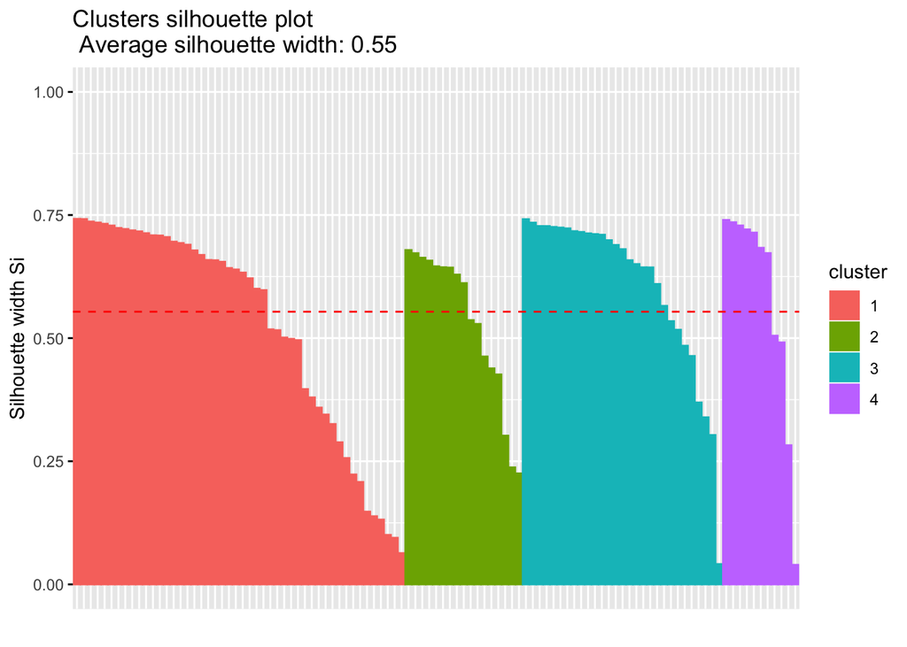

```r
#Evaluación gráfica para diana:
fviz_silhouette(res.diana)
```

Se asume que el gráfico que tiene menos siluetas negativas es el preferible a los demás. El recomendado es diana, por tener mayor average silhoutte width

```r
res.diana <- hcut(g.dist, k = 4,hc_func='diana')
deturb$clustDIV=res.diana$cluster
```

```r
# guardando resultado anterior en objeto "agg":
agg=aggregate(as.matrix(cbind(deturb[,c(18:21)]))~ clustDIV,
              data=deturb, # luego las funciones que deseas
              FUN=plyr::each(MD = median, Media = mean))

# convertir en data frame, y
tablaResumen=t(as.data.frame(agg))
tablaResumen
```

```
##                            [,1]       [,2]      [,3]       [,4]
## clustDIV              1.0000000  2.0000000 3.0000000  4.0000000
## bienestar.MD          0.2979189 -1.7690178 1.0230745 -0.8723167
## bienestar.Media       0.2519109 -1.7774977 0.9916150 -0.9664633
## urbanizacion.MD       0.2361854 -1.7355597 1.0697334 -1.0054501
## urbanizacion.Media    0.2063730 -1.7640414 1.0624863 -0.9753913
## educacion.MD          0.3169522 -1.6028232 0.9335662 -0.9130404
## educacion.Media       0.2890780 -1.7717375 0.9383142 -0.9970289
## desarrolloecon.MD    -0.2543900 -0.9952501 1.1341716 -0.8713099
## desarrolloecon.Media -0.2227564 -0.9693650 1.2501389 -0.8256832
```

El cluster 3 es el mejor. El orden de mejor a peor es de 3, 1, 4, 2

Gráficos

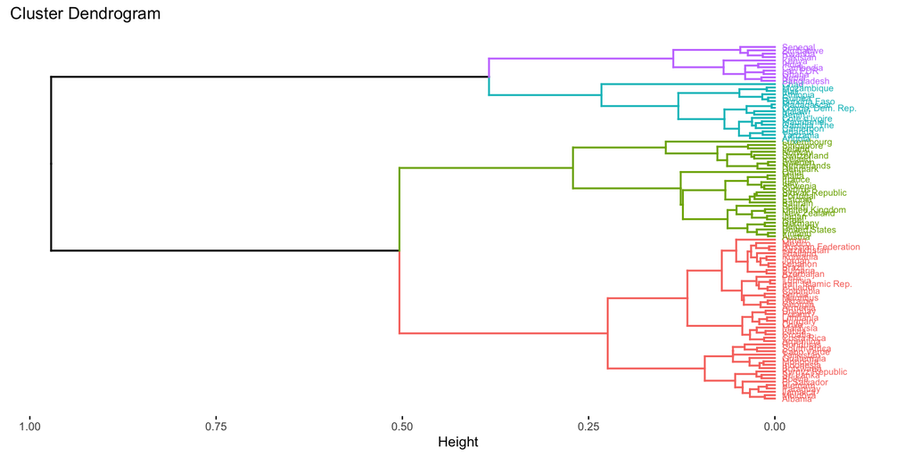

```r
library(ggrepel)

fviz_dend(res.diana, cex = 0.5,horiz = T)
```

Mapa de los casos

```r
library(sp)
library(geojsonio)
library(rgdal)
```

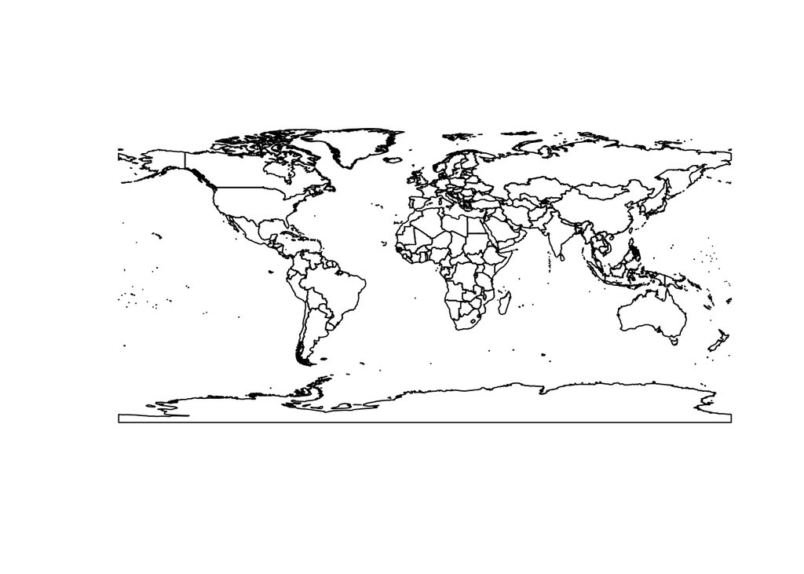

```r
fromGit="https://github.com/adrianoshimante1998/PC4viernes/raw/master/UIA_World_Countries_Boundaries.geojson"

mapaMundo <- rgdal::readOGR(fromGit,stringsAsFactors = FALSE)
plot(mapaMundo)
```

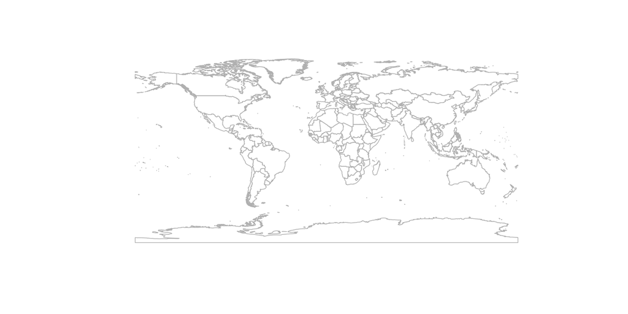

```r
plot(mapaMundo, border='grey')
```

```r
head(mapaMundo@data)
```

```
##   FID          Country ISO     COUNTRYAFF AFF_ISO
## 0   1 Falkland Islands  FK United Kingdom      FK
## 1   2    French Guiana  GF         France      FR
## 2   3           Guyana  GY         Guyana      GY
## 3   4           Cyprus  CY         Cyprus      CY
## 4   5         Pitcairn  PN United Kingdom      PN
## 5   6    South Georgia  GS United Kingdom      GS
```

```r
sort(mapaMundo@data$COUNTRYAFF)
```

```
##   [1] "Afghanistan"
##   [2] "Albania"
##   [3] "Algeria"
##   [4] "Andorra"
##   [5] "Angola"
##   [6] "Antarctica"
##   [7] "Antigua and Barbuda"
##   [8] "Argentina"
##   [9] "Armenia"
##  [10] "Aruba"
##  [11] "Australia"
##  [12] "Australia"
##  [13] "Australia"
##  [14] "Australia"
##  [15] "Australia"
```

[output cut: 239 more lines]

Calculando posiciones

```r
teste=merge(mapaMundo,deturb,by.x='COUNTRYAFF',by.y='CountryName', all.x=T,all.y=T)
```

```r
teste$COUNTRYAFF
```

```
##   [1] "United Kingdom"
##   [2] "France"
##   [3] "Guyana"
##   [4] "Cyprus"
##   [5] "United Kingdom"
##   [6] "United Kingdom"
##   [7] "United Kingdom"
##   [8] "Egypt"
##   [9] "Suriname"
##  [10] "Georgia"
##  [11] "Greece"
##  [12] "Trinidad and Tobago"
##  [13] "Lebanon"
##  [14] "Syria"
##  [15] "Venezuela"
```

[output cut: 239 more lines]

Recuperando nombres para el mapa

```r
deturb[deturb$CountryName=="Congo, Dem. Rep.","CountryName"]="Democratic Republic of the Congo"
deturb[deturb$CountryName=="Cabo Verde","CountryName"]="Cape Verde"
deturb[deturb$CountryName=="Cote d'Ivoire","CountryName"]="Côte d'Ivoire"
deturb[deturb$CountryName=="Gambia, The","CountryName"]="Gambia"
deturb[deturb$CountryName=="Iran, Islamic Rep.","CountryName"]="Iran"
deturb[deturb$CountryName=="Kyrgyz Republic","CountryName"]="Kyrgyzstan"
deturb[deturb$CountryName=="Lao PDR","CountryName"]="Laos"
deturb[deturb$CountryName=="Slovak Republic","CountryName"]="Slovakia"
```

```r
CountryFull=merge(mapaMundo,deturb,by.x='COUNTRYAFF',by.y='CountryName')
```

```r
names(CountryFull)
```

```
##  [1] "COUNTRYAFF"     "FID"            "Country"        "ISO"
##  [5] "AFF_ISO"        "electric"       "empleo"         "export"
##  [9] "internet"       "expevida"       "gdpcapita"      "pbicreci"
## [13] "agua"           "saludcob"       "road"           "litrate"
## [17] "schorate"       "gastoedu"       "urbrate"        "stuteachrat"
## [21] "regimetype"     "bienestar"      "urbanizacion"   "educacion"
## [25] "desarrolloecon" "clustDIV"
```

Se procederá a graficar para ver las posiciones de los países:

```r
aggregate(desarrolloecon~clustDIV,data=CountryFull,FUN = mean)
```

```
##   clustDIV desarrolloecon
## 1        1     -0.2227564
## 2        2     -0.9693650
## 3        3      1.2223459
## 4        4     -0.8256832
```

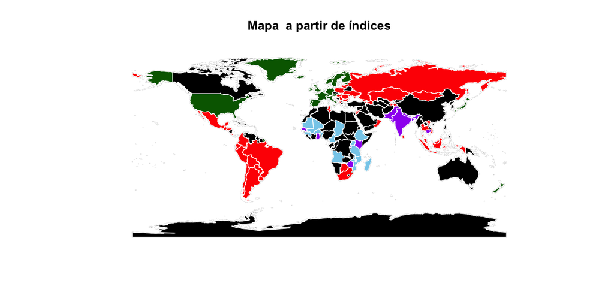

```r
# colores
myColors=c('red','skyblue',"darkgreen","purple")

plot(mapaMundo,col='black', main='Mapa  a partir de índices')
plot(teste,col=myColors[teste$clustDIV], add=T,border="white")
```

Regresion logistica multivariada Se hace esta regresión porque la dependiente es binaria.

```r
str(deturb)
```

```
## 'data.frame':    105 obs. of  22 variables:
##  $ CountryName   : chr  "Albania" "Angola" "Argentina" "Armenia" ...
##  $ electric      : num  100 41.9 100 100 100 ...
##  $ empleo        : num  2.41 4.28 3.83 1.06 4.65 ...
##  $ export        : num  31.6 29 11.2 37.3 53.7 ...
##  $ internet      : num  71.8 14.3 74.3 64.7 87.9 ...
##  $ expevida      : num  78.3 60.4 76.4 74.8 81.6 ...
##  $ gdpcapita     : num  4533 4096 14592 3915 47381 ...
##  $ pbicreci      : num  3.837 -0.147 2.669 7.5 2.551 ...
##  $ agua          : num  91 55.8 99.1 99.9 100 ...
##  $ saludcob      : num  59 40 76 69 79 65 77 48 84 40 ...
##  $ road          : num  3.9 2.2 3.6 3.6 6 5.2 5.2 3.2 4.4 3.2 ...
##  $ litrate       : num  97 71 98 100 98 100 95 60 99 29 ...
##  $ schorate      : num  0.609 0.474 0.783 0.701 0.794 ...
##  $ gastoedu      : num  3.95 3.42 5.57 2.76 5.5 ...
##  $ urbrate       : num  60.3 65.5 91.9 63.1 58.3 ...
##  $ stuteachrat   : num  82.4 50 82.8 84.6 90 ...
##  $ regimetype    : Ord.factor w/ 2 levels "0"<"1": 1 1 2 1 2 1 1 1 2 1 ...
##  $ bienestar     : num  0.186 -1.685 0.631 0.317 0.947 ...
##  $ urbanizacion  : num  0.00741 -1.66532 0.54372 0.2365 1.02985 ...
##  $ educacion     : num  0.202 -1.54 0.668 0.419 0.916 ...
##  $ desarrolloecon: num  -0.3028 -0.7474 0.0206 -0.4209 1.2331 ...
##  $ clustDIV      : int  1 2 1 1 3 1 3 4 3 2 ...
```

```r
# semilla

set.seed(2019)

### primer modelo:
#data como subset
vars1=deturb[,c("regimetype","bienestar","urbanizacion","educacion","desarrolloecon")]

#regresion
rlog1=glm(regimetype~., data=vars1,family = binomial)

#resultado clásico:
summary(rlog1)
```

```
##
## Call:
## glm(formula = regimetype ~ ., family = binomial, data = vars1)
##
## Deviance Residuals:
##     Min       1Q   Median       3Q      Max
## -2.1127  -0.5775   0.2477   0.7334   2.3397
##
## Coefficients:
##                Estimate Std. Error z value Pr(>|z|)
## (Intercept)      0.3752     0.3544   1.058   0.2898
## bienestar       -2.9609     3.0896  -0.958   0.3379
## urbanizacion     5.1316     2.9773   1.724   0.0848 .
## educacion       -0.3921     2.0002  -0.196   0.8446
## desarrolloecon   0.4333     0.8936   0.485   0.6277
## ---
## Signif. codes:  0 '***' 0.001 '**' 0.01 '*' 0.05 '.' 0.1 ' ' 1
##
## (Dispersion parameter for binomial family taken to be 1)
##
##     Null deviance: 143.947  on 104  degrees of freedom
## Residual deviance:  88.606  on 100  degrees of freedom
## AIC: 98.606
##
## Number of Fisher Scoring iterations: 6
```

Veamos ahora el resultado con mejor formato:

```r
library(stargazer)
#resultado
stargazer(rlog1,type="html")
```

|  | *Dependent variable:* |
| --- | --- |
|  | regimetype |
| bienestar | -2.961 |
|  | (3.090) |
| urbanizacion | 5.132* |
|  | (2.977) |
| educacion | -0.392 |
|  | (2.000) |
| desarrolloecon | 0.433 |
|  | (0.894) |
| Constant | 0.375 |
|  | (0.354) |
| Observations | 105 |
| Log Likelihood | -44.303 |
| Akaike Inf. Crit. | 98.606 |
| *Note:* | p<0.1; p<0.05; p<0.01 |

```r
predicted1 <- plogis(predict(rlog1, vars1[,-1]))
```

```r
library(InformationValue)
confusionMatrix(vars1$regimetype, predicted1)
```

```
##    0  1
## 0 30  9
## 1 16 50
```

Debemos averigar si predice razonablemene bien

Dos medidas importantes es saber qué tanto acertamos predecir el evento:

```r
sensitivity(actuals = as.numeric(vars1$regimetype),predictedScores = predicted1)
```

```
## [1] 0.3478261
```

Y qué tanto acertamos predecir la no ocurrencia del evento:

```r
specificity(actuals = as.numeric(vars1$regimetype),predictedScores = predicted1)
```

```
## [1] 0.1525424
```

No parece tener mucha capacidad predictiva

ODDS RATIO

```r
exp(cbind(OR = coef(rlog1), confint(rlog1)))
```

```
##                          OR        2.5 %       97.5 %
## (Intercept)      1.45523113 0.7461260534     3.193819
## bienestar        0.05177332 0.0001038381    21.466473
## urbanizacion   169.29478081 0.5764026096 76768.899397
## educacion        0.67562838 0.0126315228    35.029561
## desarrolloecon   1.54241230 0.3210957949    11.819419
```

Efectos marginales

```r
# interpracion usando marginal effects:
library(margins)
#
(modellog1 = margins(rlog1))
```

```
## Average marginal effects
```

```
## glm(formula = regimetype ~ ., family = binomial, data = vars1)
```

```
##  bienestar urbanizacion educacion desarrolloecon
##    -0.4058       0.7033  -0.05374        0.05939
```

```r
(margins=summary(modellog1))
```

```
##          factor     AME     SE       z      p   lower  upper
##       bienestar -0.4058 0.4191 -0.9683 0.3329 -1.2272 0.4156
##  desarrolloecon  0.0594 0.1225  0.4850 0.6277 -0.1806 0.2994
##       educacion -0.0537 0.2739 -0.1962 0.8445 -0.5907 0.4832
##    urbanizacion  0.7033 0.3901  1.8030 0.0714 -0.0612 1.4679
```